# Drivers of Government Health Spending, 2000-2023: A Global Decomposition

The contributions of economic growth, government expenditure, and budget priority for health

Farizal R. Muharram

20 November 2026

# Overview

## Scope and key questions

Government health expenditure depends on the resources available in the economy, the proportion of those resources spent by government, and the share of public expenditure allocated to health. This analysis quantifies the contribution of each factor to changes in real government health spending per capita between 2000 and 2023.

The historical analysis examines global trends, differences across income groups and World Bank regions, and country-level trajectories. It also identifies cases of sustained growth in health spending and instances in which health lost ground within the government budget. A forward-looking analysis for 2027-2029 then illustrates the potential increase in health expenditure under alternative fiscal and budget-allocation assumptions. Country-level results are provided in the annexes.

The decomposition is descriptive rather than causal. It establishes how the observed change in spending is distributed across three accounting components; it does not establish which policies or economic conditions caused those components to change.

## Analytical framework

Government health spending per capita can be expressed as the product of three components:

**Government health spending per capita = GDP per capita × (government expenditure ÷ GDP) × (government health expenditure ÷ total government expenditure)**

The components represent **economic capacity** (GDP per capita), **the size of government** (general government expenditure as a share of GDP), and **the budget priority assigned to health** (domestic general government health expenditure as a share of general government expenditure).

Expressing the identity in natural logarithms makes the change in spending equal to the sum of changes in the three components. Results are reported as average annual changes in log points, calculated as 100 × ln(end value / start value) divided by the number of years. For small changes, this is approximately equivalent to an annual percentage change. The components sum exactly to the total for an individual country or for an appropriately constructed aggregate. Medians calculated separately across countries do not necessarily sum to the median total.

## Data sources

The analysis combines the following sources:

- **WHO Global Health Expenditure Database (GHED), 2025 update**, retrieved 28 May 2026. The extract contains GDP per capita, current and constant-price health expenditure, general government expenditure relative to GDP, domestic government health expenditure relative to total government expenditure and per capita, and population.
- **World Bank income-group and regional classifications**, using the 2023 classification accompanying the GHED extract. The country reference file covers 195 countries.
- **IMF World Economic Outlook, October 2026**, retrieved 23 October 2026. National-currency GDP in current and constant prices, general government expenditure relative to GDP, GDP in US dollars, and population projections for 2024-2029 are used for the forward-looking scenarios.

Source extracts are stored as RDS files in `data/`. The accompanying `data/README.md` documents their provenance, retrieval dates, and file checksums. The reference output file is used solely for the reproducibility check.

## Reproducing the analysis

This R Markdown report can be rendered in RStudio using **Knit** or with `rmarkdown::render("global-decomposition-deck.Rmd")`. The input files should remain in their accompanying `data/` and `fonts/` directories. Required R packages are `dplyr`, `tidyr`, `scales`, `ggplot2`, `knitr`, `rmarkdown`, `systemfonts`, and `ragg`; missing packages may be installed using `install.packages()`. The bundled Open Sans fonts are registered automatically. Rendering generates a standalone HTML report, with the analytical code available in collapsible sections.

# Analytical implementation

```r
## Setup: packages, the Open Sans font shipped in fonts/, chunk options, colours, the
## plot theme and the way the slides print numbers. Every path in this file is
## relative to the folder that holds it.
# We use dplyr and tidyr for the tables, scales for printing numbers and ggplot2 for the figures
library(dplyr)
library(tidyr)
library(ggplot2)
library(knitr)

# We register the Open Sans files shipped in fonts/, so the figures look the same on any computer
font_styles <- c("Regular", "Bold", "Italic", "BoldItalic", "SemiBold", "SemiBoldItalic")
font_files <- file.path("fonts", paste0("OpenSans-", font_styles, ".ttf"))
names(font_files) <- font_styles
if (!"Open Sans" %in% systemfonts::registry_fonts()$family) {
  registered <- tryCatch(
    {
      systemfonts::register_font(
        "Open Sans",
        plain = font_files[["Regular"]],
        bold = font_files[["Bold"]],
        italic = font_files[["Italic"]],
        bolditalic = font_files[["BoldItalic"]]
      )
      TRUE
    },
    error = function(e) FALSE
  )
  # a computer with Open Sans installed refuses the registration; we then side-load the files, and
  # systemfonts searches side-loaded files first, so the figures still use the files in fonts/
  if (!registered) systemfonts::add_fonts(unname(font_files))
}
knitr::opts_chunk$set(
  dev = "ragg_png", dpi = 150, fig.width = 9, fig.height = 5.2, message = FALSE, warning = FALSE
)
FONT <- "Open Sans"

# World Bank colours used by the deck
WB <- c(
  blue = "#0071bc", navy = "#002244", rust = "#b5452c", grey = "#9aa3ad", grey2 = "#8f99a3",
  light = "#7fc4ea", sky = "#5fb3e4", slate = "#5b6470", tint = "#dcebf6", rosy = "#f2c9bd",
  pale = "#c9d0d6"
)
PART_LABEL <- c(
  econ = "Economy", budget = "Size of government", priority = "Health priority", total = "Total"
)
PART_FILL <- c(
  Economy = "#8f99a3", "Size of government" = "#7fc4ea", "Health priority" = "#0071bc",
  Total = "#002244"
)

# One theme for every figure: Open Sans, explicit black x and y
# axis lines, light major gridlines only
figure_theme <- theme_minimal(base_size = 11, base_family = FONT) +
  theme(
    axis.line = element_line(colour = "black", linewidth = 0.5),
    axis.ticks = element_line(colour = "black", linewidth = 0.4),
    axis.text = element_text(colour = "black"),
    axis.title = element_text(colour = "black"),
    panel.grid.minor = element_blank(),
    panel.grid.major = element_line(colour = "#e6e9ec", linewidth = 0.3),
    plot.title = element_text(face = "bold", colour = WB[["navy"]]),
    plot.subtitle = element_text(colour = "#3a434d"),
    plot.caption = element_text(colour = WB[["slate"]], hjust = 0),
    legend.position = "top",
    legend.justification = "left",
    legend.title = element_blank(),
    strip.text = element_text(face = "bold", hjust = 0)
  )
theme_set(figure_theme)
# we write the numbers and labels on the charts in Open Sans as well
update_geom_defaults("text", list(family = FONT))

# How the slides print numbers. The deck rounds each number once and the slide only prints it, so we
# round and print in one step with the labelling functions of scales.
signed <- scales::label_number(accuracy = 0.1, style_positive = "plus") # +1.2, -0.4, 0.0
one_decimal <- scales::label_comma(accuracy = 0.1) # 1,234.5
share_pct <- scales::label_percent(accuracy = 0.1, scale = 1, big.mark = ",") # 12.3% from per cent
signed_pct <- scales::label_percent(
  accuracy = 0.1, scale = 1, big.mark = ",", style_positive = "plus"
) # +12.3%
whole_pct <- scales::label_percent(accuracy = 1, scale = 1, big.mark = ",") # 1,234%

# The slides print dollars whole from US$100 and with one decimal below. We keep this small function
# because no scales labeller changes its accuracy with the size of the number.
dollars <- function(x, prefix = "US$") {
  whole <- scales::comma(x, accuracy = 1, prefix = prefix)
  with_decimal <- scales::comma(x, accuracy = 0.1, prefix = prefix)
  ifelse(abs(x) >= 100, whole, with_decimal)
}

# knitr::kable() prints one table, and each slide has a few, so this function prints a slide's list
# of tables. We right-align the columns that hold only numbers, as the slides do.
show_tables <- function(tables) {
  for (caption in names(tables)) {
    table <- tables[[caption]]
    align <- rep("l", ncol(table))
    for (j in seq_along(table)[-1]) {
      column <- as.character(table[[j]])
      numbers_only <- grepl("^[-+0-9.,%/ US$]*$", column) | column %in% c("-", "Not available")
      if (all(numbers_only)) align[j] <- "r"
    }
    cat("\n\n")
    print(knitr::kable(table, caption = caption, row.names = FALSE, align = align))
    cat("\n\n")
  }
}

# The bar chart of slides 3, 4, 10 and 11. We keep it as a function because four slides draw it and
# ggplot2 has no single geom for it: one bar per row of `parts`, the three parts stacked (the
# economy nearest zero) and the total as a diamond, with the total printed in a column right of the
# bars. `parts` has the columns econ, budget, priority and total, the bar labels in `label_col` and,
# if `facet` is given, the panel of each bar.
plot_parts <- function(parts, label_col, xlab = "Average annual change, log points", facet = NULL) {
  # we keep the first row at the top of the chart
  bar_labels <- parts[[label_col]]
  parts$row <- factor(bar_labels, levels = rev(unique(bar_labels)))
  parts$panel <- if (is.null(facet)) "" else parts[[facet]]

  # one bar segment per row and part
  part_names <- PART_LABEL[c("econ", "budget", "priority")]
  bars <- parts |>
    select(row, panel, econ, budget, priority) |>
    pivot_longer(c(econ, budget, priority), names_to = "part", values_to = "value") |>
    mutate(part = factor(PART_LABEL[part], levels = part_names))

  # we print the totals just right of the bar that reaches furthest
  reach_right <- pmax(parts$econ, 0) + pmax(parts$budget, 0) + pmax(parts$priority, 0)
  reach_left <- pmin(parts$econ, 0) + pmin(parts$budget, 0) + pmin(parts$priority, 0)
  chart_width <- max(reach_right, parts$total, 0) - min(reach_left, parts$total, 0)
  parts$label_x <- max(reach_right, parts$total) + 0.06 * chart_width

  chart <- ggplot(bars, aes(x = value, y = row)) +
    geom_col(aes(fill = part), width = 0.7, position = position_stack(reverse = TRUE)) +
    geom_vline(xintercept = 0, colour = "black", linewidth = 0.4) +
    geom_point(
      data = parts, aes(x = total, y = row),
      shape = 23, size = 2.8, fill = WB[["navy"]], colour = "white"
    ) +
    geom_text(
      data = parts, aes(x = label_x, y = row, label = signed(total)),
      hjust = 0, size = 3.2, colour = WB[["navy"]], fontface = "bold"
    ) +
    scale_x_continuous(expand = expansion(mult = c(0.04, 0.12))) +
    scale_fill_manual(values = PART_FILL) +
    labs(
      x = xlab, y = NULL,
      caption = "Bars: the three parts. Diamond and right-hand number: the total."
    )
  if (!is.null(facet)) {
    chart <- chart + facet_grid(panel ~ ., scales = "free_y", space = "free_y")
  }
  chart
}
```

```r
## Read the inputs: four RDS files converted one to one from the report's
## CSV inputs (same columns, same types).
# WHO GHED 2025 update, one row per country, year and series
ghed_long <- readRDS("data/ghed_extract.rds")
# the 195 countries with their World Bank income group and region
countries <- readRDS("data/countries.rds")
# labels and member counts of the income groups and regions
group_labels <- readRDS("data/group_labels.rds")
# IMF WEO October 2026, 2024 to 2029, one row per country, year and series (Section 2 only)
weo_long <- readRDS("data/weo_currency_extract.rds")
stopifnot(nrow(ghed_long) > 0, nrow(countries) == 195)
data.frame(
  file = c("ghed_extract", "countries", "group_labels", "weo_currency_extract"),
  rows = c(nrow(ghed_long), nrow(countries), nrow(group_labels), nrow(weo_long)),
  columns = c(ncol(ghed_long), ncol(countries), ncol(group_labels), ncol(weo_long))
)
```

```
##                   file  rows columns
## 1         ghed_extract 32209      11
## 2            countries   195       5
## 3         group_labels    12       4
## 4 weo_currency_extract  5564       4
```

# Data preparation and quality criteria

The analytical dataset is constructed from country-year observations in GHED. The following decisions ensure consistent comparisons across countries and periods.

- **Observation periods.** Historical comparisons use 2000-2010, 2010-2019, and 2019-2023. For country profiles, the most recent eligible window extends up to ten years and ends in the latest year with complete component data, including 2024 where available. Windows shorter than five years are excluded. Seven countries have complete data through 2024 and therefore use 2014-2024.
- **Comparable endpoints.** Fixed-period analyses require observations for both specified endpoints; adjacent years are not substituted. This avoids interpreting changes in data availability as changes in spending.
- **Quality flags.** Four non-exclusive criteria identify observations requiring caution: **B (break)** indicates a government-expenditure or health-expenditure share that at least doubles or halves between consecutive years; **S (shock)** indicates a one-year change in real GDP per capita above +25% or below −20%; **E (unusual endpoint)** indicates an initial or final share outside one-half to twice the window median; and **L (extreme level)** indicates government expenditure exceeding 100% of GDP or government health expenditure below US$1 per capita at an endpoint. Flagged observations remain in descriptive summaries but are separated from unflagged illustrative cases.
- **Constant-price measures.** The ratio of GHED current-price to constant-2023-price health expenditure per capita provides a country-year conversion factor that is also applied to GDP per capita. Expenditure shares are dimensionless. Applying a consistent factor preserves the accounting identity, although exchange-rate and price movements still affect cross-country interpretation.
- **Completeness and positivity.** A country-year is included only when GDP per capita, both expenditure shares, and the price-conversion factor are available and strictly positive, as required for logarithmic decomposition.

```r
## Cleaning: from the long GHED extract to one row per country and year with the
## identity's three parts in real terms.
# ---- 0. Decisions that shape the numbers ---------------------------------------------------------
YEAR_MIN <- 2000 # first year of the study period
YEAR_MAX <- 2023 # last year of the study period (fixed periods, trends)
WINDOW_MAX_YEAR <- 2024 # latest year a window may end in: GHED's last, as on the country slide
WINDOW <- 10 # window of ten years ending at the latest year with all parts
MIN_SPAN <- 5 # shortest window accepted
PERIODS <- tibble(
  period = c("P1", "P2", "P3"),
  y0 = c(2000, 2010, 2019),
  y1 = c(2010, 2019, 2023)
)
FLAG_RATIO_STEP <- log(2) # B, break: a budget share or the health share doubles or halves in a year
FLAG_GDP_STEP <- log(1.25) # S, shock: real GDP per person up more than 25% or down more than 20%
FLAG_END <- log(2) # E, extreme end: a share at an end over twice or under half its window median
FLAG_PIE_MAX <- 100 # L, level: government spending above 100% of GDP at either end, or
FLAG_GHE_MIN <- 1 #    government health spending below US$1 per person (2023 US$) at either end

# ---- 1. One row per country and year, one column per series --------------------------------------
panel <- ghed_long |>
  filter(!is.na(value)) |>
  select(iso3, year, indicator, value) |>
  pivot_wider(names_from = indicator, values_from = value) |>
  arrange(iso3, year)

# ---- 2. Real terms: GHED's constant-2023-US$ conversion factor k, applied to GDP per person ------
# k is the ratio of GHED's two health spending series where both are published and above zero.
# Every part enters as a logarithm, so we keep a country-year only when k, GDP per person and both
# shares are published and above zero.
panel <- panel |>
  mutate(
    k = if_else(che_usd2023_pc > 0 & che_pc_usd > 0, che_usd2023_pc / che_pc_usd, NA),
    ok = !is.na(k) & !is.na(gdp_pc_usd) & gdp_pc_usd > 0 & !is.na(gge_gdp) & gge_gdp > 0 &
      !is.na(gghed_gge) & gghed_gge > 0,
    gdp_real = if_else(ok, gdp_pc_usd * k, NA), # real GDP per person, 2023 US$
    pie = if_else(ok, gge_gdp, NA), # government spending, % of GDP
    slice = if_else(ok, gghed_gge, NA), # health, % of government spending
    ghe_real = gdp_real * pie / 100 * slice / 100, # government health spending per person
    # we also rebuild spending in current US$ and compare it with GHED's own published series
    ghe_cur = if_else(ok, gdp_pc_usd * pie / 100 * slice / 100, NA),
    ident_gap_pct = 100 * (ghe_cur / gghed_pc_usd - 1)
  )

# ---- 3. Country attributes ----------------------------------------------------------------------
panel <- panel |>
  left_join(select(countries, iso3, name, income_group, wb_region), by = "iso3") |>
  arrange(iso3, year)
largest_gap <- max(abs(panel$ident_gap_pct), na.rm = TRUE)
data.frame(
  `country-years` = nrow(panel),
  `with all parts` = sum(panel$ok),
  countries = length(unique(panel$iso3)),
  `largest gap to GHED's own per person series, %` = signif(largest_gap, 2),
  check.names = FALSE
)
```

```
##   country-years with all parts countries
## 1          4612           4571       195
##   largest gap to GHED's own per person series, %
## 1                                        9.9e-06
```

The reconstructed expenditure identity is checked against GHED’s published government health expenditure per capita in current US dollars. Differences are negligible and reflect rounding in the source series rather than a substantive inconsistency in the accounting relationship.

# Decomposition methodology

## Country-level trends and classification

For each eligible country, the change in real government health expenditure per capita is decomposed into the contributions of economic capacity, government size, and health’s share of the budget. The latest available window is also divided at its midpoint to examine whether spending increased during both halves. The same decomposition is calculated independently for the three fixed historical periods.

Countries are classified as **declining** when real government health expenditure per capita fell. Otherwise, they are classified as **economy-led**, **government-size-led**, or **health-priority-led**, according to the largest contribution to the observed increase. A separate indicator identifies countries where economic capacity increased but the budget share allocated to health declined. These categories describe accounting patterns, not underlying causes.

Two additional classifications support interpretation. **Sustained-growth examples** are countries in the top quartile of spending growth within their income group, with at least half of total growth attributable jointly to government size and health priority, positive growth in both halves of the observation window, and no quality flag. **Cases warranting closer examination** are countries where real government health spending per capita declined or where a reduction in health priority offset at least half of the positive contribution from economic growth. Neither classification should be interpreted as an assessment of policy performance.

```r
## Country level: each country's latest window, its decomposition, halves, flags, pattern, example
## and warning status; then the same decomposition for the three fixed periods.
# we work only with the country-years that have all three parts
years_with_parts <- panel |>
  filter(ok) |>
  arrange(iso3, year)

# labels of the income groups and regions, in the order the deck uses
group_label <- setNames(group_labels$label, paste(group_labels$grouping, group_labels$key))
inc_levels <- c("low", "lower_middle", "upper_middle", "high")
reg_levels <- c(
  "East Asia & Pacific", "Europe & Central Asia", "Latin America & Caribbean",
  "Middle East, North Africa, Afghanistan & Pakistan", "North America", "South Asia",
  "Sub-Saharan Africa", "not_classified"
)

# Every window a country could have: an end year up to 2024 and a start year with all parts, at most
# ten and at least five years earlier
start_years <- select(years_with_parts, iso3, y0 = year)
possible_windows <- years_with_parts |>
  filter(year <= WINDOW_MAX_YEAR) |>
  select(iso3, y1 = year) |>
  inner_join(start_years, by = "iso3", relationship = "many-to-many") |>
  filter(y0 >= YEAR_MIN, y0 >= y1 - WINDOW, y0 <= y1 - MIN_SPAN)

# we take the latest end year, and for it the earliest start year
window_years <- possible_windows |>
  group_by(iso3) |>
  filter(y1 == max(y1)) |>
  summarise(y0 = min(y0), y1 = first(y1))

# the four series at the start, the middle and the end of a window, ready to join on
start_values <- years_with_parts |>
  select(iso3, y0 = year, ghe0 = ghe_real, gdp0 = gdp_real, pie0 = pie, slice0 = slice)
end_values <- years_with_parts |>
  select(iso3, y1 = year, ghe1 = ghe_real, gdp1 = gdp_real, pie1 = pie, slice1 = slice)
middle_values <- years_with_parts |>
  select(iso3, mid = year, ghe_mid = ghe_real)

# The change over the window split into the three parts, in log points a year; the parts add up to
# the total. We also split the window at its middle year (rounded half up, as the slide rounds it).
windows <- window_years |>
  left_join(start_values, by = c("iso3", "y0")) |>
  left_join(end_values, by = c("iso3", "y1")) |>
  mutate(
    span = y1 - y0,
    mid = y0 + floor(span / 2 + 0.5),
    econ = 100 * log(gdp1 / gdp0) / span,
    budget = 100 * log(pie1 / pie0) / span,
    priority = 100 * log(slice1 / slice0) / span,
    total = 100 * log(ghe1 / ghe0) / span
  ) |>
  left_join(middle_values, by = c("iso3", "mid")) |>
  mutate(
    half1 = 100 * log(ghe_mid / ghe0) / (mid - y0),
    half2 = 100 * log(ghe1 / ghe_mid) / (y1 - mid)
  )

# The four data flags inside each window. The year-on-year rules B and S compare consecutive years
# only; the rules E and L look at the first and the last year.
window_flags <- years_with_parts |>
  inner_join(window_years, by = "iso3") |>
  filter(year >= y0, year <= y1) |>
  group_by(iso3) |>
  arrange(year, .by_group = TRUE) |>
  mutate(
    log_pie = log(pie),
    log_slice = log(slice),
    log_gdp = log(gdp_real),
    consecutive = year - lag(year) == 1,
    pie_step = abs(log_pie - lag(log_pie)),
    slice_step = abs(log_slice - lag(log_slice)),
    gdp_step = abs(log_gdp - lag(log_gdp)),
    big_step = pie_step > FLAG_RATIO_STEP | slice_step > FLAG_RATIO_STEP,
    is_end = year == y0 | year == y1,
    pie_median = median(pie),
    slice_median = median(slice),
    pie_off_median = abs(log(pie / pie_median)),
    slice_off_median = abs(log(slice / slice_median))
  ) |>
  summarise(
    flag_B = any(consecutive & big_step, na.rm = TRUE),
    flag_S = any(consecutive & gdp_step > FLAG_GDP_STEP, na.rm = TRUE),
    flag_E = any(is_end & (pie_off_median > FLAG_END | slice_off_median > FLAG_END)),
    flag_L = any(is_end & (pie > FLAG_PIE_MAX | ghe_real < FLAG_GHE_MIN)),
    n_years_in_window = n()
  )

# One row per country, with or without a window. The pattern is plain arithmetic: declining if the
# total fell, otherwise named after the largest of the three parts (the first one on a tie).
country_windows <- countries |>
  select(iso3, name, income_group, wb_region) |>
  left_join(windows, by = "iso3") |>
  left_join(window_flags, by = "iso3") |>
  arrange(iso3) |>
  mutate(
    has_window = !is.na(total),
    closure = econ + budget + priority - total, # the identity check, about zero
    flag_letters = paste0(
      if_else(flag_B, "B ", ""),
      if_else(flag_S, "S ", ""),
      if_else(flag_E, "E ", ""),
      if_else(flag_L, "L", "")
    ),
    flag = if_else(has_window, trimws(flag_letters), NA),
    flagged = has_window & nzchar(flag),
    note_2024 = has_window & y1 == 2024,
    note_short = has_window & span < WINDOW,
    pattern = case_when(
      total < 0 ~ "Declining",
      econ >= budget & econ >= priority ~ "Economy-led",
      budget >= priority ~ "Budget-led",
      budget < priority ~ "Priority-led"
    ),
    lost_priority = has_window & econ > 0 & priority < 0
  ) |>
  select(-flag_letters)

# Instructive examples and warning cases are rules applied within each income group
country_windows <- country_windows |>
  group_by(income_group) |>
  mutate(top_quarter = has_window & total >= quantile(total[has_window], 0.75, names = FALSE)) |>
  ungroup() |>
  mutate(
    example = has_window & top_quarter & total > 0 & (budget + priority) >= 0.5 * total &
      !is.na(half1) & half1 > 0 & half2 > 0 & !flagged,
    warning_rule = has_window & (total < 0 | (econ > 0 & priority <= -0.5 * econ)),
    warning = warning_rule & !flagged,
    inc_lab = unname(group_label[paste("income", income_group)]),
    reg_lab = unname(group_label[paste("wb_region", wb_region)])
  )

# The fixed periods: one decomposition per country and period, for every country with all parts at
# both ends of the period (we use the same pattern rule as above)
country_periods <- years_with_parts |>
  select(
    iso3, income_group, wb_region,
    y0 = year, gdp0 = gdp_real, pie0 = pie, slice0 = slice, ghe0 = ghe_real
  ) |>
  inner_join(PERIODS, by = "y0") |>
  inner_join(end_values, by = c("iso3", "y1")) |>
  arrange(period, iso3) |>
  mutate(
    econ = 100 * log(gdp1 / gdp0) / (y1 - y0),
    budget = 100 * log(pie1 / pie0) / (y1 - y0),
    priority = 100 * log(slice1 / slice0) / (y1 - y0),
    total = 100 * log(ghe1 / ghe0) / (y1 - y0),
    pattern = case_when(
      total < 0 ~ "Declining",
      econ >= budget & econ >= priority ~ "Economy-led",
      budget >= priority ~ "Budget-led",
      budget < priority ~ "Priority-led"
    ),
    lost_priority = econ > 0 & priority < 0
  ) |>
  select(
    period, y0, y1, iso3, income_group, wb_region, econ, budget, priority, total, pattern,
    lost_priority
  )
data.frame(
  countries = nrow(country_windows),
  `with a window` = sum(country_windows$has_window),
  `largest closure error` = max(abs(country_windows$closure), na.rm = TRUE),
  flagged = sum(country_windows$flagged),
  examples = sum(country_windows$example),
  `warning cases without a flag` = sum(country_windows$warning),
  check.names = FALSE
)
```

```
##   countries with a window largest closure error flagged examples
## 1       195           194          6.217249e-15      35       20
##   warning cases without a flag
## 1                           40
```

## Interpreting country medians and population-weighted aggregates

Two complementary measures are reported for income groups and regions. The **median country** represents the central country-level experience, with the median calculated separately for each component. Consequently, the median component contributions may not sum to the median total. The **aggregate** combines GDP, government expenditure, and government health expenditure across countries before calculating per-capita values and expenditure shares. Its three contributions sum exactly, but the result is influenced by the largest economies and populations.

For the latest-window comparison, country medians use each country’s eligible window, whereas aggregates use the common endpoints of 2013 and 2023. Results for groups with fewer than eight countries are presented descriptively and are not emphasised in comparisons.

The historical series include annual country medians and interquartile ranges, a balanced panel of countries with complete observations throughout 2000-2023, and the trajectory of health’s budget share before and after the COVID-19 pandemic. These complementary measures distinguish changes in a typical country from changes in total spending across countries.

```r
## Group level: medians and aggregates by period and latest window, sensitivity without
## flagged countries, trends, the pandemic trajectories, pattern counts and each country's
## share of its income group's change.

# the thirteen groups (world, four income groups, eight regions) and the countries in each
groups <- bind_rows(
  tibble(grouping = "world", key = "world", label = "World", N = nrow(countries)),
  select(group_labels, grouping, key, label, N = n_members)
) |>
  arrange(match(key, c("world", inc_levels, reg_levels)))
membership <- bind_rows(
  transmute(countries, grouping = "world", key = "world", iso3),
  transmute(countries, grouping = "income", key = income_group, iso3),
  transmute(countries, grouping = "wb_region", key = wb_region, iso3)
)
flagged_countries <- country_windows$iso3[country_windows$flagged]

# The median country: each part's median taken separately over the group's countries, for the three
# periods and the latest window ("W"), with all countries and without the flagged ones
country_rates <- bind_rows(
  select(country_periods, period, iso3, econ, budget, priority, total),
  country_windows |>
    filter(has_window) |>
    transmute(period = "W", iso3, econ, budget, priority, total)
)
rates_for_medians <- bind_rows(
  mutate(country_rates, sample = "all"),
  country_rates |>
    filter(period == "W", !iso3 %in% flagged_countries) |>
    mutate(sample = "without flagged")
)
group_medians <- rates_for_medians |>
  inner_join(membership, by = "iso3", relationship = "many-to-many") |>
  group_by(sample, grouping, key, period) |>
  summarise(
    med_econ = median(econ),
    med_budget = median(budget),
    med_priority = median(priority),
    med_total = median(total),
    n_med = n(),
    .groups = "drop"
  )

# A group as a whole: real GDP, government spending and government health spending summed over
# the members, then divided by the summed population (and by each other for the two shares),
# so the identity holds for the sums. A whole needs the same two years for every member, so
# the latest window uses 2013 and 2023.
whole_years <- tibble(
  period = c("P1", "P2", "P3", "W"),
  y0 = c(2000, 2010, 2019, 2013),
  y1 = c(2010, 2019, 2023, 2023)
)
money <- years_with_parts |>
  filter(!is.na(pop)) |>
  mutate(gdp = gdp_real * pop, gge = gdp * pie / 100, ghe = gge * slice / 100) |>
  select(iso3, year, pop, gdp, gge, ghe)
money_start <- rename(money, y0 = year, pop0 = pop, gdp0 = gdp, gge0 = gge, ghe0 = ghe)
money_end <- rename(money, y1 = year, pop1 = pop, gdp1 = gdp, gge1 = gge, ghe1 = ghe)

# every member with all parts and population at both ends of each period
members_both_ends <- membership |>
  cross_join(whole_years) |>
  inner_join(money_start, by = c("iso3", "y0")) |>
  inner_join(money_end, by = c("iso3", "y1")) |>
  arrange(iso3)
members_for_wholes <- bind_rows(
  mutate(members_both_ends, sample = "all"),
  members_both_ends |>
    filter(period == "W", !iso3 %in% flagged_countries) |>
    mutate(sample = "without flagged")
)
group_wholes <- members_for_wholes |>
  group_by(sample, grouping, key, period, y0, y1) |>
  summarise(
    gdp_start = sum(gdp0) / sum(pop0),
    pie_start = 100 * sum(gge0) / sum(gdp0),
    slice_start = 100 * sum(ghe0) / sum(gge0),
    ghe_start = sum(ghe0) / sum(pop0),
    gdp_end = sum(gdp1) / sum(pop1),
    pie_end = 100 * sum(gge1) / sum(gdp1),
    slice_end = 100 * sum(ghe1) / sum(gge1),
    ghe_end = sum(ghe1) / sum(pop1),
    n_agg = n(),
    .groups = "drop"
  ) |>
  mutate(
    agg_econ = 100 * log(gdp_end / gdp_start) / (y1 - y0),
    agg_budget = 100 * log(pie_end / pie_start) / (y1 - y0),
    agg_priority = 100 * log(slice_end / slice_start) / (y1 - y0),
    agg_total = 100 * log(ghe_end / ghe_start) / (y1 - y0)
  ) |>
  select(sample, grouping, key, period, agg_econ, agg_budget, agg_priority, agg_total, n_agg)

# Each group in each fixed period and over the latest window, with every country
medians_all <- group_medians |>
  filter(sample == "all") |>
  select(-sample)
wholes_all <- group_wholes |>
  filter(sample == "all") |>
  select(-sample)
group_summary <- groups |>
  cross_join(whole_years) |>
  left_join(medians_all, by = c("grouping", "key", "period")) |>
  left_join(wholes_all, by = c("grouping", "key", "period")) |>
  mutate(
    years = if_else(
      period == "W", "Latest window (aggregate 2013 to 2023)", paste0(y0, " to ", y1)
    ),
    n_med = coalesce(n_med, 0L),
    n_agg = coalesce(n_agg, 0L),
    status = if_else(n_med >= 8, "Carries a comparison",
      "Fewer than 8 countries: described, not compared"
    ),
    agg_closure = agg_econ + agg_budget + agg_priority - agg_total
  ) |>
  select(
    grouping, key, label, N, period, years, med_econ, med_budget, med_priority, med_total,
    n_med, agg_econ, agg_budget, agg_priority, agg_total, n_agg, status, agg_closure
  )

# Sensitivity: the latest-window medians and the 2013-2023 wholes without the flagged countries
medians_without_flagged <- groups |>
  left_join(
    filter(group_medians, sample == "without flagged"),
    by = c("grouping", "key")
  ) |>
  mutate(n_med = coalesce(n_med, 0L)) |>
  select(grouping, key, label, med_econ, med_budget, med_priority, med_total, n_med)
wholes_without_flagged <- groups |>
  left_join(
    filter(group_wholes, sample == "without flagged"),
    by = c("grouping", "key")
  ) |>
  mutate(n_agg = coalesce(n_agg, 0L)) |>
  select(grouping, key, label, agg_econ, agg_budget, agg_priority, agg_total, n_agg)

# Each country's government health spending in US$ million (2023 prices) in 2013 and 2023, and its
# share of its income group's change (population is in thousands)
spending_2013 <- years_with_parts |>
  filter(year == 2013, !is.na(pop)) |>
  transmute(iso3, ghe0_musd = ghe_real * pop / 1000, pop0_m = pop / 1000)
spending_2023 <- years_with_parts |>
  filter(year == 2023, !is.na(pop)) |>
  transmute(iso3, ghe1_musd = ghe_real * pop / 1000, pop1_m = pop / 1000)
contributions <- countries |>
  select(income_group, iso3, name) |>
  inner_join(spending_2013, by = "iso3") |>
  inner_join(spending_2023, by = "iso3") |>
  arrange(match(income_group, inc_levels), iso3) |>
  group_by(income_group) |>
  mutate(
    share_of_group_change_pct = 100 * (ghe1_musd - ghe0_musd) / sum(ghe1_musd - ghe0_musd),
    change_pct_of_group_2013 = 100 * (ghe1_musd - ghe0_musd) / sum(ghe0_musd)
  ) |>
  ungroup()

# Trends 2000 to 2023: medians and quartiles over all countries with data each year, and the
# balanced panel (all parts in every year) as a whole and as medians
study_years <- years_with_parts |>
  filter(year >= YEAR_MIN, year <= YEAR_MAX)
years_per_country <- count(study_years, iso3)
balanced <- years_per_country$iso3[years_per_country$n == length(YEAR_MIN:YEAR_MAX)]
balanced <- intersect(balanced, years_with_parts$iso3[!is.na(years_with_parts$pop)])
trend_members <- study_years |>
  inner_join(membership, by = "iso3", relationship = "many-to-many") |>
  arrange(iso3)
trend_all_countries <- trend_members |>
  group_by(grouping, key, year) |>
  summarise(
    med_ghe = median(ghe_real),
    p25_ghe = quantile(ghe_real, 0.25, names = FALSE),
    p75_ghe = quantile(ghe_real, 0.75, names = FALSE),
    n = n(),
    med_slice = median(slice),
    p25_slice = quantile(slice, 0.25, names = FALSE),
    p75_slice = quantile(slice, 0.75, names = FALSE),
    med_pie = median(pie),
    med_gdp = median(gdp_real),
    .groups = "drop"
  )
trend_balanced <- trend_members |>
  filter(iso3 %in% balanced, !is.na(pop)) |>
  mutate(gdp = gdp_real * pop, gge = gdp * pie / 100, ghe = gge * slice / 100) |>
  group_by(grouping, key, year) |>
  summarise(
    agg_ghe = sum(ghe) / sum(pop),
    agg_slice = 100 * sum(ghe) / sum(gge),
    agg_pie = 100 * sum(gge) / sum(gdp),
    agg_gdp = sum(gdp) / sum(pop),
    n_bal = n(),
    med_ghe_bal = median(ghe_real),
    p25_ghe_bal = quantile(ghe_real, 0.25, names = FALSE),
    p75_ghe_bal = quantile(ghe_real, 0.75, names = FALSE),
    .groups = "drop"
  )
trends <- groups |>
  select(grouping, key, label) |>
  cross_join(tibble(year = YEAR_MIN:YEAR_MAX)) |>
  left_join(trend_all_countries, by = c("grouping", "key", "year")) |>
  left_join(trend_balanced, by = c("grouping", "key", "year")) |>
  mutate(n = coalesce(n, 0L), n_bal = coalesce(n_bal, 0L))

# Health's share around the pandemic: 2019, 2021 and 2023 for the same countries, and five paths
share_2021 <- years_with_parts |>
  filter(year == 2021) |>
  select(iso3, s21 = slice)
share_2023 <- years_with_parts |>
  filter(year == 2023) |>
  select(iso3, s23 = slice)
pandemic_countries <- years_with_parts |>
  filter(year == 2019) |>
  select(iso3, s19 = slice, income_group, wb_region) |>
  left_join(share_2021, by = "iso3") |>
  left_join(share_2023, by = "iso3") |>
  filter(!is.na(s21), !is.na(s23)) |>
  mutate(
    d1921 = s21 - s19,
    d2123 = s23 - s21,
    d1923 = s23 - s19,
    state = case_when(
      d1921 > 0 & d1923 > 0 & s23 >= s21 ~ "Rose and kept rising",
      d1921 > 0 & d1923 > 0 ~ "Rose, partly reversed, still above 2019",
      d1921 > 0 ~ "Rose, then fell back to or below 2019",
      d1923 > 0 ~ "Did not rise by 2021, above 2019 by 2023",
      .default = "Did not rise, at or below 2019 in 2023"
    )
  )
pandemic_by_group <- pandemic_countries |>
  inner_join(membership, by = "iso3", relationship = "many-to-many") |>
  group_by(grouping, key) |>
  summarise(
    n = n(),
    med19 = median(s19),
    med21 = median(s21),
    med23 = median(s23),
    med_d1921 = median(d1921),
    med_d2123 = median(d2123),
    med_d1923 = median(d1923),
    rose = sum(d1921 > 0),
    above19_in23 = sum(d1923 > 0),
    kept = sum(d1921 > 0 & d1923 > 0),
    .groups = "drop"
  )
pandemic_groups <- groups |>
  select(grouping, key, label) |>
  left_join(pandemic_by_group, by = c("grouping", "key")) |>
  # a group with no country in the panel gets zero counts; its medians stay empty
  mutate(across(
    c(n, rose, above19_in23, kept),
    \(count) coalesce(count, 0L)
  ))

# Pattern counts by income group and by region (latest window), and for income groups by period
pattern_rows <- bind_rows(
  country_windows |>
    filter(has_window) |>
    transmute(period = "W", iso3, pattern, lost_priority),
  select(country_periods, period, iso3, pattern, lost_priority)
)
pattern_by_group <- pattern_rows |>
  inner_join(membership, by = "iso3", relationship = "many-to-many") |>
  group_by(period, grouping, key) |>
  summarise(
    n = n(),
    `Economy-led` = sum(pattern == "Economy-led"),
    `Budget-led` = sum(pattern == "Budget-led"),
    `Priority-led` = sum(pattern == "Priority-led"),
    Declining = sum(pattern == "Declining"),
    lost = sum(lost_priority),
    .groups = "drop"
  )
pattern_counts <- groups |>
  select(grouping, key, label) |>
  cross_join(tibble(period = c("W", "P1", "P2", "P3"))) |>
  left_join(pattern_by_group, by = c("period", "grouping", "key")) |>
  mutate(across(
    c(n, `Economy-led`, `Budget-led`, `Priority-led`, Declining, lost),
    \(count) coalesce(count, 0L)
  ))
patterns_income <- pattern_counts |>
  filter(period == "W", grouping %in% c("world", "income")) |>
  select(key, label, n, `Economy-led`, `Budget-led`, `Priority-led`, Declining, lost)
patterns_region <- pattern_counts |>
  filter(period == "W", grouping %in% c("world", "wb_region")) |>
  select(key, label, n, `Economy-led`, `Budget-led`, `Priority-led`, Declining, lost)
patterns_period <- pattern_counts |>
  filter(period != "W", grouping %in% c("world", "income")) |>
  arrange(period) |>
  select(period, key, label, n, `Economy-led`, `Budget-led`, `Priority-led`, Declining, lost)
data.frame(
  `group rows` = nrow(group_summary),
  `largest closure error of a whole` = max(abs(group_summary$agg_closure), na.rm = TRUE),
  `balanced panel` = length(balanced),
  `pandemic panel` = nrow(pandemic_countries),
  check.names = FALSE
)
```

```
##   group rows largest closure error of a whole balanced panel pandemic panel
## 1         52                     7.105427e-15            184            193
```

## Fiscal space scenarios for 2027-2029

The forward-looking analysis translates IMF macro-fiscal projections into indicative ranges for additional government health expenditure. For each country, the share of total government expenditure allocated to health, denoted *h*, is held at its latest observed value through the 2026 baseline. Two government-expenditure paths are considered: the **IMF path**, which uses projected expenditure as a share of GDP, and a **constant-share path**, which holds the 2026 government-expenditure-to-GDP ratio unchanged.

For each year from 2027 to 2029, three reference amounts are calculated:

- **Protect amount:** the increase in health expenditure required to preserve *h* while the overall government budget expands. It equals *h* multiplied by the increase in total government expenditure since 2026.
- **Upper ask:** the largest eligible increase generated by either the country’s positive historical trend in health’s budget share or annual increases of 0.25, 0.50, or 0.75 percentage points. Eligible amounts must fall between the protect amount and the ceiling. If none qualifies, the protect amount is retained.
- **Ceiling:** the entire projected increase in government expenditure relative to 2026. This is an accounting upper bound, **not** a realistic or recommended allocation of all additional fiscal resources to health.

The framework is not applied when projected nominal government expenditure does not exceed its 2026 level. In such cases, the central issue is contraction of the fiscal envelope rather than allocation of incremental resources. All amounts are calculated initially in current national currency, consistent with budget formulation. For comparability, they are also expressed at constant 2026 prices using the IMF GDP deflator and in US dollars using the IMF exchange rate for the relevant year. Percentage increases and cross-country medians refer to real values unless explicitly stated otherwise.

```r
## Section 2 engine: the ceiling, protect amount, candidates and upper ask for
## every country, path and year 2027-2029.
BASE_YEAR <- 2026
ASK_YEARS <- 2027:2029
CHART_YEARS <- 2024:2029
SHARE_STEPS <- c(0.25, 0.5, 0.75) # steps in health's share, percentage points per year
PATHS <- c(imf = "IMF expenditure path", flat = "Flat spending share")

# the IMF series with one row per country and year and one column per series
weo <- pivot_wider(weo_long, names_from = indicator, values_from = value)

# The base: every country with a window, health's share at the window's end (h), and the share's
# trend over the window in percentage points a year
base <- country_windows |>
  filter(has_window) |>
  transmute(
    iso3, name, income_group, wb_region,
    base_year = y1,
    h = slice1,
    trend = (slice1 - slice0) / (y1 - y0),
    trend_y0 = y0,
    trend_y1 = y1
  )

# Each country from 2024 to 2029 with the IMF series; a year the IMF does not give
# stays empty. We also need the exchange rate (national currency per US$) and the
# price level (2026 = 1) of each year.
imf_years <- base |>
  select(iso3, h) |>
  cross_join(tibble(year = CHART_YEARS)) |>
  left_join(weo, by = c("iso3", "year")) |>
  group_by(iso3) |>
  mutate(
    rate_y = NGDP / NGDPD,
    deflator = NGDP / NGDP_R,
    p = deflator / deflator[year == BASE_YEAR],
    rate26 = rate_y[year == BASE_YEAR],
    share26 = GGX_NGDP[year == BASE_YEAR]
  ) |>
  ungroup()

# Government spending on two paths: the IMF's projected expenditure share, or the 2026 share held
# flat from 2027 on; the health budget at the unchanged share follows from either
prescription_lines <- bind_rows(
  mutate(imf_years, variant = "imf", gge_share = GGX_NGDP),
  mutate(imf_years, variant = "flat", gge_share = if_else(year <= BASE_YEAR, GGX_NGDP, share26))
) |>
  mutate(
    gdp = NGDP,
    gge = gdp * gge_share / 100,
    health_protect = gge * h / 100,
    pop = LP
  ) |>
  arrange(iso3, match(variant, names(PATHS)), year) |>
  select(iso3, variant, year, gdp, gge_share, gge, health_protect, h, rate26, rate_y, p, pop)

# Ceiling, protect amount and the four candidates for each country, path and year. A candidate is
# admissible if it lies between the protect amount and the ceiling, and the method applies only
# where government spending grows.
prescription <- prescription_lines |>
  group_by(iso3, variant) |>
  mutate(gge26 = gge[year == BASE_YEAR]) |>
  ungroup() |>
  filter(year %in% ASK_YEARS) |>
  left_join(select(base, iso3, trend), by = "iso3") |>
  mutate(
    years_ahead = year - BASE_YEAR, # years since 2026
    health26 = gge26 * h / 100, # the 2026 health budget
    d_all = gge - gge26, # ceiling: all new government money to health
    d_protect = h / 100 * d_all, # protect: health's share held
    # the candidates raise health's share each year by the own
    # trend (only if it rose) or a fixed step
    trend_ok = !is.na(trend) & trend > 0,
    c_trend = if_else(trend_ok, gge * (h + trend * years_ahead) / 100 - health26, NA),
    c_025 = gge * (h + SHARE_STEPS[1] * years_ahead) / 100 - health26,
    c_050 = gge * (h + SHARE_STEPS[2] * years_ahead) / 100 - health26,
    c_075 = gge * (h + SHARE_STEPS[3] * years_ahead) / 100 - health26,
    applies = !is.na(d_all) & d_all > 0,
    adm_trend = applies & !is.na(c_trend) & c_trend >= d_protect - 1e-9 & c_trend <= d_all + 1e-9,
    adm_025 = applies & !is.na(c_025) & c_025 >= d_protect - 1e-9 & c_025 <= d_all + 1e-9,
    adm_050 = applies & !is.na(c_050) & c_050 >= d_protect - 1e-9 & c_050 <= d_all + 1e-9,
    adm_075 = applies & !is.na(c_075) & c_075 >= d_protect - 1e-9 & c_075 <= d_all + 1e-9
  )

# The upper ask is the largest admissible candidate (the first one on a tie)
largest_admissible <- prescription |>
  select(iso3, variant, year,
    amount_trend = c_trend, amount_s025 = c_025, amount_s050 = c_050, amount_s075 = c_075,
    adm_trend, adm_s025 = adm_025, adm_s050 = adm_050, adm_s075 = adm_075
  ) |>
  pivot_longer(
    -c(iso3, variant, year),
    names_to = c(".value", "candidate"), names_sep = "_"
  ) |>
  filter(adm) |>
  group_by(iso3, variant, year) |>
  slice_max(amount, n = 1, with_ties = FALSE) |>
  ungroup() |>
  select(iso3, variant, year, best = candidate, best_amount = amount)

# With nothing admissible the ask is the protect amount; where the method does not
# apply there is no ask. We also follow health's share to where the ask takes it,
# and give every amount at 2026 prices.
prescription <- prescription |>
  left_join(largest_admissible, by = c("iso3", "variant", "year")) |>
  mutate(
    setter = case_when(
      !applies ~ "not applicable",
      is.na(best) ~ "none",
      .default = best
    ),
    ask = case_when(
      setter == "none" ~ d_protect,
      setter == "not applicable" ~ NA,
      .default = best_amount
    ),
    h_ask = case_when(
      setter == "trend" ~ h + trend * years_ahead,
      setter == "s025" ~ h + SHARE_STEPS[1] * years_ahead,
      setter == "s050" ~ h + SHARE_STEPS[2] * years_ahead,
      setter == "s075" ~ h + SHARE_STEPS[3] * years_ahead,
      setter == "none" ~ h
    ),
    gge_real = gge / p,
    d_all_real = gge_real - gge26,
    d_protect_real = h / 100 * (gge_real - gge26),
    c_trend_real = if_else(trend_ok, gge_real * (h + trend * years_ahead) / 100 - health26, NA),
    c_025_real = gge_real * (h + SHARE_STEPS[1] * years_ahead) / 100 - health26,
    c_050_real = gge_real * (h + SHARE_STEPS[2] * years_ahead) / 100 - health26,
    c_075_real = gge_real * (h + SHARE_STEPS[3] * years_ahead) / 100 - health26,
    ask_real = gge_real * h_ask / 100 - health26
  ) |>
  left_join(
    select(base, iso3, name, income_group, wb_region, base_year, trend_y0, trend_y1),
    by = "iso3"
  ) |>
  mutate(
    has_data = !is.na(gge26) & !is.na(gge),
    applies = if_else(has_data, applies, NA),
    setter = if_else(has_data, setter, "no IMF projection")
  )

# Units: nominal US$ at each year's rate, the real rise in % of the 2026 health budget (and the
# nominal one), and real US$ per person in constant 2026 US$
for (amount in c("d_all", "d_protect", "ask", "c_trend", "c_025", "c_050", "c_075")) {
  nominal <- prescription[[amount]]
  real <- prescription[[paste0(amount, "_real")]]
  prescription[[paste0(amount, "_usd")]] <- nominal / prescription$rate_y
  prescription[[paste0(amount, "_pct_nominal")]] <- 100 * nominal / prescription$health26
  prescription[[paste0(amount, "_pct")]] <- 100 * real / prescription$health26
  prescription[[paste0(amount, "_usd_pp")]] <- real / prescription$rate26 / prescription$pop
}

setter_lab <- c(
  trend = "Own trend", s025 = "+0.25 a year", s050 = "+0.5 a year", s075 = "+0.75 a year",
  none = "No admissible increase", "not applicable" = "Does not apply",
  "no IMF projection" = "No IMF projection"
)
prescription <- prescription |>
  mutate(
    real_ceiling_pos = d_all_real > 0,
    ask_share_of_ceiling = if_else(real_ceiling_pos, 100 * ask_real / d_all_real, NA),
    ask_share_of_ceiling_nominal = 100 * ask / d_all,
    ask_above_real_ceiling = applies & real_ceiling_pos & ask_real > d_all_real,
    closure_low = ask - d_protect, # check: zero or more where the method applies
    closure_high = d_all - ask, # check: zero or more where the method applies
    setter_label = unname(setter_lab[setter])
  ) |>
  arrange(iso3, variant, year)

# Group medians for both paths and every year; the upper ask counts only where the method applies
prescription_by_group <- prescription |>
  filter(has_data) |>
  inner_join(membership, by = "iso3", relationship = "many-to-many") |>
  group_by(grouping, key, variant, year) |>
  summarise(
    n = n(),
    n_applies = sum(applies),
    n_not_applies = sum(!applies),
    med_d_all_pct = median(d_all_pct, na.rm = TRUE),
    med_d_protect_pct = median(d_protect_pct, na.rm = TRUE),
    med_ask_pct = median(ask_pct[applies], na.rm = TRUE),
    med_d_all_usd_pp = median(d_all_usd_pp, na.rm = TRUE),
    med_d_protect_usd_pp = median(d_protect_usd_pp, na.rm = TRUE),
    med_ask_usd_pp = median(ask_usd_pp[applies], na.rm = TRUE),
    med_ask_share_of_ceiling = median(ask_share_of_ceiling[applies], na.rm = TRUE),
    n_real = sum(!is.na(d_all_pct)),
    n_real_ceiling_not_pos = sum(!real_ceiling_pos, na.rm = TRUE),
    n_real_fall_only = sum(applies & !real_ceiling_pos, na.rm = TRUE),
    n_ask_above_real_ceiling = sum(ask_above_real_ceiling[applies], na.rm = TRUE),
    set_trend = sum(applies & setter == "trend"),
    set_025 = sum(applies & setter == "s025"),
    set_050 = sum(applies & setter == "s050"),
    set_075 = sum(applies & setter == "s075"),
    set_none = sum(applies & setter == "none"),
    .groups = "drop"
  )
prescription_groups <- groups |>
  select(grouping, key, label) |>
  cross_join(tibble(variant = names(PATHS))) |>
  cross_join(tibble(year = ASK_YEARS)) |>
  left_join(prescription_by_group, by = c("grouping", "key", "variant", "year")) |>
  # a group with no country in a year gets zero counts; its medians stay empty
  mutate(across(
    c(n, starts_with("n_"), starts_with("set_")),
    \(count) coalesce(count, 0L)
  ))

applying <- filter(prescription, has_data, applies %in% TRUE)
data.frame(
  countries = length(unique(prescription$iso3)),
  `with IMF projections` = length(unique(prescription$iso3[prescription$has_data])),
  `ask below protect (should be 0)` = sum(applying$closure_low < -1e-6),
  `ask above ceiling (should be 0)` = sum(applying$closure_high < -1e-6),
  check.names = FALSE
)
```

```
##   countries with IMF projections ask below protect (should be 0)
## 1       194                  183                               0
##   ask above ceiling (should be 0)
## 1                               0
```

## Analytical outputs

The results below combine country-level estimates, group summaries, and fiscal-space scenarios. Tables and figures draw directly on the analytical datasets, while a final validation section compares reported values with the reference outputs. Detailed computational steps are available in the accompanying R code.

```r
## The bundle of tables every slide reads, the names of the matching report outputs, the labels the
## slides print and the country names they use.
mine <- list(
  win = country_windows,
  per = country_periods,
  grp = group_summary,
  nf_med = medians_without_flagged,
  nf_agg = wholes_without_flagged,
  trend = trends,
  pand = pandemic_countries,
  pand_grp = pandemic_groups,
  pat_inc = patterns_income,
  pat_reg = patterns_region,
  pat_per = patterns_period,
  contrib = contributions,
  rx = prescription,
  rx_lines = prescription_lines,
  rx_grp = prescription_groups
)
# the report's tables are plain data frames, so we hand the slides plain data frames too
mine <- lapply(mine, as.data.frame)
REF_NAMES <- c(
  win = "country_window_decomposition",
  per = "country_period_decomposition",
  grp = "group_decomposition",
  nf_med = "group_window_medians_without_flagged",
  nf_agg = "group_aggregates_2013_2023_without_flagged",
  trend = "trends_2000_2023",
  pand = "health_priority_pandemic_countries",
  pand_grp = "health_priority_pandemic_groups",
  pat_inc = "patterns_by_income",
  pat_reg = "patterns_by_region",
  pat_per = "patterns_by_period_income",
  contrib = "income_group_contributions_2013_2023",
  rx = "prescription_country_year",
  rx_lines = "prescription_lines_2024_2029",
  rx_grp = "prescription_groups"
)

INC <- inc_levels
INC_LABEL <- c(
  low = "Low income", lower_middle = "Lower middle income", upper_middle = "Upper middle income",
  high = "High income"
)
INC_CODE <- c(low = "Low", lower_middle = "LM", upper_middle = "UM", high = "High")
REG <- reg_levels[reg_levels != "not_classified"]
REG_LABEL <- c(
  "East Asia & Pacific" = "East Asia and Pacific",
  "Europe & Central Asia" = "Europe and Central Asia",
  "Latin America & Caribbean" = "Latin America and the Caribbean",
  "Middle East, North Africa, Afghanistan & Pakistan" =
    "Middle East, North Africa, Afghanistan and Pakistan",
  "North America" = "North America",
  "South Asia" = "South Asia",
  "Sub-Saharan Africa" = "Sub-Saharan Africa",
  "Not classified" = "No World Bank region"
)
PERIOD_LABEL <- c(P1 = "2000-2010", P2 = "2010-2019", P3 = "2019-2023")

# The country names the slides print: a shorter form for fourteen countries, otherwise the GHED name
# without its bracket. We sort names without their accents, as the deck does, so Türkiye sits among
# the T's whatever the computer's locale.
SHORT_NAME <- c(
  PSE = "occupied Palestinian territory", VCT = "St. Vincent and the Grenadines",
  NLD = "Netherlands", FSM = "Micronesia", LAO = "Lao PDR", GBR = "United Kingdom",
  USA = "United States", COD = "DR Congo", TZA = "Tanzania", SYR = "Syria", KOR = "Korea, Rep.",
  PRK = "Korea, DPR", MDA = "Moldova", ARE = "United Arab Emirates"
)
short_names <- countries |>
  mutate(
    name_without_bracket = trimws(sub("\\s*\\(.*\\)\\s*$", "", name)),
    short = coalesce(unname(SHORT_NAME[iso3]), name_without_bracket),
    sort_name = tolower(chartr("ôüéçãíáóÔÜÉ", "ouecaiaooue", short))
  ) |>
  select(iso3, short, sort_name)
```

# Results

## Government health expenditure: historical drivers, 2000-2023

The historical analysis addresses three related questions: How much has government health expenditure per capita changed? How much of that change is associated with economic growth, the size of government, and health’s share of public expenditure? And where has the allocation to health improved or deteriorated despite changes in the broader economy?

# Part I. Decomposition of government health spending, 2000-2023

## 1. Three drivers of government health expenditure per capita

*How do economic capacity, government size, and budget priority combine to finance public health spending?*

The expenditure identity links GDP per capita to the government’s share of GDP and the proportion of government expenditure allocated to health. Applying it to countries with complete annual records for 2000-2023 establishes comparable expenditure levels at the beginning and end of the period. The component levels are calculated from aggregated GDP, public expenditure, health expenditure, and population.

The 2013-2023 decomposition examines the sources of change using all countries with complete observations at both endpoints. Each component contributes positively or negatively to the total change in real expenditure per capita. The two calculations use different country samples because the level comparison requires complete annual records, whereas the decomposition requires only the endpoints. Estimates should therefore be compared within, rather than across, these samples.

```r
## Slide 1: the identity in levels for the balanced panel as a whole (2000, 2023), and the world's
## 2013-2023 change split into the three parts.
# the balanced panel as a whole in 2000 and 2023
world_trend <- filter(mine$trend, key == "world")
levels_2000 <- filter(world_trend, year == 2000)
levels_2023 <- filter(world_trend, year == 2023)

# the world as a whole from 2013 to 2023: the three parts and the total, in that order
world <- filter(mine$grp, key == "world", period == "W")
parts <- c(world$agg_econ, world$agg_budget, world$agg_priority, world$agg_total)

identity_levels <- tibble(
  Part = c(
    "GDP per person", "Government spending, % of GDP", "Health, % of government spending",
    "Government health spending per person"
  ),
  `2000` = c(
    dollars(levels_2000$agg_gdp), share_pct(levels_2000$agg_pie),
    share_pct(levels_2000$agg_slice), dollars(levels_2000$agg_ghe)
  ),
  `2023` = c(
    dollars(levels_2023$agg_gdp), share_pct(levels_2023$agg_pie),
    share_pct(levels_2023$agg_slice), dollars(levels_2023$agg_ghe)
  )
)
world_change <- tibble(
  Part = unname(PART_LABEL),
  `Log points a year` = signed(parts)
)
slide_counts <- tibble(
  Item = c(
    "Countries with all parts in every year, 2000-2023",
    "Countries with all parts in 2013 and 2023",
    "Share of the change from the economy",
    "Share of the change from health priority"
  ),
  Value = c(
    levels_2000$n_bal,
    world$n_agg,
    whole_pct(100 * world$agg_econ / world$agg_total),
    whole_pct(100 * world$agg_priority / world$agg_total)
  )
)
tables <- list(
  "The identity in levels, countries with all parts in every year, as a whole (constant 2023 US$)" =
    identity_levels,
  "The world's change, 2013-2023, as a whole (log points a year)" = world_change,
  "Counts and shares printed on the slide" = slide_counts
)
show_tables(tables)
```

The identity in levels, countries with all parts in every year, as a whole (constant 2023 US$)

| Part | 2000 | 2023 |
| --- | --- | --- |
| GDP per person | US$9,171 | US$13,381 |
| Government spending, % of GDP | 35.1% | 37.4% |
| Health, % of government spending | 13.5% | 16.4% |
| Government health spending per person | US$437 | US$823 |

The world’s change, 2013-2023, as a whole (log points a year)

| Part | Log points a year |
| --- | --- |
| Economy | +1.7 |
| Size of government | 0.0 |
| Health priority | +0.7 |
| Total | +2.4 |

Counts and shares printed on the slide

| Item | Value |
| --- | --- |
| Countries with all parts in every year, 2000-2023 | 184 |
| Countries with all parts in 2013 and 2023 | 191 |
| Share of the change from the economy | 71% |
| Share of the change from health priority | 28% |

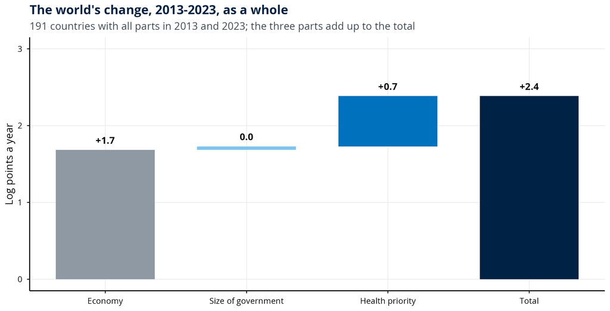

```r
# The waterfall: each part starts where the previous one ends, and the last bar is the total
steps <- tibble(
  x = 1:4,
  part = factor(unname(PART_LABEL), levels = unname(PART_LABEL)),
  from = c(0, parts[1], parts[1] + parts[2], 0),
  to = c(parts[1], parts[1] + parts[2], parts[1] + parts[2] + parts[3], parts[4]),
  bottom = pmin(from, to),
  top = pmax(from, to),
  label = signed(parts)
)
ggplot(steps) +
  geom_rect(aes(xmin = x - 0.35, xmax = x + 0.35, ymin = bottom, ymax = top, fill = part)) +
  geom_text(aes(x = x, y = top + 0.08, label = label),
    vjust = 0, size = 3.6, fontface = "bold"
  ) +
  scale_x_continuous(breaks = 1:4, labels = levels(steps$part)) +
  scale_fill_manual(values = PART_FILL, guide = "none") +
  coord_cartesian(ylim = c(0, 3)) +
  labs(
    x = NULL, y = "Log points a year", title = "The world's change, 2013-2023, as a whole",
    subtitle = paste(
      world$n_agg, "countries with all parts in 2013 and 2023; the three parts add up to the total"
    )
  )
```

## 2. Evolution of real government health expenditure per capita, 2000-2023

*How did public health spending evolve across countries and income groups?*

Real government health expenditure per capita is summarised using a balanced panel with complete observations throughout 2000-2023. The country median and interquartile range capture the typical experience and dispersion, while the population-weighted aggregate measures total government health spending relative to the combined population. Maintaining a fixed panel prevents changes in country coverage from being mistaken for expenditure growth. A separate annual median based on all available observations provides additional context.

The annualised country-level rate for 2000-2023 is derived from the year-weighted changes across 2000-2010, 2010-2019, and 2019-2023. Income-group medians illustrate differences in country trajectories; the ratio of aggregate spending per capita in high- and low-income groups captures the scale of the spending gap. The distinction between median and aggregate results is important: large, high-spending countries can dominate the global aggregate without representing the experience of a typical country.

```r
## Slide 2: the trend 2000-2023 (median, middle half, as a whole), the median country's 23-year
## rate, income-group medians and the high-to-low ratio.
world_trend <- mine$trend |>
  filter(key == "world") |>
  arrange(year)
world_2000 <- filter(world_trend, year == 2000)
world_2019 <- filter(world_trend, year == 2019)
world_2020 <- filter(world_trend, year == 2020)
world_2022 <- filter(world_trend, year == 2022)
world_2023 <- filter(world_trend, year == 2023)

# Each country's 23-year rate is the year-weighted average of its three period rates (10, 9 and 4
# years), which is exact for log points; we take the countries with all three periods
country_rates <- mine$per |>
  select(iso3, period, total) |>
  pivot_wider(names_from = period, values_from = total) |>
  filter(!is.na(P1), !is.na(P2), !is.na(P3)) |>
  mutate(rate_23 = (10 * P1 + 9 * P2 + 4 * P3) / 23) |>
  left_join(select(mine$win, iso3, income_group), by = "iso3")
low_rates <- filter(country_rates, income_group == "low")
median_rate <- median(country_rates$rate_23)

# the income groups in 2000 and 2023: the median country, and the high-to-low ratio of the wholes
income_trend <- mine$trend |>
  filter(grouping == "income") |>
  arrange(match(key, INC))
income_2000 <- filter(income_trend, year == 2000)
income_2023 <- filter(income_trend, year == 2023)
ratio_2000 <- income_2000$agg_ghe[income_2000$key == "high"] /
  income_2000$agg_ghe[income_2000$key == "low"]
ratio_2023 <- income_2023$agg_ghe[income_2023$key == "high"] /
  income_2023$agg_ghe[income_2023$key == "low"]

world_table <- tibble(
  Item = c(
    "Countries with data in every year (balanced panel)", "Median, 2000", "Median, 2023",
    "Median country's change, 2000-2023, log points a year", "As a whole, 2000", "As a whole, 2023",
    "Countries spending less per person in 2023 than in 2000", "As a whole, 2019",
    "As a whole, 2020", "Median, 2022", "All countries with data: median, 2000",
    "All countries with data: countries, 2000", "All countries with data: median, 2023",
    "All countries with data: countries, 2023"
  ),
  Value = c(
    world_2000$n_bal,
    dollars(world_2000$med_ghe_bal),
    dollars(world_2023$med_ghe_bal),
    one_decimal(abs(median_rate)),
    dollars(world_2000$agg_ghe),
    dollars(world_2023$agg_ghe),
    sum(country_rates$rate_23 < 0),
    dollars(world_2019$agg_ghe),
    dollars(world_2020$agg_ghe),
    dollars(world_2022$med_ghe_bal),
    dollars(world_2000$med_ghe),
    world_2000$n,
    dollars(world_2023$med_ghe),
    world_2023$n
  )
)
income_table <- tibble(
  `Income group` = c(
    unname(INC_LABEL),
    "High to low, groups as a whole",
    "Low income: spent less in 2023 than in 2000"
  ),
  `2000` = c(dollars(income_2000$med_ghe), paste(round(ratio_2000), "to one"), ""),
  `2023` = c(
    dollars(income_2023$med_ghe),
    paste(round(ratio_2023), "to one"),
    paste(sum(low_rates$rate_23 < 0), "of", nrow(low_rates))
  )
)
tables <- list(
  "World, constant 2023 US$ per person" = world_table,
  "Income groups" = income_table
)
show_tables(tables)
```

World, constant 2023 US$ per person

| Item | Value |
| --- | --- |
| Countries with data in every year (balanced panel) | 184 |
| Median, 2000 | US$106 |
| Median, 2023 | US$288 |
| Median country’s change, 2000-2023, log points a year | 3.0 |
| As a whole, 2000 | US$437 |
| As a whole, 2023 | US$823 |
| Countries spending less per person in 2023 than in 2000 | 16 |
| As a whole, 2019 | US$747 |
| As a whole, 2020 | US$836 |
| Median, 2022 | US$267 |
| All countries with data: median, 2000 | US$102 |
| All countries with data: countries, 2000 | 185 |
| All countries with data: median, 2023 | US$254 |
| All countries with data: countries, 2023 | 193 |

Income groups

| Income group | 2000 | 2023 |
| --- | --- | --- |
| Low income | US$5.2 | US$6.5 |
| Lower middle income | US$20.9 | US$45.1 |
| Upper middle income | US$106 | US$308 |
| High income | US$919 | US$1,783 |
| High to low, groups as a whole | 229 to one | 489 to one |
| Low income: spent less in 2023 than in 2000 |  | 7 of 22 |

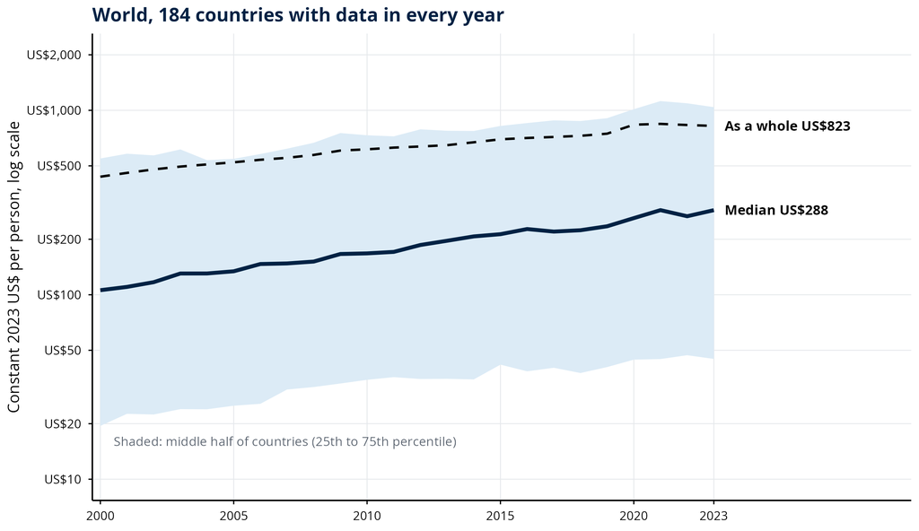

```r
# the two lines end with their 2023 value
line_ends <- tibble(
  year = 2023,
  y = c(world_2023$agg_ghe, world_2023$med_ghe_bal),
  label = c(
    paste("As a whole", dollars(world_2023$agg_ghe)),
    paste("Median", dollars(world_2023$med_ghe_bal))
  )
)
ggplot(world_trend, aes(year)) +
  geom_ribbon(aes(ymin = p25_ghe_bal, ymax = p75_ghe_bal), fill = WB[["tint"]]) +
  geom_line(aes(y = agg_ghe), colour = "black", linewidth = 0.8, linetype = "dashed") +
  geom_line(aes(y = med_ghe_bal), colour = WB[["navy"]], linewidth = 1.3) +
  geom_text(
    data = line_ends, aes(x = year + 0.4, y = y, label = label),
    hjust = 0, size = 3.4, fontface = "bold"
  ) +
  annotate("text",
    x = 2000.5, y = 16, label = "Shaded: middle half of countries (25th to 75th percentile)",
    hjust = 0, size = 3.2, colour = WB[["slate"]]
  ) +
  scale_y_log10(
    breaks = c(10, 20, 50, 100, 200, 500, 1000, 2000), limits = c(10, 2000),
    labels = scales::label_comma(prefix = "US$")
  ) +
  scale_x_continuous(
    breaks = c(2000, 2005, 2010, 2015, 2020, 2023), expand = expansion(add = c(0.3, 7))
  ) +
  labs(
    x = NULL, y = "Constant 2023 US$ per person, log scale",
    title = paste0("World, ", world_2000$n_bal, " countries with data in every year")
  )
```

## 3. Historical drivers of spending growth across three periods

*Has economic growth remained the principal contributor to higher health expenditure?*

The decomposition is compared across 2000-2010, 2010-2019, and 2019-2023. For each period, the global aggregate is constructed from countries with complete endpoint observations, preserving the exact sum of contributions. Separately calculated country medians indicate the typical direction and magnitude of each component, while the distribution of economy-led countries shows how frequently GDP growth was the dominant contributor.

The 2019-2023 interval requires particular caution. Its four-year duration captures the exceptional fiscal and economic changes associated with the COVID-19 pandemic and their partial reversal, making it less comparable to the two longer periods. Weakening contributions from GDP per capita raise an important fiscal question: to what extent can changes in the overall public spending envelope and the allocation to health sustain expenditure growth when economic growth slows?

```r
## Slide 3: the world by fixed period, as a whole (chart) and as the median country (table), and the
## count of economy-led countries per period.
world_periods <- mine$grp |>
  filter(key == "world", period %in% c("P1", "P2", "P3")) |>
  arrange(period)
world_patterns <- mine$pat_per |>
  filter(key == "world") |>
  arrange(period)

median_country <- tibble(
  Period = unname(PERIOD_LABEL),
  Economy = signed(world_periods$med_econ),
  `Size of government` = signed(world_periods$med_budget),
  `Health priority` = signed(world_periods$med_priority),
  Total = signed(world_periods$med_total),
  n = world_periods$n_med
)
world_whole <- tibble(
  Period = unname(PERIOD_LABEL),
  Economy = signed(world_periods$agg_econ),
  `Size of government` = signed(world_periods$agg_budget),
  `Health priority` = signed(world_periods$agg_priority),
  Total = signed(world_periods$agg_total),
  Countries = world_periods$n_agg
)
economy_led <- tibble(
  Period = unname(PERIOD_LABEL),
  `Economy-led` = world_patterns$`Economy-led`,
  Countries = world_patterns$n
)
tables <- list(
  "Median country, log points a year (each part's median taken separately)" = median_country,
  "World as a whole, log points a year (the parts add up)" = world_whole,
  "Economy-led countries by period" = economy_led
)
show_tables(tables)
```

Median country, log points a year (each part’s median taken separately)

| Period | Economy | Size of government | Health priority | Total | n |
| --- | --- | --- | --- | --- | --- |
| 2000-2010 | +2.3 | +0.9 | +0.7 | +3.7 | 185 |
| 2010-2019 | +2.0 | -0.3 | +1.0 | +2.7 | 189 |
| 2019-2023 | +0.8 | +1.0 | +0.7 | +2.4 | 193 |

World as a whole, log points a year (the parts add up)

| Period | Economy | Size of government | Health priority | Total | Countries |
| --- | --- | --- | --- | --- | --- |
| 2000-2010 | +1.6 | +1.0 | +0.9 | +3.4 | 185 |
| 2010-2019 | +1.8 | -0.6 | +1.0 | +2.1 | 189 |
| 2019-2023 | +1.4 | +0.4 | +0.5 | +2.4 | 193 |

Economy-led countries by period

| Period | Economy-led | Countries |
| --- | --- | --- |
| 2000-2010 | 85 | 185 |
| 2010-2019 | 75 | 189 |
| 2019-2023 | 36 | 193 |

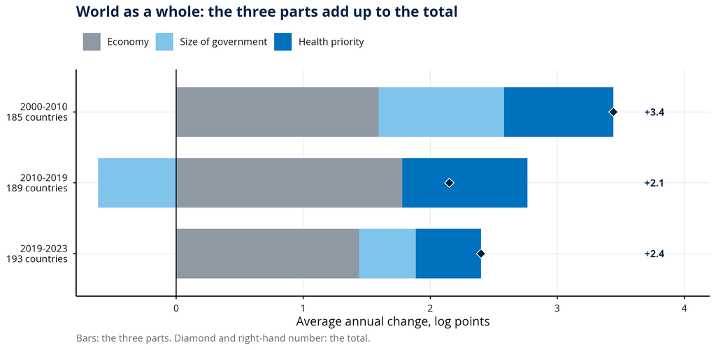

```r
whole <- tibble(
  label = paste0(PERIOD_LABEL, "\n", world_periods$n_agg, " countries"),
  econ = world_periods$agg_econ,
  budget = world_periods$agg_budget,
  priority = world_periods$agg_priority,
  total = world_periods$agg_total
)
plot_parts(whole, "label") +
  labs(title = "World as a whole: the three parts add up to the total")
```

## 4. Spending growth by income group

*How do the sources of government health spending growth differ by income level?*

Country-level medians are reported for the most recent eligible window, generally 2013-2023, while income-group aggregates use the common 2013 and 2023 endpoints. These two perspectives reveal whether the broad trajectory of an income group reflects the experience of most member countries or is concentrated in its largest contributors.

Aggregate results are particularly sensitive to large countries, including India among lower-middle-income countries, China among upper-middle-income countries, and the United States among high-income countries. Differences between the median and the aggregate should therefore be interpreted as evidence of uneven contributions within groups rather than conflicting estimates of the same quantity.

```r
## Slide 4: income groups over the latest window, the median country (table) and each group as a
## whole 2013-2023 (chart), and the largest member's share of each group's spending.
income_rows <- mine$grp |>
  filter(period == "W", key %in% c("world", INC)) |>
  arrange(match(key, c("world", INC)))
group_names <- c("World", unname(INC_LABEL))

# the largest member of each income group and its share of the group's spending in 2023
largest <- mine$contrib |>
  filter(income_group %in% INC) |>
  group_by(income_group) |>
  mutate(share = 100 * ghe1_musd / sum(ghe1_musd)) |>
  slice_max(ghe1_musd, n = 1, with_ties = FALSE) |>
  ungroup() |>
  arrange(match(income_group, INC)) |>
  left_join(short_names, by = "iso3") |>
  transmute(
    `Income group` = unname(INC_LABEL[income_group]),
    `Largest member` = short,
    `Share of the group's spending, 2023` = whole_pct(share)
  )

median_country <- tibble(
  `Income group` = group_names,
  Economy = signed(income_rows$med_econ),
  `Size of government` = signed(income_rows$med_budget),
  `Health priority` = signed(income_rows$med_priority),
  Total = signed(income_rows$med_total),
  n = income_rows$n_med
)
group_whole <- tibble(
  `Income group` = group_names,
  Economy = signed(income_rows$agg_econ),
  `Size of government` = signed(income_rows$agg_budget),
  `Health priority` = signed(income_rows$agg_priority),
  Total = signed(income_rows$agg_total),
  Countries = income_rows$n_agg
)
tables <- list(
  "Median country, own latest window, log points a year (parts taken separately)" = median_country,
  "Group as a whole, 2013-2023, log points a year (the parts add up)" = group_whole,
  "Largest member of each income group" = largest
)
show_tables(tables)
```

Median country, own latest window, log points a year (parts taken separately)

| Income group | Economy | Size of government | Health priority | Total | n |
| --- | --- | --- | --- | --- | --- |
| World | +1.4 | +0.1 | +1.1 | +2.8 | 194 |
| Low income | +1.3 | +0.9 | +0.2 | +2.5 | 25 |
| Lower middle income | +1.5 | -0.1 | +1.5 | +2.1 | 51 |
| Upper middle income | +1.5 | +0.4 | +1.4 | +3.2 | 53 |
| High income | +1.4 | -0.1 | +1.1 | +2.4 | 65 |

Group as a whole, 2013-2023, log points a year (the parts add up)

| Income group | Economy | Size of government | Health priority | Total | Countries |
| --- | --- | --- | --- | --- | --- |
| World | +1.7 | 0.0 | +0.7 | +2.4 | 191 |
| Low income | +0.6 | -2.1 | +0.4 | -1.1 | 24 |
| Lower middle income | +3.4 | +0.2 | +2.1 | +5.7 | 51 |
| Upper middle income | +3.6 | +0.9 | +0.7 | +5.2 | 51 |
| High income | +1.5 | 0.0 | +1.0 | +2.6 | 65 |

Largest member of each income group

| Income group | Largest member | Share of the group’s spending, 2023 |
| --- | --- | --- |
| Low income | Ethiopia | 19% |
| Lower middle income | India | 44% |
| Upper middle income | China | 61% |
| High income | United States | 47% |

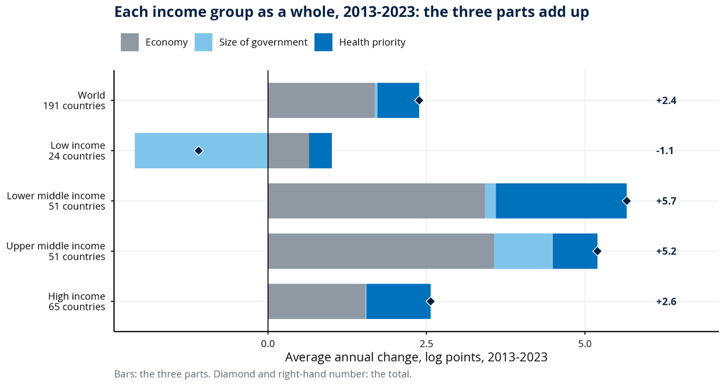

```r
whole <- tibble(
  label = paste0(group_names, "\n", income_rows$n_agg, " countries"),
  econ = income_rows$agg_econ,
  budget = income_rows$agg_budget,
  priority = income_rows$agg_priority,
  total = income_rows$agg_total
)
plot_parts(whole, "label", xlab = "Average annual change, log points, 2013-2023") +
  labs(title = "Each income group as a whole, 2013-2023: the three parts add up")
```

## 5. Regional differences in the drivers of spending growth

*Which components account for changes in government health expenditure across regions?*

The analysis compares the median country within each World Bank region with the regional aggregate for 2013-2023. Positive and negative contributions are distinguished for economic capacity, government size, and health priority. Counts of countries with declining real health expenditure per capita provide a complementary measure of the breadth of progress or reversal.

Regional medians and aggregates can diverge substantially. In East Asia and the Pacific, for example, economic growth accounts for most of the increase in the regional aggregate, whereas greater budget priority for health contributes more prominently to the median country’s trajectory. North America and South Asia have fewer than eight eligible countries and are included for completeness without being used for direct regional comparisons.

```r
## Slide 5: World Bank regions over the latest window, median country and region as a whole, and the
## share of countries whose spending per person fell.
region_rows <- mine$grp |>
  filter(period == "W", key %in% c("world", REG)) |>
  arrange(match(key, c("world", REG)))
region_names <- c("World", unname(REG_LABEL[REG]))
# regions with fewer than eight countries are described, not compared
compared <- grepl("^Carries", region_rows$status)

heat <- tibble(
  Region = region_names,
  Countries = region_rows$n_med,
  Compared = if_else(compared, "yes", "described only"),
  `Median: Economy` = signed(region_rows$med_econ),
  `Median: Size of government` = signed(region_rows$med_budget),
  `Median: Health priority` = signed(region_rows$med_priority),
  `Median: Total` = signed(region_rows$med_total),
  `Whole: Economy` = signed(region_rows$agg_econ),
  `Whole: Size of government` = signed(region_rows$agg_budget),
  `Whole: Health priority` = signed(region_rows$agg_priority),
  `Whole: Total` = signed(region_rows$agg_total)
)

# countries whose spending per person fell over their window, the highest share first
fell <- mine$pat_reg |>
  filter(key %in% REG) |>
  arrange(match(key, REG)) |>
  mutate(pct = round(100 * Declining / n)) |>
  arrange(desc(pct), desc(n))
fell_table <- tibble(
  Region = unname(REG_LABEL[fell$key]),
  Declining = paste(fell$Declining, "of", fell$n),
  Share = paste0(fell$pct, "%")
)

tables <- list(
  "Log points a year: median country (own window) and region as a whole (2013-2023)" = heat,
  "Countries whose spending per person fell over their window" = fell_table
)
show_tables(tables)
```

Log points a year: median country (own window) and region as a whole (2013-2023)

| Region | Countries | Compared | Median: Economy | Median: Size of government | Median: Health priority | Median: Total | Whole: Economy | Whole: Size of government | Whole: Health priority | Whole: Total |
| --- | --- | --- | --- | --- | --- | --- | --- | --- | --- | --- |
| World | 194 | yes | +1.4 | +0.1 | +1.1 | +2.8 | +1.7 | 0.0 | +0.7 | +2.4 |
| East Asia and Pacific | 29 | yes | +2.0 | +0.5 | +2.2 | +3.8 | +3.7 | +0.6 | +0.2 | +4.5 |
| Europe and Central Asia | 52 | yes | +1.9 | -0.1 | +0.7 | +2.9 | +1.4 | 0.0 | +0.5 | +1.9 |
| Latin America and the Caribbean | 32 | yes | +1.0 | +0.5 | +0.8 | +2.4 | +0.3 | +0.7 | +0.2 | +1.2 |
| Middle East, North Africa, Afghanistan and Pakistan | 23 | yes | -0.1 | -0.9 | +3.0 | +2.3 | +0.7 | -0.9 | +3.3 | +3.0 |
| North America | 2 | described only | +1.2 | +0.8 | +0.3 | +2.2 | +1.6 | +0.1 | +1.2 | +2.9 |
| South Asia | 6 | described only | +3.1 | +1.1 | +1.6 | +6.3 | +4.8 | +0.7 | +2.9 | +8.3 |
| Sub-Saharan Africa | 48 | yes | +1.3 | +0.4 | +1.0 | +2.3 | +0.2 | -0.5 | +1.4 | +1.0 |

Countries whose spending per person fell over their window

| Region | Declining | Share |
| --- | --- | --- |
| Middle East, North Africa, Afghanistan and Pakistan | 9 of 23 | 39% |
| Sub-Saharan Africa | 16 of 48 | 33% |
| Latin America and the Caribbean | 8 of 32 | 25% |
| South Asia | 1 of 6 | 17% |
| Europe and Central Asia | 4 of 52 | 8% |
| East Asia and Pacific | 1 of 29 | 3% |
| North America | 0 of 2 | 0% |

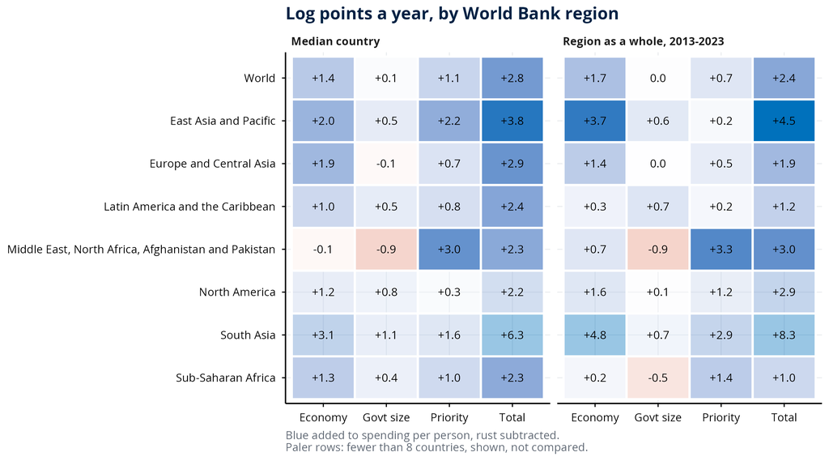

```r
# The heat table as a chart: one tile per region, block and part. The colour
# scale stops at 4 log points either way.
heat_long <- region_rows |>
  mutate(
    region = factor(region_names, levels = rev(region_names)),
    compared = compared
  ) |>
  select(
    region, compared, med_econ, med_budget, med_priority, med_total,
    agg_econ, agg_budget, agg_priority, agg_total
  ) |>
  pivot_longer(
    -c(region, compared),
    names_to = c("block", "part"), names_sep = "_", values_to = "value"
  ) |>
  mutate(
    block = if_else(block == "med", "Median country", "Region as a whole, 2013-2023"),
    part = factor(unname(PART_LABEL[part]), levels = unname(PART_LABEL)),
    fill = pmin(pmax(value, -4), 4),
    label = signed(value)
  )
ggplot(heat_long, aes(x = part, y = region)) +
  geom_tile(aes(fill = fill, alpha = compared), colour = "white", linewidth = 0.8) +
  geom_text(aes(label = label), size = 3.2) +
  facet_wrap(~block) +
  scale_fill_gradient2(
    low = WB[["rust"]], mid = "white", high = WB[["blue"]], midpoint = 0, guide = "none"
  ) +
  scale_alpha_manual(values = c(`TRUE` = 1, `FALSE` = 0.4), guide = "none") +
  scale_x_discrete(labels = c("Economy", "Govt size", "Priority", "Total")) +
  labs(
    x = NULL, y = NULL, title = "Log points a year, by World Bank region",
    caption = paste(
      "Blue added to spending per person, rust subtracted.",
      "Paler rows: fewer than 8 countries, shown, not compared.",
      sep = "\n"
    )
  ) +
  theme(panel.grid = element_blank())
```

## 6. Divergent outcomes among low-income countries, 2013-2023

*Why can expenditure rise in the typical country while falling for the group as a whole?*

The median low-income country recorded an increase in real government health expenditure per capita between 2013 and 2023, even as the aggregate for the income group declined. The country-level comparison reports the change in annual government health expenditure at constant 2023 prices, combining per-capita expenditure with population for countries with complete endpoint information.

The apparent divergence reflects differences in country size and the magnitude of spending changes. Aggregate expenditure grew more slowly than the combined population, resulting in a decline in expenditure per capita. Large absolute losses in Syria, Sudan, and Yemen, each subject to data-quality flags, contributed substantially to the group result. Comparing estimates with and without flagged countries helps assess the sensitivity of the aggregate to these exceptional observations.

```r
## Slide 6: each low-income country's change in annual spending 2013-2023 (US$
## million, 2023 prices), the group's spending and population, and the median and
## whole with and without flagged countries.
low_income <- filter(mine$contrib, income_group == "low")
spend_2013 <- sum(low_income$ghe0_musd)
spend_2023 <- sum(low_income$ghe1_musd)
pop_2013 <- sum(low_income$pop0_m)
pop_2023 <- sum(low_income$pop1_m)

# each country's change, smallest first, printed whole with its sign
low <- low_income |>
  left_join(short_names, by = "iso3") |>
  mutate(
    change = ghe1_musd - ghe0_musd,
    rounded_change = round(change),
    change_label = scales::comma(change, accuracy = 1, style_positive = "plus")
  ) |>
  arrange(change)
gains <- low |>
  filter(rounded_change > 0) |>
  arrange(desc(rounded_change))
# Syria, Sudan and Yemen: their spending in 2013 and 2023, and what the three lost together
three <- low |>
  filter(iso3 %in% c("SYR", "SDN", "YEM")) |>
  mutate(
    printed_2013 = scales::comma(ghe0_musd, accuracy = 1),
    printed_2023 = scales::comma(ghe1_musd, accuracy = 1),
    range = paste(printed_2013, "to", printed_2023)
  )
lost_by_three <- -sum(three$change)

# countries whose window carries a data flag
flagged <- mine$win |>
  filter(!is.na(total), !is.na(flag), nzchar(flag)) |>
  pull(iso3)

# the median country and the group as a whole, with and without the flagged countries
low_all <- filter(mine$grp, key == "low", period == "W")
low_median_no_flag <- filter(mine$nf_med, key == "low")
low_whole_no_flag <- filter(mine$nf_agg, key == "low")

group_table <- tibble(
  Item = c(
    "Countries", "Spending, US$ million, 2013", "Spending, US$ million, 2023", "Change in spending",
    "Population, million, 2013", "Population, million, 2023", "Change in population",
    "Spending lost by Syria, Sudan and Yemen, US$ million", "Syria, US$ million, 2013 and 2023",
    "Sudan, US$ million, 2013 and 2023", "Yemen, US$ million, 2013 and 2023", "Largest gains"
  ),
  Value = c(
    nrow(low),
    scales::comma(spend_2013, accuracy = 1),
    scales::comma(spend_2023, accuracy = 1),
    paste0("+", round(100 * (spend_2023 / spend_2013 - 1)), "%"),
    scales::comma(pop_2013, accuracy = 1),
    scales::comma(pop_2023, accuracy = 1),
    paste0("+", round(100 * (pop_2023 / pop_2013 - 1)), "%"),
    scales::comma(lost_by_three, accuracy = 1),
    three$range[three$iso3 == "SYR"],
    three$range[three$iso3 == "SDN"],
    three$range[three$iso3 == "YEM"],
    knitr::combine_words(gains$short[1:4], oxford_comma = FALSE)
  )
)
two_statistics <- tibble(
  Statistic = c(
    "Median country", "Group as a whole", "Median, without flagged countries",
    "As a whole, without flagged countries"
  ),
  Countries = c(low_all$n_med, low_all$n_agg, low_median_no_flag$n_med, low_whole_no_flag$n_agg),
  `Log points a year` = signed(c(
    low_all$med_total, low_all$agg_total, low_median_no_flag$med_total, low_whole_no_flag$agg_total
  ))
)
by_country <- tibble(
  Country = low$short,
  Change = low$change_label,
  Flag = if_else(low$iso3 %in% flagged, "flagged", "")
)
tables <- list(
  "The low-income group, 2013 and 2023" = group_table,
  "Two statistics, with and without flagged countries (low income, latest window)" = two_statistics,
  "Change in annual spending by country, US$ million at 2023 prices" = by_country
)
show_tables(tables)
```

The low-income group, 2013 and 2023

| Item | Value |
| --- | --- |
| Countries | 24 |
| Spending, US$ million, 2013 | 4,331 |
| Spending, US$ million, 2023 | 5,143 |
| Change in spending | +19% |
| Population, million, 2013 | 527 |
| Population, million, 2023 | 697 |
| Change in population | +32% |
| Spending lost by Syria, Sudan and Yemen, US$ million | 960 |
| Syria, US$ million, 2013 and 2023 | 607 to 118 |
| Sudan, US$ million, 2013 and 2023 | 516 to 219 |
| Yemen, US$ million, 2013 and 2023 | 332 to 159 |
| Largest gains | Burkina Faso, DR Congo, Mozambique and Rwanda |

Two statistics, with and without flagged countries (low income, latest window)

| Statistic | Countries | Log points a year |
| --- | --- | --- |
| Median country | 25 | +2.5 |
| Group as a whole | 24 | -1.1 |
| Median, without flagged countries | 14 | +4.2 |
| As a whole, without flagged countries | 14 | +2.5 |

Change in annual spending by country, US$ million at 2023 prices

| Country | Change | Flag |
| --- | --- | --- |
| Syria | -490 | flagged |
| Sudan | -297 | flagged |
| Yemen | -173 | flagged |
| Afghanistan | -39 | flagged |
| Malawi | -31 | flagged |
| Burundi | -1 | flagged |
| Madagascar | -1 | flagged |
| Togo | +8 |  |
| Eritrea | +9 | flagged |
| Guinea-Bissau | +12 |  |
| Gambia | +13 |  |
| Central African Republic | +20 |  |
| Sierra Leone | +22 |  |
| Niger | +30 |  |
| Somalia | +51 | flagged |
| Liberia | +52 | flagged |
| Chad | +104 |  |
| Uganda | +166 |  |
| Mali | +173 |  |
| Ethiopia | +178 |  |
| Rwanda | +181 |  |
| Mozambique | +257 |  |
| DR Congo | +267 |  |
| Burkina Faso | +302 |  |

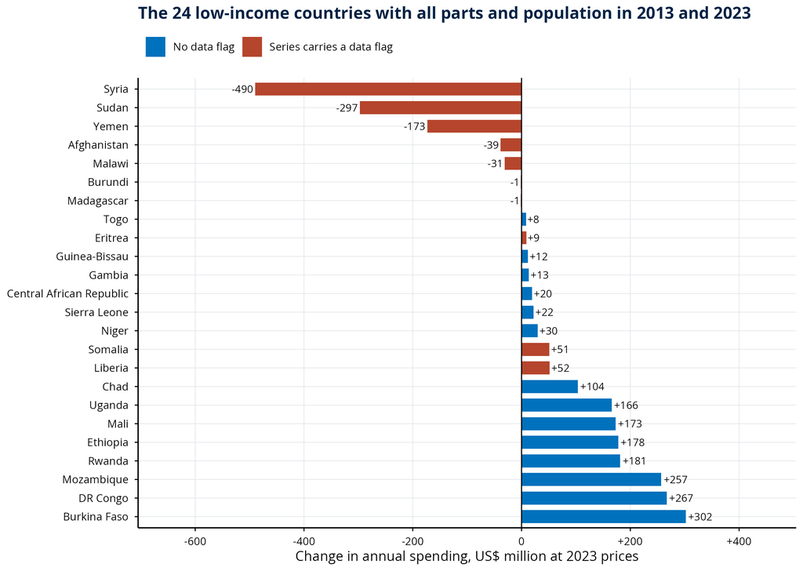

```r
low_chart <- low |>
  mutate(
    country = factor(short, levels = rev(short)),
    flag_status = if_else(iso3 %in% flagged, "Series carries a data flag", "No data flag"),
    label_hjust = if_else(change < 0, 1.1, -0.1)
  )
ggplot(low_chart, aes(x = change, y = country, fill = flag_status)) +
  geom_col(width = 0.7) +
  geom_vline(xintercept = 0, colour = "black", linewidth = 0.4) +
  geom_text(aes(label = change_label, hjust = label_hjust), size = 3) +
  scale_fill_manual(
    values = c("No data flag" = WB[["blue"]], "Series carries a data flag" = WB[["rust"]])
  ) +
  scale_x_continuous(
    limits = c(-650, 450), breaks = seq(-600, 400, 200),
    labels = scales::label_number(style_positive = "plus")
  ) +
  labs(
    x = "Change in annual spending, US$ million at 2023 prices", y = NULL,
    title = paste(
      "The", nrow(low), "low-income countries with all parts and population in 2013 and 2023"
    )
  )
```

## 7. Patterns of expenditure growth across countries and periods

*Are increases driven primarily by GDP growth, government expansion, or prioritisation of health?*

Countries are grouped into four mutually exclusive patterns: declining expenditure per capita, economy-led growth, government-size-led growth, and health-priority-led growth. For countries with positive growth, the classification follows the component with the largest contribution. The distribution is reported by income group for the latest observation window, across historical periods globally, and for countries observed in both 2010-2019 and 2019-2023.

Growth patterns are not fixed national characteristics. Countries frequently move between categories as economic conditions and fiscal priorities change. Across the most recent windows, government-size-led and health-priority-led cases together outnumber economy-led cases, demonstrating the importance of fiscal and allocation decisions alongside GDP growth. The categories remain descriptive and do not attribute changes to specific reforms.

```r
## Slide 7: pattern counts by income group (latest window) and by period (world), and how often a
## country's pattern changed between 2010-2019 and 2019-2023.
PATTERNS <- c("Economy-led", "Budget-led", "Priority-led", "Declining")
by_income <- mine$pat_inc |>
  filter(key %in% c("world", INC)) |>
  arrange(match(key, c("world", INC)))
world_by_period <- mine$pat_per |>
  filter(key == "world") |>
  arrange(period)
# the three periods, then the latest window
by_period <- bind_rows(world_by_period, by_income[1, ]) |>
  select(n, all_of(PATTERNS))

# countries with a 2010-2019 and a 2019-2023 decomposition, and
# the pattern of each in the two periods
patterns_2010s <- mine$per |>
  filter(period == "P2") |>
  select(iso3, pattern_2010s = pattern)
patterns_pandemic <- mine$per |>
  filter(period == "P3") |>
  select(iso3, pattern_pandemic = pattern)
moved <- inner_join(patterns_2010s, patterns_pandemic, by = "iso3")
europe <- filter(mine$pat_reg, key == "Europe & Central Asia")
africa <- filter(mine$pat_reg, key == "Sub-Saharan Africa")
world <- by_income[1, ]

income_table <- tibble(
  Group = c("World", unname(INC_LABEL)),
  n = by_income$n,
  `Economy-led` = by_income$`Economy-led`,
  `Budget-led` = by_income$`Budget-led`,
  `Priority-led` = by_income$`Priority-led`,
  Declining = by_income$Declining,
  `Share declining` = c("", whole_pct(100 * by_income$Declining[-1] / by_income$n[-1]))
)
period_table <- tibble(
  Group = c(unname(PERIOD_LABEL), "Latest window"),
  n = by_period$n,
  `Economy-led` = by_period$`Economy-led`,
  `Budget-led` = by_period$`Budget-led`,
  `Priority-led` = by_period$`Priority-led`,
  Declining = by_period$Declining
)
movement_table <- tibble(
  Item = c(
    "Countries with both 2010-2019 and 2019-2023", "Changed pattern", "Economy-led in 2010-2019",
    "Still economy-led in 2019-2023", "Budget-led or priority-led, latest window",
    "Economy-led, latest window", "Europe and Central Asia: economy-led",
    "Sub-Saharan Africa: declining"
  ),
  Value = c(
    nrow(moved),
    sum(moved$pattern_2010s != moved$pattern_pandemic),
    sum(moved$pattern_2010s == "Economy-led"),
    sum(moved$pattern_2010s == "Economy-led" & moved$pattern_pandemic == "Economy-led"),
    world$`Budget-led` + world$`Priority-led`,
    world$`Economy-led`,
    paste(europe$`Economy-led`, "of", europe$n),
    paste(africa$Declining, "of", africa$n)
  )
)
tables <- list(
  "Patterns by income group, latest window (countries)" = income_table,
  "Patterns by period, world (countries)" = period_table,
  "Movement between periods and other counts on the slide" = movement_table
)
show_tables(tables)
```

Patterns by income group, latest window (countries)

| Group | n | Economy-led | Budget-led | Priority-led | Declining | Share declining |
| --- | --- | --- | --- | --- | --- | --- |
| World | 194 | 67 | 27 | 60 | 40 |  |
| Low income | 25 | 2 | 7 | 5 | 11 | 44% |
| Lower middle income | 51 | 13 | 7 | 17 | 14 | 27% |
| Upper middle income | 53 | 20 | 6 | 19 | 8 | 15% |
| High income | 65 | 32 | 7 | 19 | 7 | 11% |

Patterns by period, world (countries)

| Group | n | Economy-led | Budget-led | Priority-led | Declining |
| --- | --- | --- | --- | --- | --- |
| 2000-2010 | 185 | 85 | 38 | 31 | 31 |
| 2010-2019 | 189 | 75 | 27 | 60 | 27 |
| 2019-2023 | 193 | 36 | 49 | 57 | 51 |
| Latest window | 194 | 67 | 27 | 60 | 40 |

Movement between periods and other counts on the slide

| Item | Value |
| --- | --- |
| Countries with both 2010-2019 and 2019-2023 | 188 |
| Changed pattern | 139 |
| Economy-led in 2010-2019 | 75 |
| Still economy-led in 2019-2023 | 19 |
| Budget-led or priority-led, latest window | 87 |
| Economy-led, latest window | 67 |
| Europe and Central Asia: economy-led | 33 of 52 |
| Sub-Saharan Africa: declining | 16 of 48 |

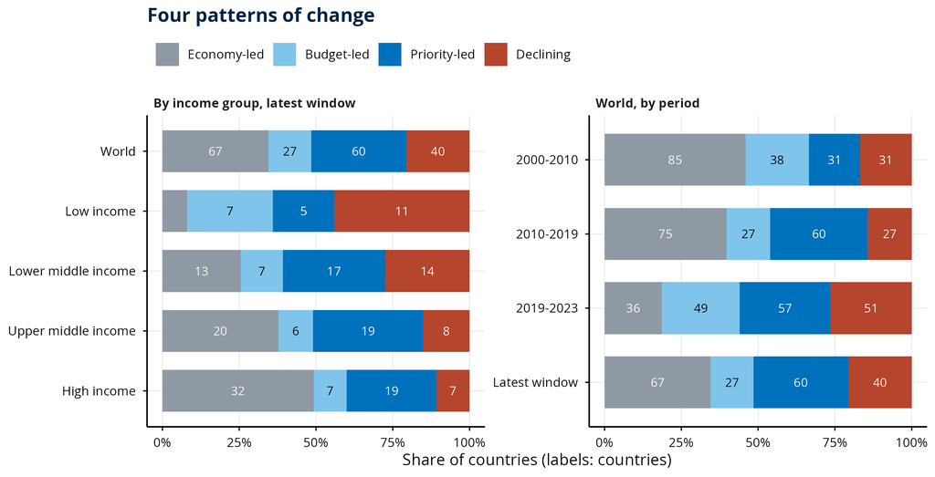

```r
# one bar per group, split into the four patterns as shares of the group's countries
group_order <- c("World", unname(INC_LABEL), unname(PERIOD_LABEL), "Latest window")
shares <- bind_rows(
  mutate(
    by_income,
    panel = "By income group, latest window",
    group = c("World", unname(INC_LABEL))
  ),
  mutate(
    by_period,
    panel = "World, by period",
    group = c(unname(PERIOD_LABEL), "Latest window")
  )
) |>
  pivot_longer(all_of(PATTERNS), names_to = "pattern", values_to = "count") |>
  mutate(
    pattern = factor(pattern, levels = rev(PATTERNS)),
    group = factor(group, levels = rev(group_order)),
    # we write the count on segments of four countries or more, in black on the light blue
    label = if_else(count >= 4, as.character(count), ""),
    label_colour = if_else(pattern == "Budget-led", "black", "white")
  )
ggplot(shares, aes(x = 100 * count / n, y = group, fill = pattern)) +
  geom_col(width = 0.7) +
  geom_text(
    aes(label = label, colour = label_colour, group = pattern),
    position = position_stack(vjust = 0.5), size = 3
  ) +
  scale_colour_identity() +
  facet_wrap(~panel, scales = "free_y") +
  scale_fill_manual(
    values = c(
      "Economy-led" = "#8f99a3", "Budget-led" = "#7fc4ea", "Priority-led" = "#0071bc",
      Declining = "#b5452c"
    ),
    breaks = PATTERNS
  ) +
  scale_x_continuous(breaks = c(0, 25, 50, 75, 100), labels = scales::label_percent(scale = 1)) +
  labs(x = "Share of countries (labels: countries)", y = NULL, title = "Four patterns of change")
```

## 8. Economic growth and declining budget priority for health

*Where did economic capacity improve while health received a smaller share of public expenditure?*

The country-level comparison places the contribution from real GDP per capita on the horizontal axis and the contribution from health’s budget share on the vertical axis. Countries in the lower-right quadrant experienced positive economic growth alongside a declining share of government expenditure allocated to health. These cases are also identified by income group to distinguish the prevalence of this pattern across different economic contexts.

A declining budget share does not necessarily imply declining health expenditure per capita. Where GDP growth more than compensates for the reduction in health priority, real spending can still rise. For this reason, changes in the budget share and changes in per-capita expenditure should be examined separately. The figure focuses on the central range of observations; quadrant counts also include countries outside the displayed range.

```r
## Slide 8: the economy part against the health priority part for every country with a window, the
## four sign quadrants, and the countries where health lost priority while the economy grew.
win <- mine$win |>
  filter(!is.na(total)) |>
  left_join(short_names, by = "iso3")
econ <- win$econ
prio <- win$priority
total <- win$total
lost <- win$lost_priority %in% TRUE

# the countries where health lost priority while the economy grew, by income group, alphabetical
lost_count <- c()
lost_names <- c()
for (group in INC) {
  in_group <- win |>
    filter(lost_priority %in% TRUE, income_group == group) |>
    arrange(sort_name)
  lost_count[group] <- nrow(in_group)
  lost_names[group] <- knitr::combine_words(in_group$short, oxford_comma = FALSE)
}

counts <- tibble(
  Item = c(
    "Countries with a window", "Economy up, health share up or flat",
    "Economy up, health share down (health lost priority)",
    "Economy flat or down, health share up or flat", "Both down",
    "Lost priority and still spent more per person", "Lost priority and spent less per person",
    "Health share up while the economy stagnated or fell", "... and spending still grew",
    "Health priority part above zero", "Size of government part above zero",
    "Economy part above zero", "Countries outside the view (economy -8 to +10, priority -12 to +12)"
  ),
  Value = c(
    nrow(win),
    sum(econ > 0 & prio >= 0),
    sum(econ > 0 & prio < 0),
    sum(econ <= 0 & prio >= 0),
    sum(econ <= 0 & prio < 0),
    sum(lost & total > 0),
    sum(lost & total < 0),
    sum(econ <= 0 & prio > 0),
    sum(econ <= 0 & prio > 0 & total > 0),
    sum(prio > 0),
    sum(win$budget > 0),
    sum(econ > 0),
    sum(econ < -8 | econ > 10 | prio < -12 | prio > 12)
  )
)
lost_table <- tibble(
  `Income group` = unname(INC_LABEL),
  Countries = unname(lost_count),
  Names = unname(lost_names)
)
tables <- list(
  "Counts on the slide" = counts,
  "Countries where health lost priority while the economy grew, by income group" = lost_table
)
show_tables(tables)
```

Counts on the slide

| Item | Value |
| --- | --- |
| Countries with a window | 194 |
| Economy up, health share up or flat | 105 |
| Economy up, health share down (health lost priority) | 51 |
| Economy flat or down, health share up or flat | 31 |
| Both down | 7 |
| Lost priority and still spent more per person | 34 |
| Lost priority and spent less per person | 17 |
| Health share up while the economy stagnated or fell | 31 |
| … and spending still grew | 17 |
| Health priority part above zero | 135 |
| Size of government part above zero | 103 |
| Economy part above zero | 156 |
| Countries outside the view (economy -8 to +10, priority -12 to +12) | 4 |

Countries where health lost priority while the economy grew, by income group

| Income group | Countries | Names |
| --- | --- | --- |
| Low income | 9 | Ethiopia, Gambia, Guinea-Bissau, Madagascar, Malawi, Niger, Sierra Leone, Togo and Uganda |
| Lower middle income | 16 | Bangladesh, Benin, Cambodia, Djibouti, Eswatini, Honduras, Kiribati, Kyrgyzstan, Myanmar, Senegal, Sri Lanka, Tajikistan, Tanzania, Tunisia, Uzbekistan and Zimbabwe |
| Upper middle income | 15 | Algeria, Armenia, Belize, Bosnia and Herzegovina, Costa Rica, Dominica, Grenada, Maldives, Mexico, Moldova, North Macedonia, Serbia, St. Vincent and the Grenadines, Tonga and Türkiye |
| High income | 11 | Antigua and Barbuda, Bahamas, Barbados, Canada, France, Guyana, Hungary, Italy, Monaco, Romania and Slovakia |

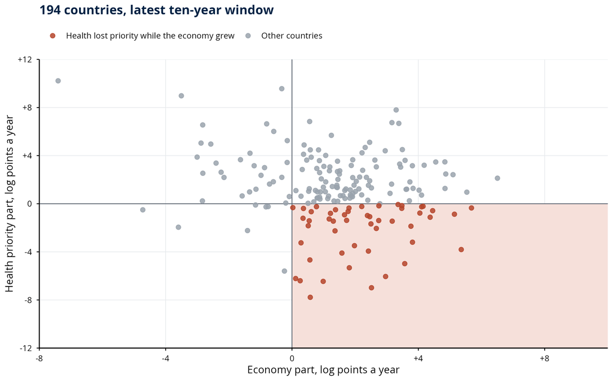

```r
# the countries inside the chart's view
points <- win |>
  filter(econ >= -8, econ <= 10, priority >= -12, priority <= 12) |>
  mutate(lost = if_else(lost_priority %in% TRUE,
    "Health lost priority while the economy grew", "Other countries"
  ))
ggplot(points, aes(econ, priority)) +
  annotate("rect", xmin = 0, xmax = 10, ymin = -12, ymax = 0, fill = "#f6e0da") +
  geom_hline(yintercept = 0, colour = WB[["slate"]], linewidth = 0.4) +
  geom_vline(xintercept = 0, colour = WB[["slate"]], linewidth = 0.4) +
  geom_point(aes(colour = lost), size = 2, alpha = 0.85) +
  scale_colour_manual(values = c(
    "Health lost priority while the economy grew" = WB[["rust"]], "Other countries" = WB[["grey"]]
  )) +
  scale_x_continuous(
    limits = c(-8, 10), breaks = c(-8, -4, 0, 4, 8),
    labels = scales::label_number(style_positive = "plus"), expand = c(0, 0)
  ) +
  scale_y_continuous(
    limits = c(-12, 12), breaks = seq(-12, 12, 4),
    labels = scales::label_number(style_positive = "plus"), expand = c(0, 0)
  ) +
  labs(
    x = "Economy part, log points a year", y = "Health priority part, log points a year",
    title = paste(nrow(win), "countries, latest ten-year window")
  )
```

## 9. The allocation to health before and after the pandemic

*How much of the pandemic-era increase in health’s budget share persisted through 2023?*

Median health shares of total government expenditure are tracked from 2000 to 2023 by income group and for the world. The analysis also follows a consistent set of countries across 2019, 2021, and 2023 to distinguish temporary increases from allocations that remained above pre-pandemic levels.

Five pathways are identified: continued increases after 2021; partial reversal while remaining above 2019; complete reversal to or below 2019; an increase by 2023 despite no increase by 2021; and no sustained increase relative to 2019. The first two constitute retention of at least part of the pandemic-era increase. Because the series ends in 2023, these findings cannot yet establish whether higher budget shares represent a lasting change in fiscal priorities.

```r
## Slide 9: the median share of government spending for health by income group, 2000-2023, and the
## five paths from 2019 to 2023 for the countries with data in 2019, 2021 and 2023.
STATES <- c(
  "Rose and kept rising", "Rose, partly reversed, still above 2019",
  "Rose, then fell back to or below 2019", "Did not rise by 2021, above 2019 by 2023",
  "Did not rise, at or below 2019 in 2023"
)
keys <- c(INC, "world")
pandemic_rows <- mine$pand_grp |>
  filter(key %in% keys) |>
  arrange(match(key, keys))
world_pandemic <- filter(mine$pand_grp, key == "world")

# the median share in 2000, 2019 and 2023, one column per year
shares <- mine$trend |>
  filter(key %in% keys, year %in% c(2000, 2019, 2023)) |>
  select(key, year, med_slice) |>
  pivot_wider(names_from = year, values_from = med_slice, names_prefix = "share_") |>
  arrange(match(key, keys))
path_counts <- table(factor(mine$pand$state, levels = STATES))

world_table <- tibble(
  Item = c(
    "Countries", "Median share, 2019", "Median share, 2021", "Median share, 2023", "Rose by 2021",
    "Above 2019 in 2023"
  ),
  Value = c(
    world_pandemic$n,
    share_pct(world_pandemic$med19),
    share_pct(world_pandemic$med21),
    share_pct(world_pandemic$med23),
    world_pandemic$rose,
    world_pandemic$above19_in23
  )
)
paths_table <- tibble(
  Path = STATES,
  Countries = as.vector(path_counts)
)
group_table <- tibble(
  Group = c(unname(INC_LABEL), "World"),
  `2000` = share_pct(shares$share_2000),
  `2019` = share_pct(shares$share_2019),
  `2023` = share_pct(shares$share_2023),
  `Kept part of the rise` = paste(pandemic_rows$kept, "of", pandemic_rows$n),
  `Median change 2019-2021, points` = signed(pandemic_rows$med_d1921),
  `Median change 2021-2023, points` = signed(pandemic_rows$med_d2123)
)
tables <- list(
  "World, the same countries in 2019, 2021 and 2023" = world_table,
  "Paths from 2019 to 2023 (countries)" = paths_table,
  "Median share of government spending for health, by income group" = group_table
)
show_tables(tables)
```

World, the same countries in 2019, 2021 and 2023

| Item | Value |
| --- | --- |
| Countries | 193 |
| Median share, 2019 | 9.6% |
| Median share, 2021 | 10.6% |
| Median share, 2023 | 9.9% |
| Rose by 2021 | 136 |
| Above 2019 in 2023 | 111 |

Paths from 2019 to 2023 (countries)

| Path | Countries |
| --- | --- |
| Rose and kept rising | 32 |
| Rose, partly reversed, still above 2019 | 61 |
| Rose, then fell back to or below 2019 | 43 |
| Did not rise by 2021, above 2019 by 2023 | 18 |
| Did not rise, at or below 2019 in 2023 | 39 |

Median share of government spending for health, by income group

| Group | 2000 | 2019 | 2023 | Kept part of the rise | Median change 2019-2021, points | Median change 2021-2023, points |
| --- | --- | --- | --- | --- | --- | --- |
| Low income | 6.3% | 4.9% | 5.5% | 13 of 25 | +0.6 | -0.4 |
| Lower middle income | 7.1% | 7.0% | 7.3% | 23 of 51 | +0.7 | -0.3 |
| Upper middle income | 9.5% | 10.2% | 11.2% | 26 of 52 | +1.6 | -0.9 |
| High income | 11.8% | 13.6% | 13.7% | 31 of 65 | +0.8 | -0.5 |
| World | 8.7% | 9.6% | 9.9% | 93 of 193 | +0.9 | -0.5 |

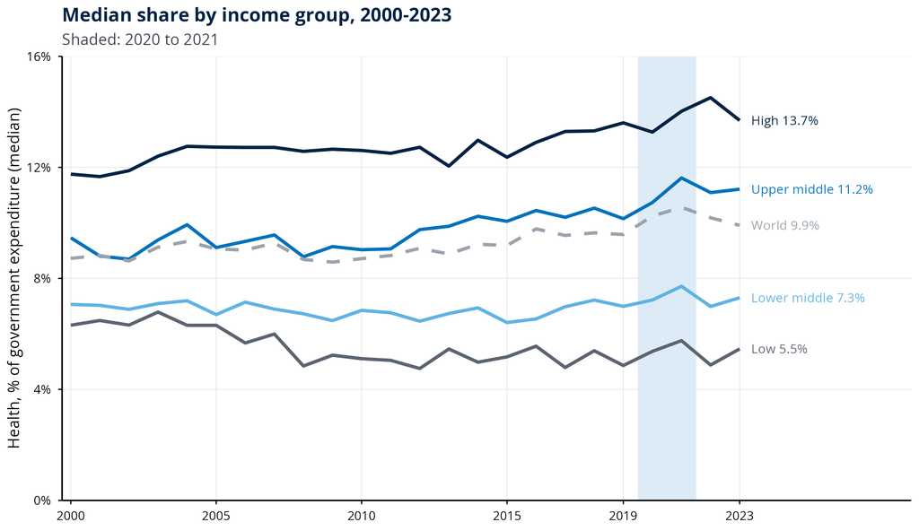

```r
line_order <- c("High income", "Upper middle income", "Lower middle income", "Low income", "World")
share_lines <- mine$trend |>
  filter(key %in% keys) |>
  mutate(
    group = if_else(key == "world", "World", INC_LABEL[key]),
    group = factor(group, levels = line_order)
  )
line_ends <- share_lines |>
  filter(year == 2023) |>
  mutate(
    group_short = sub(" income", "", group),
    label = paste0(group_short, " ", share_pct(med_slice))
  )
ggplot(share_lines, aes(year, med_slice, colour = group, linetype = group)) +
  annotate("rect", xmin = 2019.5, xmax = 2021.5, ymin = 0, ymax = 16, fill = WB[["tint"]]) +
  geom_line(linewidth = 1.1) +
  geom_text(
    data = line_ends, aes(x = 2023.4, label = label),
    hjust = 0, size = 3.2, show.legend = FALSE
  ) +
  scale_colour_manual(values = c(
    "High income" = WB[["navy"]], "Upper middle income" = WB[["blue"]],
    "Lower middle income" = WB[["sky"]], "Low income" = WB[["slate"]], World = WB[["grey"]]
  )) +
  scale_linetype_manual(values = c(
    "High income" = "solid", "Upper middle income" = "solid", "Lower middle income" = "solid",
    "Low income" = "solid", World = "dashed"
  )) +
  scale_x_continuous(
    breaks = c(2000, 2005, 2010, 2015, 2019, 2023), expand = expansion(add = c(0.3, 5.5))
  ) +
  scale_y_continuous(
    limits = c(0, 16), breaks = seq(0, 16, 4), labels = scales::label_percent(scale = 1),
    expand = c(0, 0)
  ) +
  labs(
    x = NULL, y = "Health, % of government expenditure (median)",
    title = "Median share by income group, 2000-2023", subtitle = "Shaded: 2020 to 2021"
  ) +
  theme(legend.position = "none")
```

## 10. Countries with sustained growth supported by public budgets

*Which countries combined rapid spending growth with sustained fiscal support for health?*

Illustrative cases are selected through common criteria rather than subjective country rankings. Eligible countries must be in the upper quartile of spending growth within their income group, derive at least half of their growth from the combined contributions of government size and health priority, record growth in both halves of the observation window, and have no identified data-quality flag. The results report the underlying growth rates and component contributions for each selected country.

These cases highlight spending trajectories that merit further investigation, particularly where growth has been sustained rather than concentrated in a single interval. They should not be interpreted as evidence of effective policy by themselves. Differences in baseline expenditure and the specific fiscal decisions behind these patterns require additional examination of national budget and policy records.

```r
## Slide 10: the instructive examples (thresholds by income group, the three
## parts, the total and the two halves).
win <- mine$win |>
  filter(!is.na(total)) |>
  left_join(short_names, by = "iso3")

# the 75th percentile of total growth in each income group, and the examples it gives
thresholds <- win |>
  group_by(income_group) |>
  summarise(
    threshold = quantile(total, 0.75, names = FALSE),
    examples = sum(example %in% TRUE)
  ) |>
  arrange(match(income_group, INC))
examples <- win |>
  filter(example %in% TRUE) |>
  arrange(match(income_group, INC), desc(total))

# The two halves of each window, such as "2013-18 / 2018-23". We print the most common pair once, in
# the third table, and any other pair after the country's name.
halves <- paste0(
  examples$y0, "-", substr(examples$mid, 3, 4), " / ", examples$mid, "-", substr(examples$y1, 3, 4)
)
halves_in_order <- factor(halves, levels = unique(halves))
halves_count <- table(halves_in_order)
common <- names(which.max(halves_count))
other_halves <- if_else(halves != common, paste0(" (", halves, ")"), "")
example_label <- paste0(examples$short, other_halves)
nepal <- filter(examples, iso3 == "NPL")
nepal_range <- paste(dollars(nepal$ghe0), "to", dollars(nepal$ghe1))

threshold_table <- tibble(
  `Income group` = unname(INC_LABEL),
  `75th percentile of total growth` = one_decimal(thresholds$threshold),
  Examples = thresholds$examples
)
example_table <- tibble(
  `Income group` = unname(INC_LABEL[examples$income_group]),
  Country = example_label,
  Economy = signed(examples$econ),
  `Size of government` = signed(examples$budget),
  `Health priority` = signed(examples$priority),
  Total = signed(examples$total),
  `By half of the window` = paste(signed(examples$half1), "/", signed(examples$half2))
)
also_printed <- tibble(
  Item = c(
    "Examples in all", "Most common half-windows",
    "Nepal, spending per person at the start and end of its window"
  ),
  Value = c(nrow(examples), common, nepal_range)
)
tables <- list(
  "The rule's thresholds and the count of examples by income group" = threshold_table,
  "Instructive examples, log points a year" = example_table,
  "Also printed on the slide" = also_printed
)
show_tables(tables)
```

The rule’s thresholds and the count of examples by income group

| Income group | 75th percentile of total growth | Examples |
| --- | --- | --- |
| Low income | 5.2 | 3 |
| Lower middle income | 4.8 | 6 |
| Upper middle income | 5.1 | 6 |
| High income | 4.2 | 5 |

Instructive examples, log points a year

| Income group | Country | Economy | Size of government | Health priority | Total | By half of the window |
| --- | --- | --- | --- | --- | --- | --- |
| Low income | Mali | +1.2 | +2.3 | +2.7 | +6.2 | +9.4 / +3.0 |
| Low income | Burkina Faso | +1.9 | +1.0 | +3.2 | +6.1 | +7.9 / +4.2 |
| Low income | DR Congo | +1.3 | +3.7 | +0.2 | +5.2 | +1.9 / +8.6 |
| Lower middle income | Nepal | +3.5 | +4.8 | +4.5 | +12.8 | +11.7 / +13.9 |
| Lower middle income | Côte d’Ivoire | +3.6 | +2.9 | +3.6 | +10.1 | +8.6 / +11.7 |
| Lower middle income | Philippines | +3.4 | +3.5 | +3.0 | +10.0 | +11.3 / +8.7 |
| Lower middle income | Morocco | +1.2 | +0.6 | +5.7 | +7.5 | +3.6 / +11.5 |
| Lower middle income | Zambia | +0.4 | +1.3 | +4.9 | +6.6 | +10.0 / +3.2 |
| Lower middle income | Pakistan | +1.9 | -0.1 | +3.7 | +5.4 | +10.7 / +0.2 |
| Upper middle income | Marshall Islands | +4.2 | +1.8 | +3.2 | +9.1 | +5.9 / +12.4 |
| Upper middle income | Indonesia | +3.2 | -1.0 | +6.7 | +8.9 | +14.6 / +3.2 |
| Upper middle income | Paraguay | +1.4 | +2.0 | +3.5 | +7.0 | +5.2 / +8.8 |
| Upper middle income | Montenegro | +3.0 | -1.3 | +4.4 | +6.1 | +4.4 / +7.8 |
| Upper middle income | Fiji | +2.1 | +1.5 | +2.2 | +5.8 | +9.7 / +1.9 |
| Upper middle income | Jamaica | +0.6 | +1.1 | +3.9 | +5.6 | +6.2 / +5.0 |
| High income | Singapore | +2.4 | +3.2 | +2.2 | +7.7 | +8.4 / +7.0 |
| High income | Saint Kitts and Nevis | +1.5 | +4.1 | +0.7 | +6.3 | +6.0 / +6.7 |
| High income | Korea, Rep. (2014-19 / 2019-24) | +2.2 | +0.9 | +2.8 | +5.9 | +7.7 / +4.1 |
| High income | Russian Federation | +1.1 | +0.4 | +4.0 | +5.5 | +0.3 / +10.7 |
| High income | Saudi Arabia | +0.6 | -0.9 | +4.5 | +4.2 | +5.2 / +3.2 |

Also printed on the slide

| Item | Value |
| --- | --- |
| Examples in all | 20 |
| Most common half-windows | 2013-18 / 2018-23 |
| Nepal, spending per person at the start and end of its window | US$7.3 to US$26.3 |

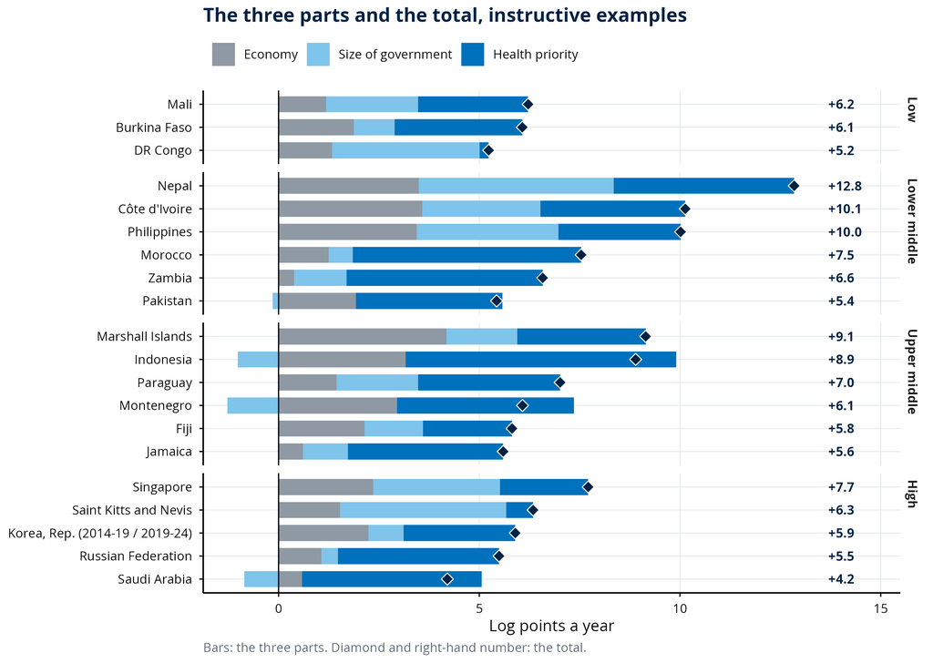

```r
# one panel per income group, named without the word "income"
income_panel <- sub(" income", "", INC_LABEL)
bars <- tibble(
  label = example_label,
  econ = examples$econ,
  budget = examples$budget,
  priority = examples$priority,
  total = examples$total,
  group = factor(income_panel[examples$income_group], levels = income_panel)
)
plot_parts(bars, "label", xlab = "Log points a year", facet = "group") +
  labs(title = "The three parts and the total, instructive examples")
```

## 11. Countries experiencing expenditure declines or erosion of health priority

*Where did government health spending fall, or where did declining health priority offset economic gains?*

Cases warranting closer examination are identified when real government health expenditure per capita declined or when a reduction in health’s budget share offset at least half of the positive contribution from economic growth. The offset measure expresses the negative contribution of health priority relative to the positive economic contribution. Countries meeting these criteria but carrying a data-quality flag are reported separately, because sudden breaks, shocks, unusual endpoints, or extreme expenditure levels may affect the estimated trend.

An important finding is that loss of health priority can be obscured by positive overall expenditure growth. Where GDP growth more than compensates for a declining health share, per-capita spending still rises. Assessing fiscal commitment to health therefore requires examining the composition of growth, not only its net direction.

```r
## Slide 11: the warning cases without a data flag (declines and priority offsets), and the
## flagged countries that meet the rule.
win <- mine$win |>
  filter(!is.na(total)) |>
  left_join(short_names, by = "iso3")

# A window other than 2013-2023 goes after the country's name. The offset is the share of the
# economy part that the fall in priority took away.
warn <- win |>
  filter(warning %in% TRUE) |>
  mutate(
    reason = if_else(total < 0, "Decline", "Offset"),
    other_window = if_else(y0 != 2013 | y1 != 2023, paste0(" (", y0, " to ", y1, ")"), ""),
    label = paste0(short, other_window)
  ) |>
  arrange(match(income_group, INC), reason != "Decline", total)
warn_table <- warn |>
  transmute(
    reason,
    Country = label,
    Inc. = unname(INC_CODE[income_group]),
    Economy = signed(econ),
    `Size of government` = signed(budget),
    `Health priority` = signed(priority),
    Total = signed(total),
    Offset = paste0(round(100 * -priority / econ), "%")
  )
declines <- warn_table |>
  filter(reason == "Decline") |>
  select(-reason, -Offset)
offsets <- warn_table |>
  filter(reason == "Offset") |>
  select(-reason)

# the countries that meet the rule but carry a data flag
flagged <- win |>
  filter(warning_rule %in% TRUE, !is.na(flag), nzchar(flag)) |>
  arrange(match(income_group, INC), total)

flagged_table <- tibble(
  `Income group` = unname(INC_LABEL[flagged$income_group]),
  Country = paste0(flagged$short, " (", flagged$flag, ")")
)
counts <- tibble(
  Item = c(
    "Warning cases without a flag", "Declines", "Offsets", "Flagged, listed apart",
    "Lower middle income: declines", "Lower middle income: offsets"
  ),
  Value = c(
    nrow(warn),
    nrow(declines),
    nrow(offsets),
    nrow(flagged),
    sum(warn$reason == "Decline" & warn$income_group == "lower_middle"),
    sum(warn$reason == "Offset" & warn$income_group == "lower_middle")
  )
)
tables <- list(
  "Spending per person fell" = declines,
  "Health priority offset at least half of the economy part" = offsets,
  "Meet the rule but carry a data flag" = flagged_table,
  "Counts on the slide" = counts
)
show_tables(tables)
```

Spending per person fell

| Country | Inc. | Economy | Size of government | Health priority | Total |
| --- | --- | --- | --- | --- | --- |
| Niger | Low | +1.8 | -2.6 | -0.6 | -1.4 |
| Ethiopia | Low | +5.1 | -5.0 | -0.9 | -0.7 |
| Togo | Low | +3.0 | +2.6 | -6.1 | -0.5 |
| Haiti | LM | -1.3 | -8.9 | +4.2 | -6.0 |
| Angola | LM | -2.8 | -5.4 | +2.5 | -5.7 |
| Jordan | LM | -1.4 | -0.2 | -2.2 | -3.9 |
| Kyrgyzstan | LM | +2.0 | -1.5 | -3.5 | -3.0 |
| Sao Tome and Principe | LM | +0.9 | -3.8 | +0.4 | -2.5 |
| Sri Lanka | LM | +0.6 | +1.6 | -4.7 | -2.5 |
| Honduras | LM | +1.4 | -1.2 | -2.3 | -2.1 |
| Benin | LM | +2.5 | +2.5 | -7.0 | -1.9 |
| Lesotho | LM | -1.1 | -1.7 | +1.2 | -1.6 |
| Djibouti | LM | +3.8 | -2.2 | -3.2 | -1.6 |
| Myanmar | LM | +1.4 | -1.2 | -0.5 | -0.3 |
| Algeria | UM | +0.3 | +1.1 | -6.4 | -5.0 |
| Turkmenistan | UM | -1.2 | -1.7 | -0.1 | -3.0 |
| Argentina | UM | -0.8 | +0.1 | -0.2 | -0.9 |
| Namibia | UM | -1.3 | -0.3 | +1.0 | -0.7 |
| Mexico | UM | +0.5 | +0.7 | -1.8 | -0.6 |
| Belize | UM | +0.4 | +0.4 | -1.2 | -0.5 |
| Barbados | High | +0.3 | -0.7 | -3.2 | -3.6 |
| Bahrain | High | +0.5 | -1.4 | 0.0 | -0.8 |
| Antigua and Barbuda | High | +1.2 | -1.0 | -0.8 | -0.5 |
| Qatar | High | -2.2 | -0.4 | +2.2 | -0.3 |
| Greece | High | +1.8 | -2.5 | +0.5 | -0.2 |

Health priority offset at least half of the economy part

| Country | Inc. | Economy | Size of government | Health priority | Total | Offset |
| --- | --- | --- | --- | --- | --- | --- |
| Uganda | Low | +1.6 | +3.6 | -4.1 | +1.0 | 259% |
| Gambia | Low | +1.3 | +3.3 | -1.4 | +3.1 | 111% |
| Sierra Leone | Low | +0.5 | +4.4 | -1.4 | +3.5 | 260% |
| Tanzania | LM | +2.7 | 0.0 | -2.1 | +0.6 | 77% |
| Tunisia | LM | 0.0 | +1.5 | -0.3 | +1.2 | 1170% |
| Eswatini | LM | +1.7 | +0.5 | -0.9 | +1.3 | 55% |
| Bangladesh | LM | +5.4 | +0.5 | -3.8 | +2.1 | 71% |
| Senegal | LM | +2.4 | +4.1 | -3.9 | +2.6 | 163% |
| Costa Rica | UM | +2.5 | 0.0 | -1.7 | +0.8 | 67% |
| Dominica | UM | +1.0 | +6.7 | -6.5 | +1.2 | 653% |
| Tonga | UM | +1.7 | +3.4 | -1.4 | +3.8 | 80% |
| St. Vincent and the Grenadines | UM | +2.7 | +2.8 | -1.4 | +4.1 | 51% |
| Monaco | High | +3.6 | +1.7 | -5.0 | +0.3 | 140% |
| Italy | High | +1.2 | +0.5 | -1.3 | +0.4 | 108% |
| Canada (2014 to 2024) | High | +0.6 | +1.5 | -0.7 | +1.5 | 108% |

Meet the rule but carry a data flag

| Income group | Country |
| --- | --- |
| Low income | South Sudan (E) |
| Low income | Syria (E) |
| Low income | Sudan (B S) |
| Low income | Yemen (S E) |
| Low income | Afghanistan (B L) |
| Low income | Malawi (E) |
| Low income | Burundi (B) |
| Low income | Madagascar (B) |
| Lower middle income | Lebanon (B S E) |
| Lower middle income | Zimbabwe (B S) |
| Lower middle income | Congo (B) |
| Upper middle income | Venezuela (B S E) |
| Upper middle income | Equatorial Guinea (E) |
| High income | San Marino (B) |
| High income | Niue (L) |
| High income | Bahamas (S) |

Counts on the slide

| Item | Value |
| --- | --- |
| Warning cases without a flag | 40 |
| Declines | 25 |
| Offsets | 15 |
| Flagged, listed apart | 16 |
| Lower middle income: declines | 11 |
| Lower middle income: offsets | 5 |

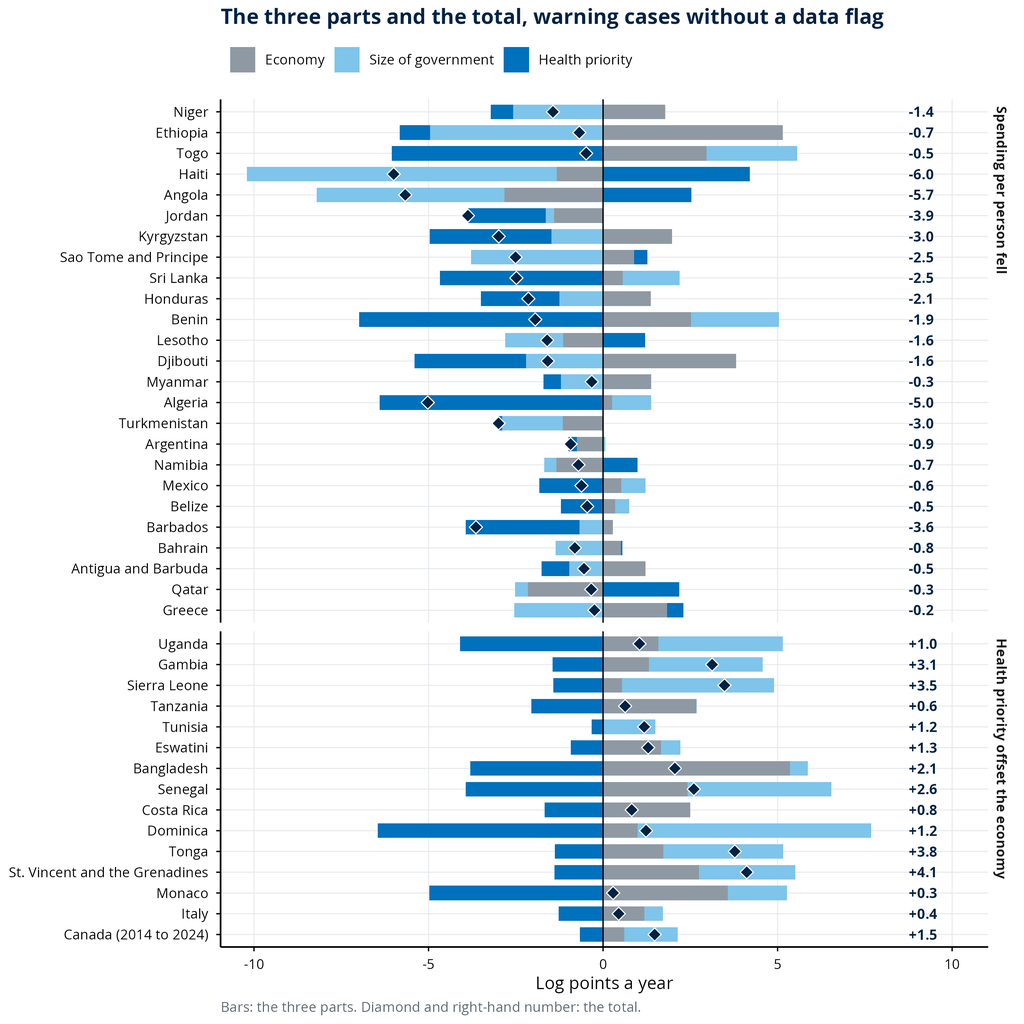

```r
panel_names <- c(
  Decline = "Spending per person fell",
  Offset = "Health priority offset the economy"
)
bars <- tibble(
  label = warn$label,
  econ = warn$econ,
  budget = warn$budget,
  priority = warn$priority,
  total = warn$total,
  group = factor(panel_names[warn$reason], levels = panel_names)
)
plot_parts(bars, "label", xlab = "Log points a year", facet = "group") +
  labs(title = "The three parts and the total, warning cases without a data flag")
```

## 12. Interpretation and data limitations

*What can and cannot be concluded from an expenditure decomposition?*

Several considerations qualify the interpretation of these results. First, the decomposition is an accounting identity, not a causal model; its components can also move mechanically in opposite directions, as when falling GDP raises government expenditure as a share of GDP. Second, constant-price comparisons depend on price and currency conversions that may be volatile during periods of high inflation or exchange-rate adjustment. Third, changes in statistical classification or accounting practices can create apparent breaks in expenditure shares. GHED’s domestic government health expenditure series also excludes certain externally financed resources.

Group medians must be distinguished from aggregates dominated by large member countries. Results can also be sensitive to the endpoints selected and to the operational criteria used to identify examples and cases warranting further scrutiny. The accompanying quality indicators describe the frequency of potential breaks, shocks, extreme endpoints, and unusual expenditure levels; coverage information identifies the countries with incomplete observation windows.

```r
## Slide 12: data flags by income group and by rule, windows ending in 2024, countries without a
## window, and the largest member of each income group.
win <- mine$win |>
  filter(!is.na(total)) |>
  mutate(any_flag = !is.na(flag) & nzchar(flag))
flags_by_income <- win |>
  group_by(income_group) |>
  summarise(countries = n(), flagged = sum(any_flag)) |>
  arrange(match(income_group, INC))

# the largest member of each income group and its share of the group's spending in 2023
largest <- mine$contrib |>
  filter(income_group %in% INC) |>
  group_by(income_group) |>
  mutate(share = 100 * ghe1_musd / sum(ghe1_musd)) |>
  slice_max(ghe1_musd, n = 1, with_ties = FALSE) |>
  ungroup() |>
  arrange(match(income_group, INC)) |>
  left_join(short_names, by = "iso3") |>
  transmute(
    `Income group` = unname(INC_LABEL[income_group]),
    `Largest member` = short,
    `Share of the group's spending, 2023` = whole_pct(share)
  )

# windows ending in 2024 and countries without a window, by their full names
names_2024 <- win$name[win$note_2024 %in% TRUE]
names_without_window <- mine$win$name[is.na(mine$win$total)]

flag_table <- tibble(
  `Income group` = unname(INC_LABEL),
  Flagged = flags_by_income$flagged,
  Countries = flags_by_income$countries,
  Share = whole_pct(100 * flags_by_income$flagged / flags_by_income$countries)
)
rule_table <- tibble(
  Flag = c("B", "S", "E", "L", "Any"),
  Rule = c(
    "Break: a budget share doubles or halves in one year",
    "Shock: real GDP per person up 25% or down 20% in one year",
    "Extreme end: a share at either end over twice or under half its window median",
    "Level: government spending over 100% of GDP, or health spending under US$1 a person",
    "At least one flag"
  ),
  Countries = c(
    sum(grepl("B", win$flag)), sum(grepl("S", win$flag)), sum(grepl("E", win$flag)),
    sum(grepl("L", win$flag)), sum(win$any_flag)
  )
)
window_table <- tibble(
  Item = c("Countries with a window", "Windows ending in 2024", "No window"),
  Value = c(
    nrow(win),
    knitr::combine_words(names_2024, oxford_comma = FALSE),
    knitr::combine_words(names_without_window, oxford_comma = FALSE)
  )
)
tables <- list(
  "Countries whose window carries a data flag, by income group" = flag_table,
  "Flag rules, inside each country's window" = rule_table,
  "Windows and members" = window_table,
  "Largest member of each income group" = largest
)
show_tables(tables)
```

Countries whose window carries a data flag, by income group

| Income group | Flagged | Countries | Share |
| --- | --- | --- | --- |
| Low income | 11 | 25 | 44% |
| Lower middle income | 9 | 51 | 18% |
| Upper middle income | 8 | 53 | 15% |
| High income | 7 | 65 | 11% |

Flag rules, inside each country’s window

| Flag | Rule | Countries |
| --- | --- | --- |
| B | Break: a budget share doubles or halves in one year | 15 |
| S | Shock: real GDP per person up 25% or down 20% in one year | 16 |
| E | Extreme end: a share at either end over twice or under half its window median | 11 |
| L | Level: government spending over 100% of GDP, or health spending under US$1 a person | 5 |
| Any | At least one flag | 35 |

Windows and members

| Item | Value |
| --- | --- |
| Countries with a window | 194 |
| Windows ending in 2024 | Canada, Chile, Colombia, Denmark, France, Republic of Korea and Luxembourg |
| No window | Cuba |

Largest member of each income group

| Income group | Largest member | Share of the group’s spending, 2023 |
| --- | --- | --- |
| Low income | Ethiopia | 19% |
| Lower middle income | India | 44% |
| Upper middle income | China | 61% |
| High income | United States | 47% |

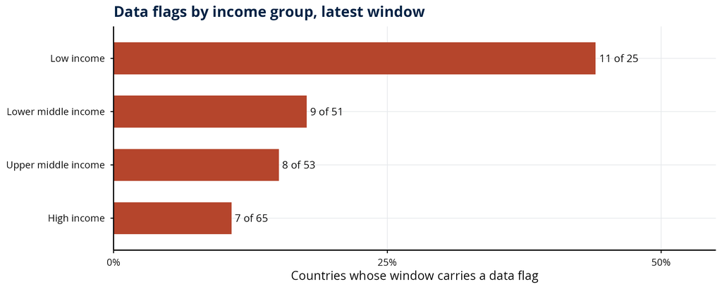

```r
flag_share <- tibble(
  group = factor(INC_LABEL, levels = rev(INC_LABEL)),
  pct = 100 * flags_by_income$flagged / flags_by_income$countries,
  label = paste(flags_by_income$flagged, "of", flags_by_income$countries)
)
ggplot(flag_share, aes(x = pct, y = group)) +
  geom_col(fill = WB[["rust"]], width = 0.6) +
  geom_text(aes(label = label), hjust = -0.1, size = 3.3) +
  scale_x_continuous(
    limits = c(0, 55), breaks = c(0, 25, 50), labels = scales::label_percent(scale = 1),
    expand = c(0, 0)
  ) +
  labs(
    x = "Countries whose window carries a data flag", y = NULL,
    title = "Data flags by income group, latest window"
  )
```

# Part II. Fiscal space for government health expenditure, 2027-2029

## 13. Translating fiscal projections into health budget scenarios

*What additional resources could be allocated to health as government budgets evolve?*

The forward-looking framework distinguishes three amounts: the **protect amount**, which maintains health’s existing budget share; the **upper ask**, which applies more ambitious but bounded changes in health’s share; and the **ceiling**, representing the total projected increase in government expenditure. Together, they provide a transparent starting point for budget discussions, not a substitute for country-specific expenditure planning or a normative spending target.

## 14. Illustrating the framework: Kenya, 2024-2029

*How do macroeconomic projections translate into a potential increase in Kenya’s health budget?*

Kenya illustrates the interaction between GDP growth, the projected government-expenditure envelope, and alternative allocations to health. The analysis uses IMF projections of GDP and government expenditure and compares the IMF spending path with a scenario that keeps government expenditure at a constant share of GDP. Values are initially expressed in billions of Kenyan shillings at current prices.

The protect amount preserves the health share assumed for 2026, based on the latest available observation. The ceiling is the increase in total government expenditure above its 2026 level. The upper ask is determined by the largest eligible increase in health’s budget share: Kenya’s historical trend is positive, but the fixed increase of 0.75 percentage points per year produces the larger eligible amount. Because the 2025-2026 health share is carried forward rather than directly observed, subsequent results should be read as conditional projections, not approved budgets.

```r
## Slide 14: Kenya, the method drawn from 2024 to 2029 (GDP, government spending on both paths, the
## health budget at the protect amount and on the upper-ask path), KES billion at current prices.
kenya_lines <- mine$rx_lines |>
  filter(iso3 == "KEN") |>
  arrange(year)
kenya_imf <- filter(kenya_lines, variant == "imf")
kenya_flat <- filter(kenya_lines, variant == "flat")
kenya <- mine$rx |>
  filter(iso3 == "KEN", variant == "imf") |>
  arrange(year) # 2027, 2028 and 2029
kenya_2029 <- filter(kenya, year == 2029)
imf_2029 <- filter(kenya_imf, year == 2029)
flat_2029 <- filter(kenya_flat, year == 2029)

kenya_table <- tibble(
  Item = c(
    "Ceiling, 2026 to 2029", "Health's share of government spending, %", "Protect amount, 2029",
    "Upper ask, 2029", "Upper ask, % of the ceiling", "GDP, 2029",
    "Government spending, 2029, IMF path", "Government spending, 2029, flat share",
    "Health budget at the upper ask, 2029", "Health budget at the protect amount, 2029"
  ),
  Value = c(
    one_decimal(kenya_2029$d_all / 1e9),
    one_decimal(kenya_2029$h),
    one_decimal(kenya_2029$d_protect / 1e9),
    one_decimal(kenya_2029$ask / 1e9),
    whole_pct(kenya_2029$ask_share_of_ceiling_nominal),
    one_decimal(imf_2029$gdp / 1e9),
    one_decimal(imf_2029$gge / 1e9),
    one_decimal(flat_2029$gge / 1e9),
    one_decimal((kenya_2029$health26 + kenya_2029$ask) / 1e9),
    one_decimal(imf_2029$health_protect / 1e9)
  )
)
tables <- list("Kenya, KES billion at current prices, IMF path" = kenya_table)
show_tables(tables)
```

Kenya, KES billion at current prices, IMF path

| Item | Value |
| --- | --- |
| Ceiling, 2026 to 2029 | 1,303.4 |
| Health’s share of government spending, % | 8.7 |
| Protect amount, 2029 | 112.8 |
| Upper ask, 2029 | 246.8 |
| Upper ask, % of the ceiling | 19% |
| GDP, 2029 | 26,119.1 |
| Government spending, 2029, IMF path | 5,959.4 |
| Government spending, 2029, flat share | 6,222.0 |
| Health budget at the upper ask, 2029 | 649.6 |
| Health budget at the protect amount, 2029 | 515.6 |

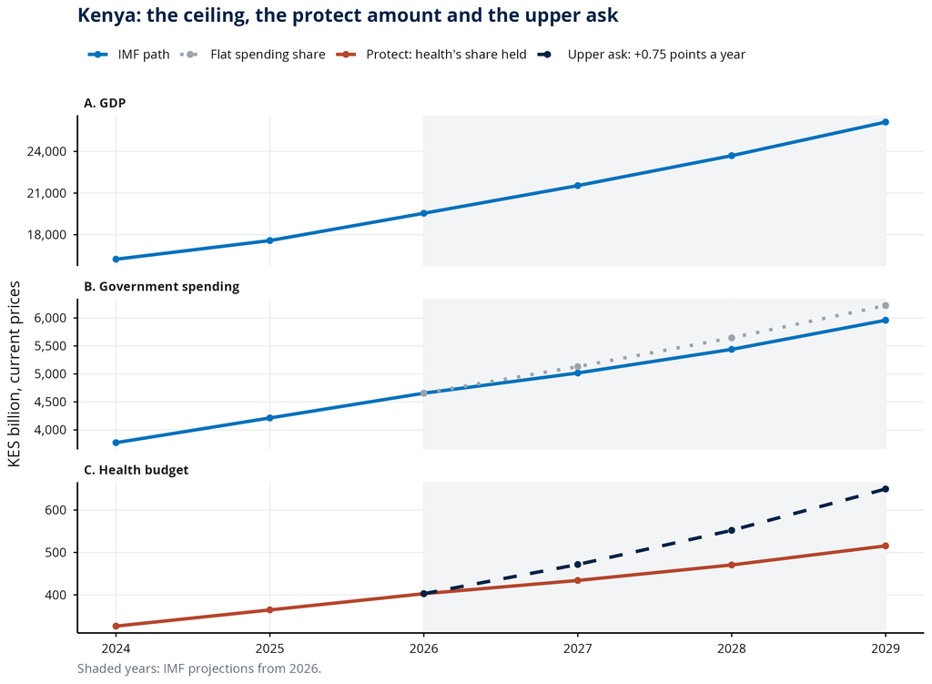

```r
# Three panels: GDP, government spending on both paths, and the health budget at the
# protect amount and on the upper-ask path
upper_ask <- tibble(
  year = 2026:2029,
  v = c(kenya_2029$health26, kenya$health26 + kenya$ask)
)
flat_from_2026 <- filter(kenya_flat, year >= 2026)
line_names <- c(
  "IMF path", "Flat spending share", "Protect: health's share held",
  "Upper ask: +0.75 points a year"
)
kenya_long <- bind_rows(
  tibble(panel = "A. GDP", year = kenya_imf$year, v = kenya_imf$gdp / 1e9, line = line_names[1]),
  tibble(
    panel = "B. Government spending", year = kenya_imf$year, v = kenya_imf$gge / 1e9,
    line = line_names[1]
  ),
  tibble(
    panel = "B. Government spending", year = flat_from_2026$year, v = flat_from_2026$gge / 1e9,
    line = line_names[2]
  ),
  tibble(
    panel = "C. Health budget", year = kenya_imf$year, v = kenya_imf$health_protect / 1e9,
    line = line_names[3]
  ),
  tibble(
    panel = "C. Health budget", year = upper_ask$year, v = upper_ask$v / 1e9,
    line = line_names[4]
  )
) |>
  mutate(line = factor(line, levels = line_names))
ggplot(kenya_long, aes(year, v, colour = line, linetype = line)) +
  annotate("rect", xmin = 2026, xmax = 2029, ymin = -Inf, ymax = Inf, fill = "#f2f4f6") +
  geom_line(linewidth = 1.1) +
  geom_point(size = 1.6) +
  facet_wrap(~panel, ncol = 1, scales = "free_y") +
  scale_colour_manual(
    values = setNames(c(WB[["blue"]], WB[["grey"]], WB[["rust"]], WB[["navy"]]), line_names)
  ) +
  scale_linetype_manual(values = setNames(c("solid", "dotted", "solid", "dashed"), line_names)) +
  scale_y_continuous(labels = scales::label_comma()) +
  scale_x_continuous(breaks = 2024:2029) +
  labs(
    x = NULL, y = "KES billion, current prices",
    title = "Kenya: the ceiling, the protect amount and the upper ask",
    caption = "Shaded years: IMF projections from 2026."
  )
```

## 15. Fiscal space for health by income group in 2029

*How do the protect amount, upper ask, and fiscal ceiling differ across income levels?*

The comparison reports median country-level increases in 2029 relative to the 2026 baseline under the IMF expenditure path. Estimates are expressed in real terms, both as percentages of the 2026 health budget and as increases in constant-2026 US dollars per capita. Each median is calculated independently; the upper-ask summary includes only countries for which the framework applies.

The ceiling can be much larger than the protect amount when health accounts for only a small share of government expenditure. For example, at a health share of 5%, the ceiling is twenty times the protect amount, compared with roughly seven times at a 15% share. This arithmetic explains why the ceiling may appear very large in percentage terms even where the absolute additional resources available per person remain limited, particularly in low-income countries. It should not be interpreted as an attainable health allocation.

```r
## Slide 15: median protect amount, upper ask and ceiling in 2029 (IMF path, real), by
## income group, in per cent of the 2026 health budget and in constant 2026 US$ per person;
## and the regional values the slide quotes.
groups_2029 <- filter(mine$rx_grp, variant == "imf", year == 2029)
income_2029 <- groups_2029 |>
  filter(key %in% c("world", INC)) |>
  arrange(match(key, c("world", INC)))
group_names <- c("World", unname(INC_LABEL))
south_asia <- filter(groups_2029, key == "South Asia")
africa <- filter(groups_2029, key == "Sub-Saharan Africa")

median_table <- tibble(
  Group = group_names,
  n = income_2029$n,
  `Protect, %` = share_pct(income_2029$med_d_protect_pct),
  `Upper ask, %` = share_pct(income_2029$med_ask_pct),
  `Ceiling, %` = whole_pct(income_2029$med_d_all_pct),
  `Protect, US$ per person` = dollars(income_2029$med_d_protect_usd_pp),
  `Upper ask, US$ per person` = dollars(income_2029$med_ask_usd_pp),
  `Ceiling, US$ per person` = dollars(income_2029$med_d_all_usd_pp),
  `Upper ask, % of the real ceiling` = whole_pct(income_2029$med_ask_share_of_ceiling)
)
also_printed <- tibble(
  Item = c(
    "Ceiling as a multiple of the protect amount at a 15% share", "South Asia: ceiling",
    "Sub-Saharan Africa: ceiling", "Sub-Saharan Africa: upper ask",
    "Sub-Saharan Africa: upper ask per person"
  ),
  Value = c(
    round(100 / 15),
    whole_pct(south_asia$med_d_all_pct),
    whole_pct(africa$med_d_all_pct),
    share_pct(africa$med_ask_pct),
    dollars(africa$med_ask_usd_pp)
  )
)
tables <- list(
  "Median country, 2029, IMF path, real increase over 2026" = median_table,
  "Also printed on the slide" = also_printed
)
show_tables(tables)
```

Median country, 2029, IMF path, real increase over 2026

| Group | n | Protect, % | Upper ask, % | Ceiling, % | Protect, US$ per person | Upper ask, US$ per person | Ceiling, US$ per person | Upper ask, % of the real ceiling |
| --- | --- | --- | --- | --- | --- | --- | --- | --- |
| World | 183 | 6.8% | 31.0% | 58% | US$16.2 | US$101 | US$156 | 42% |
| Low income | 22 | 17.0% | 63.3% | 201% | US$1.1 | US$6.6 | US$24.0 | 24% |
| Lower middle income | 48 | 10.6% | 49.6% | 124% | US$3.2 | US$23.4 | US$66.9 | 25% |
| Upper middle income | 51 | 6.4% | 27.7% | 60% | US$18.6 | US$102 | US$197 | 42% |
| High income | 62 | 5.4% | 22.0% | 36% | US$136 | US$579 | US$896 | 58% |

Also printed on the slide

| Item | Value |
| --- | --- |
| Ceiling as a multiple of the protect amount at a 15% share | 7 |
| South Asia: ceiling | 367% |
| Sub-Saharan Africa: ceiling | 171% |
| Sub-Saharan Africa: upper ask | 53.5% |
| Sub-Saharan Africa: upper ask per person | US$11.0 |

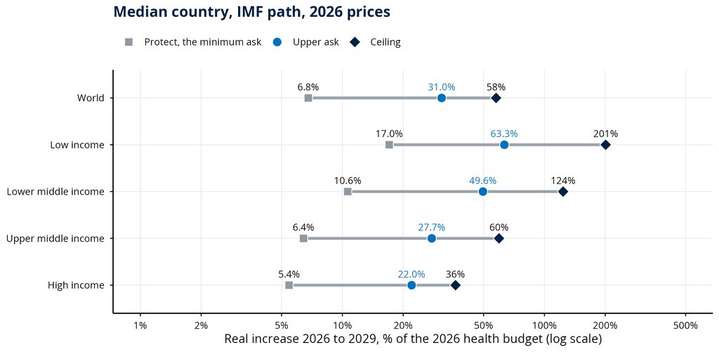

```r
# a dot for each amount on a log scale, joined from the protect amount to the ceiling
amount_names <- c("Protect, the minimum ask", "Upper ask", "Ceiling")
dots <- bind_rows(
  tibble(
    group = group_names, v = income_2029$med_d_protect_pct, what = amount_names[1],
    label = share_pct(income_2029$med_d_protect_pct)
  ),
  tibble(
    group = group_names, v = income_2029$med_ask_pct, what = amount_names[2],
    label = share_pct(income_2029$med_ask_pct)
  ),
  tibble(
    group = group_names, v = income_2029$med_d_all_pct, what = amount_names[3],
    label = whole_pct(income_2029$med_d_all_pct)
  )
) |>
  mutate(
    group = factor(group, levels = rev(group_names)),
    what = factor(what, levels = amount_names)
  )
ranges <- tibble(
  group = factor(group_names, levels = rev(group_names)),
  from = income_2029$med_d_protect_pct,
  to = income_2029$med_d_all_pct
)
ggplot(dots, aes(x = v, y = group)) +
  geom_segment(
    data = ranges, aes(x = from, xend = to, y = group, yend = group),
    colour = WB[["grey"]], linewidth = 1.2
  ) +
  geom_point(aes(shape = what, fill = what), size = 3.6, colour = "white") +
  geom_text(aes(label = label, colour = what), vjust = -1.1, size = 3.1, show.legend = FALSE) +
  scale_x_log10(
    limits = c(1, 500), breaks = c(1, 2, 5, 10, 20, 50, 100, 200, 500),
    labels = scales::label_percent(scale = 1)
  ) +
  scale_shape_manual(values = c(22, 21, 23)) +
  scale_fill_manual(values = setNames(c("#8f99a3", WB[["blue"]], WB[["navy"]]), amount_names)) +
  scale_colour_manual(values = setNames(c("black", WB[["blue"]], "black"), amount_names)) +
  labs(
    x = "Real increase 2026 to 2029, % of the 2026 health budget (log scale)", y = NULL,
    title = "Median country, IMF path, 2026 prices"
  )
```

## 16. Countries facing a constrained or contracting fiscal envelope

*Where do projected budgets leave no positive nominal fiscal space for the proposed allocation framework?*

The framework requires total nominal government expenditure to exceed its 2026 baseline. When the budget is unchanged or contracting, there is no positive incremental envelope on which to apply the protect and upper-ask rules. The analysis identifies these countries under both expenditure paths and distinguishes nominal expansion from real purchasing-power gains. It also identifies cases where the proposed real upper ask exceeds the real growth of government expenditure.

Under the IMF path, many inapplicable cases reflect a projected reduction in government expenditure relative to GDP rather than a contraction in nominal GDP itself. Holding the government-expenditure share of GDP constant substantially reduces the number of such cases, leaving three countries where nominal GDP is projected to decline. This sensitivity underscores the influence of fiscal-policy assumptions on estimates of prospective resources for health.

```r
## Slide 16: countries where the method does not apply (government spending does not grow), where
## the budget falls in real terms only, and where the upper ask exceeds real budget growth; and the
## list of countries without budget growth.
world_rx <- filter(mine$rx_grp, key == "world")
world_imf <- world_rx |>
  filter(variant == "imf") |>
  arrange(year)
world_flat <- world_rx |>
  filter(variant == "flat") |>
  arrange(year)

# Every country with IMF projections in which government spending does not grow in at least one
# year, on either path. The deck's builder sorts these names by code point, as arrange() does.
with_projections <- filter(mine$rx, has_data %in% TRUE)
no_growth <- with_projections |>
  filter(!(applies %in% TRUE)) |>
  arrange(year) |>
  group_by(iso3, name, income_group) |>
  summarise(
    imf = paste(year[variant == "imf"], collapse = ", "),
    flat = paste(year[variant == "flat"], collapse = ", "),
    n_imf = sum(variant == "imf"),
    n_flat = sum(variant == "flat"),
    .groups = "drop"
  ) |>
  mutate(
    imf = if_else(n_imf > 0, imf, "-"),
    flat = if_else(n_flat > 0, flat, "-")
  ) |>
  arrange(name) |>
  left_join(short_names, by = "iso3")
ask_above <- with_projections |>
  filter(variant == "imf", ask_above_real_ceiling %in% TRUE) |>
  distinct(iso3) |>
  nrow()
flat_names <- no_growth$name[no_growth$n_flat > 0]

by_year <- tibble(
  Year = 2027:2029,
  `Does not apply, IMF path` = world_imf$n_not_applies,
  `Falls in real terms only, IMF path` = world_imf$n_real_fall_only,
  `Does not apply, flat share` = world_flat$n_not_applies,
  `Upper ask above real budget growth, IMF path` = world_imf$n_ask_above_real_ceiling,
  `Countries with IMF projections` = world_imf$n
)
across_years <- tibble(
  Item = c(
    "Does not apply in at least one year, IMF path", "Does not apply, flat share",
    "Upper ask above real budget growth in at least one year, IMF path"
  ),
  Value = c(
    sum(no_growth$n_imf > 0),
    knitr::combine_words(flat_names, oxford_comma = FALSE),
    ask_above
  )
)
no_growth_table <- tibble(
  Country = no_growth$short,
  Inc. = unname(INC_CODE[no_growth$income_group]),
  `IMF path` = no_growth$imf,
  `Flat share` = no_growth$flat
)
tables <- list(
  "Countries by year" = by_year,
  "Counts across the three years" = across_years,
  "Years in which government spending does not grow" = no_growth_table
)
show_tables(tables)
```

Countries by year

| Year | Does not apply, IMF path | Falls in real terms only, IMF path | Does not apply, flat share | Upper ask above real budget growth, IMF path | Countries with IMF projections |
| --- | --- | --- | --- | --- | --- |
| 2027 | 11 | 30 | 3 | 25 | 183 |
| 2028 | 8 | 27 | 3 | 25 | 183 |
| 2029 | 7 | 14 | 2 | 26 | 183 |

Counts across the three years

| Item | Value |
| --- | --- |
| Does not apply in at least one year, IMF path | 14 |
| Does not apply, flat share | Brunei Darussalam, Congo and Equatorial Guinea |
| Upper ask above real budget growth in at least one year, IMF path | 48 |

Years in which government spending does not grow

| Country | Inc. | IMF path | Flat share |
| --- | --- | --- | --- |
| Barbados | High | 2027 | - |
| Brunei Darussalam | High | - | 2027, 2028, 2029 |
| Comoros | LM | 2027, 2028 | - |
| Congo | LM | - | 2027, 2028 |
| Dominica | UM | 2027, 2028, 2029 | - |
| Equatorial Guinea | UM | 2027, 2028 | 2027, 2028, 2029 |
| Grenada | UM | 2027, 2028, 2029 | - |
| Kiribati | LM | 2027, 2028, 2029 | - |
| Liberia | Low | 2027 | - |
| Maldives | UM | 2027 | - |
| Oman | High | 2028, 2029 | - |
| Papua New Guinea | LM | 2027 | - |
| Sao Tome and Principe | LM | 2029 | - |
| Somalia | Low | 2027 | - |
| Tuvalu | UM | 2028, 2029 | - |
| Ukraine | UM | 2027, 2028, 2029 | - |

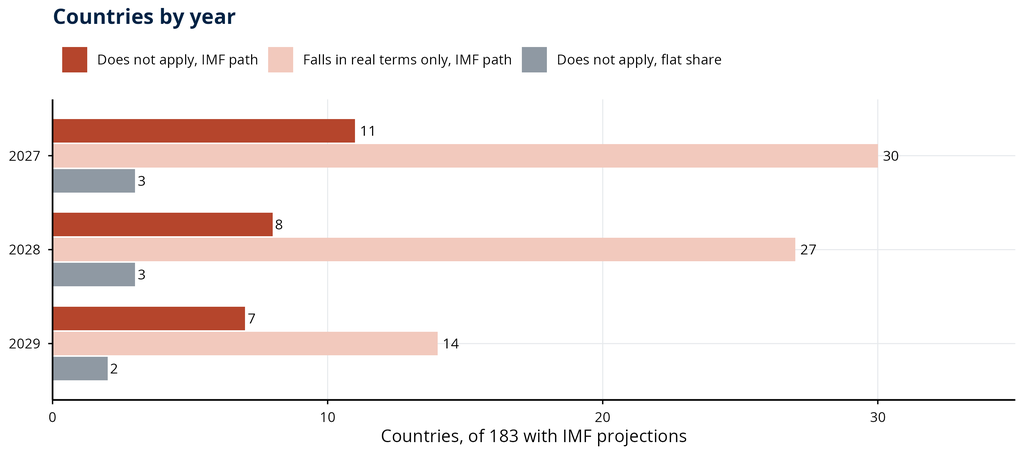

```r
series <- c(
  "Does not apply, IMF path", "Falls in real terms only, IMF path", "Does not apply, flat share"
)
counts_by_year <- tibble(
  year = factor(rep(2027:2029, 3), levels = 2029:2027),
  series = factor(rep(series, each = 3), levels = rev(series)),
  v = c(world_imf$n_not_applies, world_imf$n_real_fall_only, world_flat$n_not_applies)
)
ggplot(counts_by_year, aes(x = v, y = year, fill = series)) +
  geom_col(position = position_dodge(width = 0.8), width = 0.75) +
  geom_text(aes(label = v), position = position_dodge(width = 0.8), hjust = -0.3, size = 3.2) +
  scale_fill_manual(
    values = setNames(c(WB[["rust"]], WB[["rosy"]], "#8f99a3"), series),
    breaks = series
  ) +
  scale_x_continuous(limits = c(0, 35), expand = c(0, 0)) +
  labs(
    x = paste("Countries, of", world_imf$n[world_imf$year == 2029], "with IMF projections"),
    y = NULL, title = "Countries by year"
  )
```

## 17. What determines the upper-ask scenario?

*How do historical improvements in health priority compare with standard increases in the budget share?*

The upper ask is selected from positive historical trends in health’s share of government expenditure and fixed annual increases of 0.25, 0.50, or 0.75 percentage points, provided the resulting amounts remain between the protect amount and the ceiling. The analysis identifies the scenario that sets the upper ask in each year and describes the distribution of historical health-share changes across income groups.

Only one country experienced an annual increase in health’s budget share above 0.75 percentage points during its latest observation window. Consequently, the 0.75-percentage-point scenario determines the upper ask for nearly all eligible cases. Although expressed as a uniform absolute change, this assumption represents a substantially larger proportional increase for countries starting from a low health budget share. It is therefore best regarded as an illustrative ambition scenario rather than a universal policy recommendation.

```r
## Slide 17: which candidate set the upper ask in each year (IMF path), the own trend in health's
## share by band and income group, and the upper ask as a share of the real ceiling.
SETTERS <- c(
  "075" = "+0.75 a year", "050" = "+0.5 a year", "025" = "+0.25 a year", trend = "Own trend",
  none = "None admissible"
)
world_imf <- mine$rx_grp |>
  filter(key == "world", variant == "imf") |>
  arrange(year)
groups_2029 <- filter(mine$rx_grp, variant == "imf", year == 2029)

# the own trend in health's share is the same in every year, so one
# year (2027) gives one row per country
rows_2027 <- filter(mine$rx, variant == "imf", year == 2027)
trends <- rows_2027$trend[!is.na(rows_2027$trend)]
trend_rows <- bind_rows(
  mutate(rows_2027, Countries = "World"),
  mutate(rows_2027, Countries = unname(INC_LABEL[income_group]))
)
bands <- trend_rows |>
  filter(!is.na(trend)) |>
  group_by(Countries) |>
  summarise(
    `Fell or flat` = sum(trend <= 0),
    `Up to 0.25` = sum(trend > 0 & trend <= 0.25),
    `0.25 to 0.5` = sum(trend > 0.25 & trend <= 0.5),
    `0.5 to 0.75` = sum(trend > 0.5 & trend <= 0.75),
    `Above 0.75` = sum(trend > 0.75),
    n = n()
  ) |>
  arrange(match(Countries, c("World", INC_LABEL)))

setter_table <- tibble(
  Year = 2027:2029,
  `+0.75 a year` = world_imf$set_075,
  `+0.5 a year` = world_imf$set_050,
  `+0.25 a year` = world_imf$set_025,
  `Own trend` = world_imf$set_trend,
  `None admissible` = world_imf$set_none,
  `Method applies` = world_imf$n_applies
)
also_printed <- tibble(
  Item = c(
    "Median trend, points a year", "Middle half, from", "Middle half, to",
    "Upper ask, % of the real ceiling, 2029: world", "low income", "high income"
  ),
  Value = c(
    signed(median(trends)),
    one_decimal(quantile(trends, 0.25, names = FALSE)),
    signed(quantile(trends, 0.75, names = FALSE)),
    whole_pct(world_imf$med_ask_share_of_ceiling[world_imf$year == 2029]),
    whole_pct(groups_2029$med_ask_share_of_ceiling[groups_2029$key == "low"]),
    whole_pct(groups_2029$med_ask_share_of_ceiling[groups_2029$key == "high"])
  )
)
tables <- list(
  "Candidate that set the upper ask, IMF path (countries where the method applies)" = setter_table,
  "Own trend in health's share, points a year, latest decade" = bands,
  "Also printed on the slide" = also_printed
)
show_tables(tables)
```

Candidate that set the upper ask, IMF path (countries where the method applies)

| Year | +0.75 a year | +0.5 a year | +0.25 a year | Own trend | None admissible | Method applies |
| --- | --- | --- | --- | --- | --- | --- |
| 2027 | 168 | 2 | 0 | 2 | 0 | 172 |
| 2028 | 169 | 0 | 2 | 2 | 2 | 175 |
| 2029 | 174 | 0 | 0 | 2 | 0 | 176 |

Own trend in health’s share, points a year, latest decade

| Countries | Fell or flat | Up to 0.25 | 0.25 to 0.5 | 0.5 to 0.75 | Above 0.75 | n |
| --- | --- | --- | --- | --- | --- | --- |
| World | 59 | 83 | 43 | 8 | 1 | 194 |
| Low income | 12 | 11 | 2 | 0 | 0 | 25 |
| Lower middle income | 18 | 22 | 10 | 1 | 0 | 51 |
| Upper middle income | 17 | 15 | 17 | 4 | 0 | 53 |
| High income | 12 | 35 | 14 | 3 | 1 | 65 |

Also printed on the slide

| Item | Value |
| --- | --- |
| Median trend, points a year | +0.1 |
| Middle half, from | 0.0 |
| Middle half, to | +0.3 |
| Upper ask, % of the real ceiling, 2029: world | 42% |
| low income | 24% |
| high income | 58% |

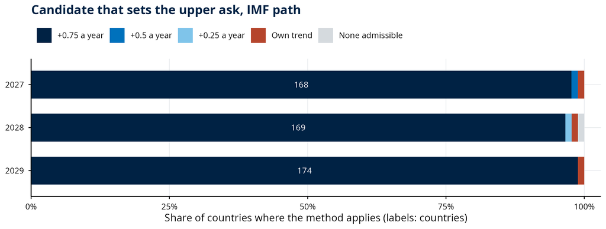

```r
# the count of each candidate in each year, as a share of the countries where the method applies
set_by <- world_imf |>
  select(
    year,
    total = n_applies, `075` = set_075, `050` = set_050, `025` = set_025, trend = set_trend,
    none = set_none
  ) |>
  pivot_longer(-c(year, total), names_to = "setter", values_to = "n") |>
  mutate(
    year = factor(year, levels = 2029:2027),
    setter = factor(SETTERS[setter], levels = rev(SETTERS)),
    # we write the count on segments of five countries or more
    label = if_else(n >= 5, as.character(n), "")
  )
ggplot(set_by, aes(x = 100 * n / total, y = year, fill = setter)) +
  geom_col(width = 0.65) +
  geom_text(
    aes(label = label, group = setter),
    position = position_stack(vjust = 0.5), colour = "white", size = 3.2
  ) +
  scale_fill_manual(
    values = setNames(
      c(WB[["navy"]], WB[["blue"]], WB[["light"]], WB[["rust"]], "#d5dade"), unname(SETTERS)
    ),
    breaks = unname(SETTERS)
  ) +
  scale_x_continuous(
    breaks = c(0, 25, 50, 75, 100), labels = scales::label_percent(scale = 1),
    expand = expansion(mult = c(0, 0.03))
  ) +
  labs(
    x = "Share of countries where the method applies (labels: countries)", y = NULL,
    title = "Candidate that sets the upper ask, IMF path"
  )
```

## 18. Sensitivity to the government-expenditure path

*How much do projected fiscal-policy choices affect the resources potentially available for health?*

Two alternative expenditure paths are compared for 2029. The IMF path incorporates projected changes in government expenditure relative to GDP, including potential fiscal consolidation. The constant-share path holds government expenditure at its 2026 share of GDP and therefore allows expenditure to change with nominal GDP. The country comparison reports real government-expenditure growth under both assumptions, alongside the resulting protect, upper-ask, and ceiling estimates by income group.

The ceiling is particularly sensitive to the overall government-expenditure path because it encompasses the full increase in the public budget. The upper ask is generally less sensitive, since it reflects a selected share of that envelope, but it can still change materially. The assumed fiscal path also determines whether the framework is applicable when nominal expenditure fails to grow. Any estimate of fiscal space for health should therefore be read in the context of the underlying macro-fiscal scenario.

```r
## Slide 18: the IMF path against a flat spending share in 2029: country by country real growth of
## government spending, the ceiling and the upper ask on each path, and the medians by income group.
with_data <- unique(mine$rx$iso3[mine$rx$has_data %in% TRUE])
imf_2029 <- mine$rx |>
  filter(variant == "imf", year == 2029, iso3 %in% with_data) |>
  select(
    iso3,
    imf_ceiling = d_all_pct, imf_ask = ask_pct, imf_real = d_all_real, imf_gge26 = gge26
  )
flat_2029 <- mine$rx |>
  filter(variant == "flat", year == 2029, iso3 %in% with_data) |>
  select(
    iso3,
    flat_ceiling = d_all_pct, flat_ask = ask_pct, flat_real = d_all_real, flat_gge26 = gge26
  )

# Each country on both paths. The deck rounds the real growth of government spending to one decimal
# before it places a country on the chart, so we do the same.
paths <- inner_join(imf_2029, flat_2029, by = "iso3") |>
  mutate(
    ask_close = !is.na(imf_ask) & !is.na(flat_ask) & abs(flat_ask - imf_ask) < 5,
    imf_growth = round(100 * imf_real / imf_gge26, 1),
    flat_growth = round(100 * flat_real / flat_gge26, 1),
    in_view = imf_growth >= -50 & imf_growth <= 100 & flat_growth >= -50 & flat_growth <= 100
  )

# the medians by group on each path
imf_groups <- mine$rx_grp |>
  filter(variant == "imf", year == 2029, key %in% c("world", INC)) |>
  arrange(match(key, c("world", INC)))
flat_groups <- mine$rx_grp |>
  filter(variant == "flat", year == 2029, key %in% c("world", INC)) |>
  arrange(match(key, c("world", INC)))

country_counts <- tibble(
  Item = c(
    "Flat share gives a larger ceiling", "Countries",
    "Median difference in the ceiling, points of the 2026 health budget",
    "Upper ask differs by less than 5 points", "Countries outside the chart's view",
    "Does not apply, IMF path", "Does not apply, flat share",
    "Median upper ask per person, IMF path", "Median upper ask per person, flat share"
  ),
  Value = c(
    sum(paths$flat_ceiling > paths$imf_ceiling),
    nrow(paths),
    scales::comma(median(paths$flat_ceiling - paths$imf_ceiling), accuracy = 1),
    sum(paths$ask_close),
    sum(!paths$in_view),
    imf_groups$n_not_applies[1],
    flat_groups$n_not_applies[1],
    dollars(imf_groups$med_ask_usd_pp[1]),
    dollars(flat_groups$med_ask_usd_pp[1])
  )
)
group_medians <- tibble(
  Group = c("World", unname(INC_LABEL)),
  `Ceiling, IMF` = whole_pct(imf_groups$med_d_all_pct),
  `Ceiling, flat` = whole_pct(flat_groups$med_d_all_pct),
  `Ask, IMF` = share_pct(imf_groups$med_ask_pct),
  `Ask, flat` = share_pct(flat_groups$med_ask_pct),
  n = imf_groups$n
)
tables <- list(
  "Countries with IMF projections, 2029" = country_counts,
  "Median real increase, % of the 2026 health budget, 2029" = group_medians
)
show_tables(tables)
```

Countries with IMF projections, 2029

| Item | Value |
| --- | --- |
| Flat share gives a larger ceiling | 120 |
| Countries | 183 |
| Median difference in the ceiling, points of the 2026 health budget | 18 |
| Upper ask differs by less than 5 points | 93 |
| Countries outside the chart’s view | 1 |
| Does not apply, IMF path | 7 |
| Does not apply, flat share | 2 |
| Median upper ask per person, IMF path | US$101 |
| Median upper ask per person, flat share | US$113 |

Median real increase, % of the 2026 health budget, 2029

| Group | Ceiling, IMF | Ceiling, flat | Ask, IMF | Ask, flat | n |
| --- | --- | --- | --- | --- | --- |
| World | 58% | 89% | 31.0% | 34.5% | 183 |
| Low income | 201% | 307% | 63.3% | 66.9% | 22 |
| Lower middle income | 124% | 197% | 49.6% | 51.5% | 48 |
| Upper middle income | 60% | 78% | 27.7% | 30.9% | 51 |
| High income | 36% | 46% | 22.0% | 23.0% | 62 |

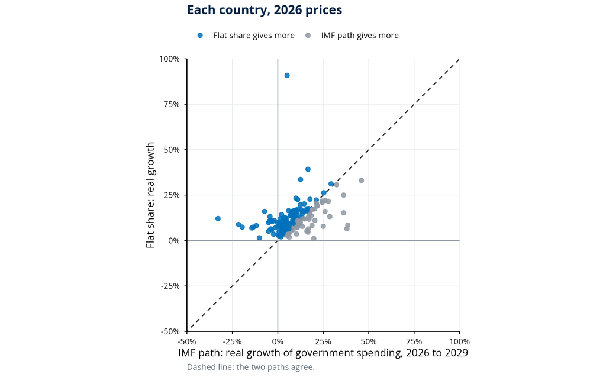

```r
in_view <- paths |>
  filter(in_view) |>
  mutate(side = if_else(flat_growth > imf_growth, "Flat share gives more", "IMF path gives more"))
ggplot(in_view, aes(imf_growth, flat_growth)) +
  geom_abline(slope = 1, intercept = 0, linetype = "dashed", colour = "black") +
  geom_hline(yintercept = 0, colour = WB[["grey"]]) +
  geom_vline(xintercept = 0, colour = WB[["grey"]]) +
  geom_point(aes(colour = side), size = 2, alpha = 0.85) +
  scale_colour_manual(
    values = c("Flat share gives more" = WB[["blue"]], "IMF path gives more" = "#8f99a3")
  ) +
  scale_x_continuous(
    limits = c(-50, 100), breaks = seq(-50, 100, 25), labels = scales::label_percent(scale = 1),
    expand = c(0, 0)
  ) +
  scale_y_continuous(
    limits = c(-50, 100), breaks = seq(-50, 100, 25), labels = scales::label_percent(scale = 1),
    expand = c(0, 0)
  ) +
  coord_equal() +
  labs(
    x = "IMF path: real growth of government spending, 2026 to 2029", y = "Flat share: real growth",
    title = "Each country, 2026 prices", caption = "Dashed line: the two paths agree."
  )
```

## 19. Country illustrations: Ethiopia, Kenya, and Indonesia in 2029

*How do the proposed scenarios translate into country-specific budget amounts?*

Ethiopia, Kenya, and Indonesia illustrate how the same allocation rules operate under different fiscal and expenditure conditions. For each country, proposed increases are compared with the projected ceiling under the IMF path. Estimates are presented in current national currency, in US dollars using the IMF’s 2029 exchange rate, and as real percentage increases relative to the 2026 health budget.

Ethiopia has no eligible historical-trend scenario because health’s share declined over its observation window, and projected inflation substantially reduces the real value of nominal increases. Kenya’s positive historical trend is smaller than the fixed 0.75-percentage-point scenario. In Indonesia, the upper ask occupies only a limited share of the nominal ceiling. In all three countries, the fixed 0.75-percentage-point increase determines the upper ask, illustrating both the consistency of the rule and the variation in its fiscal implications.

```r
## Slide 19: Ethiopia, Kenya and Indonesia in 2029, IMF path: protect amount, candidates, upper ask
## and ceiling, with the share of the real ceiling each represents.
UNIT <- list(
  ETH = list(div = 1e9, cur = "ETB", scale = "billion", name = "Ethiopia"),
  KEN = list(div = 1e9, cur = "KES", scale = "billion", name = "Kenya"),
  IDN = list(div = 1e12, cur = "IDR", scale = "trillion", name = "Indonesia")
)
CAND <- c(
  protect = "d_protect", trend = "c_trend", s025 = "c_025", s050 = "c_050", s075 = "c_075",
  ask = "ask", ceiling = "d_all"
)
CAND_LABEL <- c(
  protect = "Protect", trend = "Own trend", s025 = "+0.25 a year", s050 = "+0.5 a year",
  s075 = "+0.75 a year", ask = "Upper ask", ceiling = "Ceiling"
)

tables <- list()
ladder <- NULL
for (iso in c("ETH", "KEN", "IDN")) {
  row_2029 <- filter(mine$rx, iso3 == iso, variant == "imf", year == 2029)
  unit <- UNIT[[iso]]
  # Each amount in four units: national currency, US$ million, the real rise in % of the 2026 health
  # budget and % of the real ceiling. The own-trend candidate exists only where health's share rose.
  trend_ok <- !is.na(row_2029$trend) && row_2029$trend > 0
  # The builder rounds US$ million to one decimal and the slide prints it whole in
  # JavaScript, which rounds a half away from zero where R's round() goes to the even
  # number; we round in the same two steps.
  amounts <- tibble(
    key = names(CAND),
    nominal = unlist(row_2029[CAND]),
    usd = unlist(row_2029[paste0(CAND, "_usd")]),
    real_pct = unlist(row_2029[paste0(CAND, "_pct")]),
    real = unlist(row_2029[paste0(CAND, "_real")])
  ) |>
    mutate(
      shown = !is.na(nominal) & (key != "trend" | trend_ok),
      of_ceiling = 100 * real / row_2029$d_all_real,
      usd_tenths = round(usd / 1e6, 1),
      # a half away from zero, as in JavaScript
      usd_whole = sign(usd_tenths) * floor(abs(usd_tenths) + 0.5)
    )
  caption <- paste0(
    unit$name, ", 2029, IMF path: health ", one_decimal(row_2029$h), "% of government spending"
  )
  tables[[caption]] <- amounts |>
    transmute(
      Amount = unname(CAND_LABEL[key]),
      `National currency` = if_else(
        shown, paste(unit$cur, one_decimal(nominal / unit$div), unit$scale), "-"
      ),
      `US$ million` = if_else(shown, scales::comma(usd_whole, accuracy = 1), "-"),
      `Real, % of the 2026 health budget` = if_else(
        shown, signed_pct(real_pct), "-"
      ),
      `% of the real ceiling` = if_else(
        shown & !key %in% c("ask", "ceiling"), one_decimal(of_ceiling), "-"
      )
    )
  # the ladder chart: the protect amount and the candidates as % of the real ceiling
  rungs <- amounts |>
    filter(key %in% c("protect", "trend", "s025", "s050", "s075")) |>
    transmute(
      country = unit$name,
      cand = unname(CAND_LABEL[key]),
      v = if_else(shown, of_ceiling, NA),
      role = case_when(
        key == "protect" ~ "Protect",
        key == row_2029$setter ~ "Upper ask",
        .default = "Other candidate"
      )
    )
  ladder <- bind_rows(ladder, rungs)
}
eth <- filter(mine$rx, iso3 == "ETH", variant == "imf", year == 2029)
ken <- filter(mine$rx, iso3 == "KEN", variant == "imf", year == 2029)
idn <- filter(mine$rx, iso3 == "IDN", variant == "imf", year == 2029)
# Ethiopia's price rise as the slide prints it: the builder keeps the price level to three decimals
# and the slide rounds the per cent half up
eth_price_level <- round(eth$p, 3)
eth_price_rise <- floor(100 * (eth_price_level - 1) + 0.5)
setters <- unique(c(eth$setter_label, ken$setter_label, idn$setter_label))
tables[["Also printed on the slide"]] <- tibble(
  Item = c(
    "Ethiopia: own trend, points a year", "Ethiopia: price rise 2026 to 2029",
    "Kenya: own trend, points a year", "Kenya: health's share reached by the ask, 2029",
    "Indonesia: ask, % of the nominal ceiling",
    "Indonesia: health's share reached by the ask, 2029",
    "Upper ask set by, all three"
  ),
  Value = c(
    signed(eth$trend),
    paste0(eth_price_rise, "%"),
    signed(ken$trend),
    share_pct(ken$h_ask),
    whole_pct(idn$ask_share_of_ceiling_nominal),
    share_pct(idn$h_ask),
    paste(setters, collapse = ", ")
  )
)
show_tables(tables)
```

Ethiopia, 2029, IMF path: health 5.7% of government spending

| Amount | National currency | US$ million | Real, % of the 2026 health budget | % of the real ceiling |
| --- | --- | --- | --- | --- |
| Protect | ETB 114.8 billion | 640 | +25.3% | 5.7 |
| Own trend | - | - | - | - |
| +0.25 a year | ETB 150.2 billion | 838 | +41.9% | 9.4 |
| +0.5 a year | ETB 185.7 billion | 1,036 | +58.4% | 13.1 |
| +0.75 a year | ETB 221.2 billion | 1,233 | +75.0% | 16.8 |
| Upper ask | ETB 221.2 billion | 1,233 | +75.0% | - |
| Ceiling | ETB 2,021.6 billion | 11,272 | +445.9% | - |

Kenya, 2029, IMF path: health 8.7% of government spending

| Amount | National currency | US$ million | Real, % of the 2026 health budget | % of the real ceiling |
| --- | --- | --- | --- | --- |
| Protect | KES 112.8 billion | 775 | +10.4% | 8.7 |
| Own trend | KES 139.6 billion | 959 | +16.1% | 13.4 |
| +0.25 a year | KES 157.5 billion | 1,082 | +20.0% | 16.6 |
| +0.5 a year | KES 202.2 billion | 1,389 | +29.5% | 24.6 |
| +0.75 a year | KES 246.8 billion | 1,697 | +39.1% | 32.6 |
| Upper ask | KES 246.8 billion | 1,697 | +39.1% | - |
| Ceiling | KES 1,303.4 billion | 8,958 | +120.0% | - |

Indonesia, 2029, IMF path: health 8.5% of government spending

| Amount | National currency | US$ million | Real, % of the 2026 health budget | % of the real ceiling |
| --- | --- | --- | --- | --- |
| Protect | IDR 93.8 trillion | 5,521 | +15.9% | 8.5 |
| Own trend | IDR 162.3 trillion | 9,556 | +33.0% | 17.6 |
| +0.25 a year | IDR 134.8 trillion | 7,934 | +26.1% | 14.0 |
| +0.5 a year | IDR 175.7 trillion | 10,347 | +36.3% | 19.4 |
| +0.75 a year | IDR 216.7 trillion | 12,759 | +46.5% | 24.9 |
| Upper ask | IDR 216.7 trillion | 12,759 | +46.5% | - |
| Ceiling | IDR 1,100.6 trillion | 64,797 | +186.9% | - |

Also printed on the slide

| Item | Value |
| --- | --- |
| Ethiopia: own trend, points a year | -0.1 |
| Ethiopia: price rise 2026 to 2029 | 39% |
| Kenya: own trend, points a year | +0.2 |
| Kenya: health’s share reached by the ask, 2029 | 10.9% |
| Indonesia: ask, % of the nominal ceiling | 20% |
| Indonesia: health’s share reached by the ask, 2029 | 10.8% |
| Upper ask set by, all three | +0.75 a year |

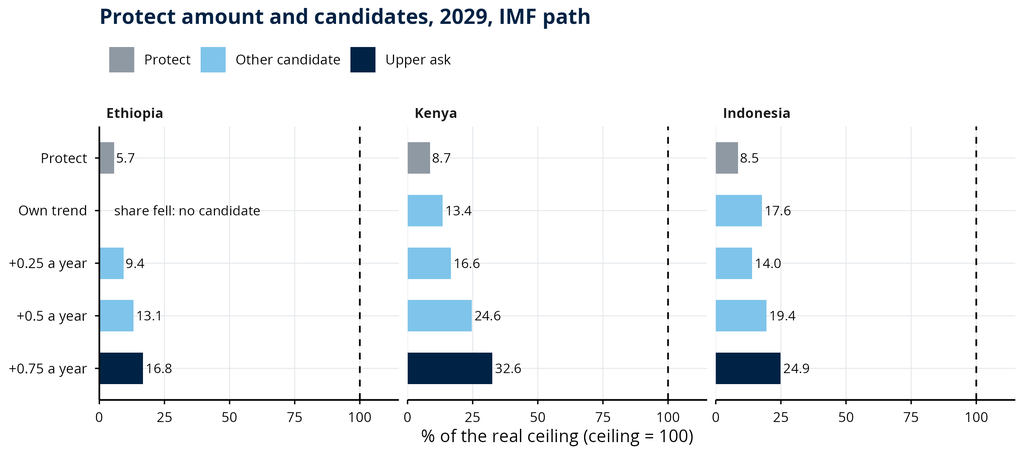

```r
rung_names <- unname(CAND_LABEL[c("protect", "trend", "s025", "s050", "s075")])
ladder <- ladder |>
  mutate(
    cand = factor(cand, levels = rev(rung_names)),
    country = factor(country, levels = c("Ethiopia", "Kenya", "Indonesia")),
    bar = coalesce(v, 0),
    label = if_else(is.na(v), "share fell: no candidate", one_decimal(v))
  )
ggplot(ladder, aes(x = bar, y = cand, fill = role)) +
  geom_col(width = 0.6) +
  geom_text(aes(label = label), hjust = -0.1, size = 3) +
  geom_vline(xintercept = 100, linetype = "dashed") +
  facet_wrap(~country) +
  scale_fill_manual(
    values = c(Protect = "#8f99a3", "Upper ask" = WB[["navy"]], "Other candidate" = WB[["light"]]),
    breaks = c("Protect", "Other candidate", "Upper ask")
  ) +
  scale_x_continuous(limits = c(0, 115), breaks = c(0, 25, 50, 75, 100), expand = c(0, 0)) +
  labs(
    x = "% of the real ceiling (ceiling = 100)", y = NULL,
    title = "Protect amount and candidates, 2029, IMF path"
  )
```

## 20. Annual health budget scenarios for Ethiopia, Kenya, and Indonesia

*What additional spending would each scenario imply in 2027, 2028, and 2029?*

Country-level estimates show how the protect amount, eligible increases in health’s budget share, the selected upper ask, and the overall expenditure ceiling evolve from 2027 to 2029 under the IMF path. Each amount represents an increase relative to the 2026 baseline and is reported in current national currency, as a real percentage of the baseline health budget, and in US dollars at the relevant year’s projected exchange rate. A missing historical-trend scenario indicates that health’s budget share declined during the observation window.

Nominal budget increases should not be equated with increases in purchasing power. The accompanying real percentages adjust for changes in the GDP deflator, allowing the nominal fiscal request to be considered alongside its implied change in real resources. These estimates describe potential budget increments, not expenditure commitments or estimates of health-service delivery costs.

```r
## Slide 20: the policy table for Ethiopia, Kenya and Indonesia, 2027 to
## 2029, IMF path; one table per country.
tables <- list()
for (iso in c("ETH", "KEN", "IDN")) {
  unit <- UNIT[[iso]]
  country_years <- mine$rx |>
    filter(iso3 == iso, variant == "imf") |>
    arrange(year)
  policy_rows <- NULL
  for (i in seq_len(nrow(country_years))) {
    one_year <- country_years[i, ]
    # the amounts as on slide 19: the nominal increase, then (the real rise in %, US$ million)
    trend_ok <- !is.na(one_year$trend) && one_year$trend > 0
    nominal <- unlist(one_year[CAND])
    real_pct <- unlist(one_year[paste0(CAND, "_pct")])
    usd <- unlist(one_year[paste0(CAND, "_usd")])
    shown <- !is.na(nominal) & (names(CAND) != "trend" | trend_ok)
    national <- one_decimal(nominal / unit$div)
    real_rise <- signed_pct(real_pct)
    # US$ million rounded in two steps, as on slide 19
    usd_tenths <- round(usd / 1e6, 1)
    # a half away from zero, as in JavaScript
    usd_whole <- sign(usd_tenths) * floor(abs(usd_tenths) + 0.5)
    usd_million <- scales::comma(usd_whole, accuracy = 1)
    cell <- if_else(shown, paste0(national, " (", real_rise, ", US$", usd_million, " m)"), "-")
    policy_rows <- bind_rows(policy_rows, tibble(
      Year = as.character(one_year$year),
      Protect = cell[1],
      `Own trend` = cell[2],
      `+0.25 a year` = cell[3],
      `+0.5 a year` = cell[4],
      `+0.75 a year` = cell[5],
      `Upper ask` = cell[6],
      `Set by` = sub(" a year", "", one_year$setter_label),
      Ceiling = cell[7]
    ))
  }
  first_year <- country_years[1, ]
  caption <- paste0(
    unit$name, ": ", unit$cur, " ", unit$scale, "; health ", one_decimal(first_year$h),
    "% of government spending; own trend ", signed(first_year$trend), " points a year"
  )
  tables[[caption]] <- policy_rows
}
show_tables(tables)
```

Ethiopia: ETB billion; health 5.7% of government spending; own trend -0.1 points a year

| Year | Protect | Own trend | +0.25 a year | +0.5 a year | +0.75 a year | Upper ask | Set by | Ceiling |
| --- | --- | --- | --- | --- | --- | --- | --- | --- |
| 2027 | 28.9 (+3.4%, US$177 m) | - | 36.9 (+8.0%, US$226 m) | 45.0 (+12.5%, US$275 m) | 53.0 (+17.1%, US$324 m) | 53.0 (+17.1%, US$324 m) | +0.75 | 509.0 (+60.1%, US$3,110 m) |
| 2028 | 65.0 (+11.8%, US$377 m) | - | 84.3 (+21.7%, US$488 m) | 103.6 (+31.5%, US$600 m) | 122.9 (+41.4%, US$712 m) | 122.9 (+41.4%, US$712 m) | +0.75 | 1,145.5 (+208.4%, US$6,637 m) |
| 2029 | 114.8 (+25.3%, US$640 m) | - | 150.2 (+41.9%, US$838 m) | 185.7 (+58.4%, US$1,036 m) | 221.2 (+75.0%, US$1,233 m) | 221.2 (+75.0%, US$1,233 m) | +0.75 | 2,021.6 (+445.9%, US$11,272 m) |

Kenya: KES billion; health 8.7% of government spending; own trend +0.2 points a year

| Year | Protect | Own trend | +0.25 a year | +0.5 a year | +0.75 a year | Upper ask | Set by | Ceiling |
| --- | --- | --- | --- | --- | --- | --- | --- | --- |
| 2027 | 31.2 (+2.3%, US$235 m) | 38.8 (+4.1%, US$292 m) | 43.8 (+5.3%, US$330 m) | 56.3 (+8.2%, US$424 m) | 68.9 (+11.2%, US$519 m) | 68.9 (+11.2%, US$519 m) | +0.75 | 361.0 (+27.0%, US$2,720 m) |
| 2028 | 67.7 (+5.8%, US$486 m) | 84.1 (+9.5%, US$603 m) | 94.9 (+11.9%, US$681 m) | 122.1 (+18.0%, US$877 m) | 149.3 (+24.1%, US$1,072 m) | 149.3 (+24.1%, US$1,072 m) | +0.75 | 783.0 (+67.1%, US$5,620 m) |
| 2029 | 112.8 (+10.4%, US$775 m) | 139.6 (+16.1%, US$959 m) | 157.5 (+20.0%, US$1,082 m) | 202.2 (+29.5%, US$1,389 m) | 246.8 (+39.1%, US$1,697 m) | 246.8 (+39.1%, US$1,697 m) | +0.75 | 1,303.4 (+120.0%, US$8,958 m) |

Indonesia: IDR trillion; health 8.5% of government spending; own trend +0.4 points a year

| Year | Protect | Own trend | +0.25 a year | +0.5 a year | +0.75 a year | Upper ask | Set by | Ceiling |
| --- | --- | --- | --- | --- | --- | --- | --- | --- |
| 2027 | 26.7 (+4.3%, US$1,535 m) | 46.2 (+9.4%, US$2,661 m) | 38.4 (+7.4%, US$2,208 m) | 50.0 (+10.4%, US$2,881 m) | 61.7 (+13.5%, US$3,554 m) | 61.7 (+13.5%, US$3,554 m) | +0.75 | 313.0 (+50.5%, US$18,018 m) |
| 2028 | 59.1 (+10.0%, US$3,459 m) | 101.4 (+20.8%, US$5,935 m) | 84.4 (+16.4%, US$4,940 m) | 109.7 (+22.9%, US$6,420 m) | 134.9 (+29.3%, US$7,901 m) | 134.9 (+29.3%, US$7,901 m) | +0.75 | 693.4 (+117.2%, US$40,600 m) |
| 2029 | 93.8 (+15.9%, US$5,521 m) | 162.3 (+33.0%, US$9,556 m) | 134.8 (+26.1%, US$7,934 m) | 175.7 (+36.3%, US$10,347 m) | 216.7 (+46.5%, US$12,759 m) | 216.7 (+46.5%, US$12,759 m) | +0.75 | 1,100.6 (+186.9%, US$64,797 m) |

## 21. Implications and limitations for health budget planning

*What additional evidence is needed to turn a fiscal scenario into a credible health budget proposal?*

The framework offers an initial benchmark for discussions about the scale of additional government resources for health. It does not determine whether a proposed allocation is affordable alongside competing priorities, can be executed effectively, or will produce commensurate health benefits. Country-level assessment should therefore consider the latest approved budget, actual expenditure execution, service-delivery capacity, the expected cost and impact of proposed investments, and whether health-sector prices may increase faster than the economy-wide GDP deflator.

Several uncertainties remain. IMF projections are revised periodically, and the historical budget-share trend may mask recent changes in priorities. A government budget can expand in nominal currency while contracting in real terms. Some countries also lack complete IMF series or exchange-rate projections. Regional and income-group comparisons provide context but should not automatically determine country-specific requests. The protect amount and upper ask are planning scenarios, not validated financing needs.

```r
## Slide 21: coverage of the prescription and the countries without an IMF
## series (the slide is text; no figure).
countries_with_base <- unique(mine$rx$iso3)
countries_with_data <- unique(mine$rx$iso3[mine$rx$has_data %in% TRUE])
world_2029 <- filter(mine$rx_grp, key == "world", variant == "imf", year == 2029)

# The countries without an IMF series, sorted by code point as the deck's builder sorts them, and
# printed without the bracket or the east Jerusalem note in their GHED names
no_imf_names <- mine$rx |>
  filter(!iso3 %in% countries_with_data) |>
  distinct(iso3, name) |>
  arrange(name) |>
  mutate(
    name = sub("\\s*\\(.*\\)$", "", name),
    name = sub(", including east Jerusalem$", "", name)
  ) |>
  pull(name)
no_base_names <- countries$name[!countries$iso3 %in% countries_with_base]

coverage <- tibble(
  Item = c(
    "Countries with a Section 1 base", "Countries with IMF projections",
    "2029 budget grows in currency but falls in real terms, IMF path", "No IMF series",
    "No GHED base"
  ),
  Value = c(
    length(countries_with_base),
    length(countries_with_data),
    world_2029$n_real_fall_only,
    knitr::combine_words(no_imf_names, oxford_comma = FALSE),
    knitr::combine_words(no_base_names, oxford_comma = FALSE)
  )
)
tables <- list("Coverage" = coverage)
show_tables(tables)
```

Coverage

| Item | Value |
| --- | --- |
| Countries with a Section 1 base | 194 |
| Countries with IMF projections | 183 |
| 2029 budget grows in currency but falls in real terms, IMF path | 14 |
| No IMF series | Afghanistan, Cook Islands, Ecuador, Eritrea, Lebanon, Monaco, Niue, Senegal, Syrian Arab Republic, Venezuela and occupied Palestinian territory |
| No GHED base | Cuba |

# Annex A. Country-level decomposition by World Bank region

This annex presents the latest available decomposition for each country, organised by World Bank region. For each country, the tables report the observation window, real government health expenditure per capita in the final year (constant 2023 US dollars), the annualised total change and its three component contributions, and the dominant growth pattern. An asterisk identifies countries where economic growth was positive but health’s share of government expenditure declined.

Quality flags indicate a possible **break (B)**, **shock (S)**, **unusual endpoint (E)**, or **extreme expenditure level (L)**. Income groups are abbreviated as **Low**, **LM** (lower-middle income), **UM** (upper-middle income), and **High**. Regional summaries report growth-pattern counts and, where at least eight countries are available, the median change in government health expenditure per capita. The annex provides complete country coverage rather than a ranking of performance.

```r
## The seven slides shared by annexes A and B (which countries each
## slide lists), and the annex A table.
annex_slides <- tibble(
  slide = 1:7,
  lead_region = c(
    "East Asia & Pacific", "Europe & Central Asia", "Europe & Central Asia",
    "Latin America & Caribbean", "Middle East, North Africa, Afghanistan & Pakistan",
    "Sub-Saharan Africa", "Sub-Saharan Africa"
  ),
  title = c(
    "East Asia and Pacific; South Asia",
    "Europe and Central Asia (1 of 2)",
    "Europe and Central Asia (2 of 2); no World Bank region",
    "Latin America and the Caribbean; North America",
    "Middle East, North Africa, Afghanistan and Pakistan",
    "Sub-Saharan Africa (1 of 2)",
    "Sub-Saharan Africa (2 of 2)"
  )
)

# Every country's place in the annexes: regions in the slides' order, countries alphabetical inside
# a region, and the two long regions cut in half over two slides each
region_order <- c(
  "East Asia & Pacific", "South Asia", "Europe & Central Asia", "Not classified",
  "Latin America & Caribbean", "North America",
  "Middle East, North Africa, Afghanistan & Pakistan", "Sub-Saharan Africa"
)
annex_countries <- countries |>
  left_join(short_names, by = "iso3") |>
  mutate(
    region = if_else(wb_region == "not_classified", "Not classified", wb_region),
    inc = unname(INC_CODE[income_group])
  ) |>
  arrange(match(region, region_order), sort_name) |>
  group_by(region) |>
  mutate(first_half = row_number() <= ceiling(n() / 2)) |>
  ungroup() |>
  mutate(
    annex_slide = case_when(
      region %in% c("East Asia & Pacific", "South Asia") ~ 1,
      region == "Europe & Central Asia" & first_half ~ 2,
      region %in% c("Europe & Central Asia", "Not classified") ~ 3,
      region %in% c("Latin America & Caribbean", "North America") ~ 4,
      region == "Middle East, North Africa, Afghanistan & Pakistan" ~ 5,
      region == "Sub-Saharan Africa" & first_half ~ 6,
      region == "Sub-Saharan Africa" ~ 7
    ),
    annex_position = row_number()
  ) |>
  select(iso3, short, region, inc, annex_slide, annex_position)

# Annex A, one slide: the region line of the slide's lead and the table of every country's latest
# window. We keep this as a function because seven slides use it, each run a second time on the
# report's tables in the final check; `bundle` is `mine` or the report's tables.
annex_a <- function(bundle, slide) {
  this_slide <- annex_slides[annex_slides$slide == slide, ]
  lead_region <- this_slide$lead_region

  # every country on the slide, in the order the slide lists them
  slide_rows <- annex_countries |>
    filter(annex_slide == slide) |>
    left_join(bundle$win, by = "iso3") |>
    arrange(annex_position) |>
    mutate(has_window = !is.na(total))
  table <- slide_rows |>
    transmute(
      Region = unname(REG_LABEL[region]),
      Country = short,
      Inc. = inc,
      `US$` = if_else(has_window, dollars(ghe1, prefix = ""), ""),
      Total = if_else(has_window, signed(total), ""),
      Econ. = if_else(has_window, signed(econ), ""),
      Govt = if_else(has_window, signed(budget), ""),
      Prio. = if_else(has_window, signed(priority), ""),
      Pattern = if_else(
        has_window, paste0(pattern, if_else(lost_priority %in% TRUE, "*", "")), "Not available"
      ),
      Flag = if_else(has_window, coalesce(flag, ""), ""),
      Window = if_else(has_window, paste0(y0, "-", y1), "no constant-price series")
    )

  # the lead: the pattern counts and, for a region with at least eight countries, the median total
  counts <- filter(bundle$pat_reg, key == lead_region)
  latest <- filter(bundle$grp, key == lead_region, period == "W")
  median_text <- ""
  if (grepl("^Carries", latest$status)) {
    median_text <- paste0("; median country ", signed(latest$med_total), " log points a year")
  }
  lead <- paste0(
    REG_LABEL[[lead_region]], ": ", counts$n, " countries, ",
    counts$`Economy-led`, " economy-led, ", counts$`Budget-led`, " budget-led, ",
    counts$`Priority-led`, " priority-led, ", counts$Declining, " declining", median_text
  )

  tables <- list("Lead of the slide" = data.frame(Region = lead))
  tables[[paste0("Annex: ", this_slide$title)]] <- table
  tables
}
```

## 22. East Asia and the Pacific; South Asia

The distribution of real government health expenditure per capita varies widely across the two regions, from low single-digit dollar amounts in some countries to several thousand dollars in Australia and New Zealand. Results for countries with unusual levels or abrupt changes in the published series are accompanied by quality flags and should be interpreted with particular care.

```r
## Slide 22, annex A1: East Asia and Pacific; South Asia.
tables <- annex_a(mine, slide = 1)
show_tables(tables)
```

Lead of the slide

| Region |
| --- |
| East Asia and Pacific: 29 countries, 11 economy-led, 6 budget-led, 11 priority-led, 1 declining; median country +3.8 log points a year |

Annex: East Asia and Pacific; South Asia

| Region | Country | Inc. | US$ | Total | Econ. | Govt | Prio. | Pattern | Flag | Window |
| --- | --- | --- | --- | --- | --- | --- | --- | --- | --- | --- |
| East Asia and Pacific | Australia | High | 5,142 | +3.6 | +1.0 | -0.5 | +3.1 | Priority-led |  | 2013-2023 |
| East Asia and Pacific | Brunei Darussalam | High | 678 | +0.6 | -1.2 | -1.3 | +3.2 | Priority-led |  | 2013-2023 |
| East Asia and Pacific | Cambodia | LM | 30.8 | +5.2 | +4.2 | +1.3 | -0.2 | Economy-led* | B | 2013-2023 |
| East Asia and Pacific | China | UM | 436 | +8.0 | +5.5 | +1.5 | +1.0 | Economy-led |  | 2013-2023 |
| East Asia and Pacific | Fiji | UM | 159 | +5.8 | +2.1 | +1.5 | +2.2 | Priority-led |  | 2013-2023 |
| East Asia and Pacific | Indonesia | UM | 70.6 | +8.9 | +3.2 | -1.0 | +6.7 | Priority-led |  | 2013-2023 |
| East Asia and Pacific | Japan | High | 3,086 | +0.9 | +0.8 | -0.3 | +0.5 | Economy-led |  | 2013-2023 |
| East Asia and Pacific | Kiribati | LM | 187 | +4.6 | +2.8 | +2.0 | -0.2 | Economy-led* |  | 2013-2023 |
| East Asia and Pacific | Korea, Rep. | High | 1,782 | +5.9 | +2.2 | +0.9 | +2.8 | Priority-led |  | 2014-2024 |
| East Asia and Pacific | Lao PDR | LM | 10.9 | +0.1 | +3.1 | -3.9 | +0.9 | Economy-led |  | 2013-2023 |
| East Asia and Pacific | Malaysia | UM | 225 | +2.9 | +2.4 | -1.1 | +1.5 | Economy-led |  | 2013-2023 |
| East Asia and Pacific | Marshall Islands | UM | 671 | +9.1 | +4.2 | +1.8 | +3.2 | Economy-led |  | 2013-2023 |
| East Asia and Pacific | Micronesia | LM | 72.3 | +2.0 | +0.3 | -1.2 | +2.8 | Priority-led |  | 2013-2023 |
| East Asia and Pacific | Mongolia | UM | 162 | +3.8 | +2.0 | -0.1 | +1.9 | Economy-led |  | 2013-2023 |
| East Asia and Pacific | Myanmar | LM | 6.2 | -0.3 | +1.4 | -1.2 | -0.5 | Declining* |  | 2013-2023 |
| East Asia and Pacific | Nauru | High | 1,918 | +12.8 | +2.3 | +5.8 | +4.7 | Budget-led | L | 2013-2023 |
| East Asia and Pacific | New Zealand | High | 3,882 | +2.9 | +1.7 | +0.8 | +0.4 | Economy-led |  | 2013-2023 |
| East Asia and Pacific | Palau | High | 1,025 | +1.0 | -0.8 | +2.1 | -0.3 | Budget-led |  | 2013-2023 |
| East Asia and Pacific | Papua New Guinea | LM | 62.4 | +2.1 | +1.5 | -2.2 | +2.7 | Priority-led |  | 2013-2023 |
| East Asia and Pacific | Philippines | LM | 82.3 | +10.0 | +3.4 | +3.5 | +3.0 | Budget-led |  | 2013-2023 |
| East Asia and Pacific | Samoa | LM | 203 | +1.7 | +0.1 | +0.4 | +1.1 | Priority-led |  | 2013-2023 |
| East Asia and Pacific | Singapore | High | 2,293 | +7.7 | +2.4 | +3.2 | +2.2 | Budget-led |  | 2013-2023 |
| East Asia and Pacific | Solomon Islands | LM | 70.1 | +1.0 | -1.0 | -0.4 | +2.4 | Priority-led |  | 2013-2023 |
| East Asia and Pacific | Thailand | UM | 254 | +4.5 | +1.5 | +0.5 | +2.5 | Priority-led |  | 2013-2023 |
| East Asia and Pacific | Timor-Leste | LM | 112 | +5.7 | +0.6 | -1.7 | +6.8 | Priority-led | S | 2013-2023 |
| East Asia and Pacific | Tonga | UM | 165 | +3.8 | +1.7 | +3.4 | -1.4 | Budget-led* |  | 2013-2023 |
| East Asia and Pacific | Tuvalu | UM | 1,255 | +11.5 | +4.6 | +3.4 | +3.5 | Economy-led | L | 2013-2023 |
| East Asia and Pacific | Vanuatu | LM | 81.2 | +0.1 | -0.2 | +6.0 | -5.6 | Budget-led | B E | 2013-2023 |
| East Asia and Pacific | Viet Nam | LM | 87.4 | +5.0 | +4.9 | -2.4 | +2.5 | Economy-led |  | 2013-2023 |
| South Asia | Bangladesh | LM | 7.7 | +2.1 | +5.4 | +0.5 | -3.8 | Economy-led* |  | 2013-2023 |
| South Asia | Bhutan | LM | 108 | +5.1 | +2.6 | -1.2 | +3.6 | Priority-led |  | 2013-2023 |
| South Asia | India | LM | 33.0 | +8.9 | +4.8 | +0.6 | +3.5 | Economy-led |  | 2013-2023 |
| South Asia | Maldives | UM | 915 | +7.5 | +2.2 | +5.5 | -0.2 | Budget-led* | S | 2013-2023 |
| South Asia | Nepal | LM | 26.3 | +12.8 | +3.5 | +4.8 | +4.5 | Budget-led |  | 2013-2023 |
| South Asia | Sri Lanka | LM | 45.1 | -2.5 | +0.6 | +1.6 | -4.7 | Declining* |  | 2013-2023 |

## 23. Europe and Central Asia (part 1)

Across Europe and Central Asia, economic growth is the leading contributor to increased government health expenditure per capita in a comparatively large share of countries. The country-level decomposition provides a more detailed view of how the relative contributions of GDP, government size, and health priority differ within the region.

```r
## Slide 23, annex A2: Europe and Central Asia, first half.
tables <- annex_a(mine, slide = 2)
show_tables(tables)
```

Lead of the slide

| Region |
| --- |
| Europe and Central Asia: 52 countries, 33 economy-led, 2 budget-led, 13 priority-led, 4 declining; median country +2.9 log points a year |

Annex: Europe and Central Asia (1 of 2)

| Region | Country | Inc. | US$ | Total | Econ. | Govt | Prio. | Pattern | Flag | Window |
| --- | --- | --- | --- | --- | --- | --- | --- | --- | --- | --- |
| Europe and Central Asia | Albania | UM | 293 | +6.6 | +3.4 | -0.1 | +3.3 | Economy-led |  | 2013-2023 |
| Europe and Central Asia | Andorra | High | 2,553 | +2.5 | +1.2 | -1.7 | +3.1 | Priority-led |  | 2013-2023 |
| Europe and Central Asia | Armenia | UM | 120 | +5.1 | +4.5 | +1.2 | -0.6 | Economy-led* |  | 2013-2023 |
| Europe and Central Asia | Austria | High | 4,795 | +1.8 | +0.5 | +0.1 | +1.2 | Priority-led |  | 2013-2023 |
| Europe and Central Asia | Azerbaijan | UM | 97.8 | +3.0 | +0.4 | -1.4 | +4.1 | Priority-led |  | 2013-2023 |
| Europe and Central Asia | Belarus | UM | 373 | +3.6 | +0.8 | -0.1 | +2.9 | Priority-led |  | 2013-2023 |
| Europe and Central Asia | Belgium | High | 4,369 | +1.1 | +1.1 | -0.5 | +0.4 | Economy-led |  | 2013-2023 |
| Europe and Central Asia | Bosnia and Herzegovina | UM | 520 | +3.2 | +4.1 | -0.7 | -0.3 | Economy-led* |  | 2013-2023 |
| Europe and Central Asia | Bulgaria | High | 790 | +5.8 | +3.7 | +0.3 | +1.8 | Economy-led |  | 2013-2023 |
| Europe and Central Asia | Croatia | High | 1,301 | +4.6 | +3.6 | -0.2 | +1.2 | Economy-led |  | 2013-2023 |
| Europe and Central Asia | Cyprus | High | 2,226 | +10.1 | +3.3 | -1.0 | +7.8 | Priority-led | E | 2013-2023 |
| Europe and Central Asia | Czechia | High | 2,253 | +3.1 | +1.9 | +0.4 | +0.9 | Economy-led |  | 2013-2023 |
| Europe and Central Asia | Denmark | High | 5,531 | +0.8 | +1.9 | -1.7 | +0.6 | Economy-led |  | 2014-2024 |
| Europe and Central Asia | Estonia | High | 1,711 | +3.9 | +1.8 | +1.3 | +0.7 | Economy-led |  | 2013-2023 |
| Europe and Central Asia | Finland | High | 4,476 | +1.4 | +0.5 | -0.2 | +1.0 | Priority-led |  | 2013-2023 |
| Europe and Central Asia | France | High | 3,559 | +0.5 | +0.8 | 0.0 | -0.2 | Economy-led* |  | 2014-2024 |
| Europe and Central Asia | Georgia | UM | 187 | +7.2 | +4.8 | +1.1 | +1.3 | Economy-led |  | 2013-2023 |
| Europe and Central Asia | Germany | High | 5,059 | +2.0 | +0.8 | +0.7 | +0.5 | Economy-led |  | 2013-2023 |
| Europe and Central Asia | Greece | High | 994 | -0.2 | +1.8 | -2.5 | +0.5 | Declining |  | 2013-2023 |
| Europe and Central Asia | Hungary | High | 1,042 | +3.1 | +3.4 | -0.2 | -0.1 | Economy-led* |  | 2013-2023 |
| Europe and Central Asia | Iceland | High | 5,908 | +2.6 | +1.7 | -0.1 | +1.1 | Economy-led |  | 2013-2023 |
| Europe and Central Asia | Ireland | High | 5,268 | +3.0 | +6.5 | -5.6 | +2.1 | Economy-led |  | 2013-2023 |
| Europe and Central Asia | Italy | High | 2,399 | +0.4 | +1.2 | +0.5 | -1.3 | Economy-led* |  | 2013-2023 |
| Europe and Central Asia | Kazakhstan | UM | 322 | +4.4 | +1.4 | +1.6 | +1.4 | Budget-led |  | 2013-2023 |
| Europe and Central Asia | Kyrgyzstan | LM | 51.5 | -3.0 | +2.0 | -1.5 | -3.5 | Declining* |  | 2013-2023 |
| Europe and Central Asia | Latvia | High | 978 | +5.7 | +3.2 | +0.9 | +1.6 | Economy-led |  | 2013-2023 |

## 24. Europe and Central Asia (part 2); countries without a regional classification

The remaining countries in Europe and Central Asia are followed by the Cook Islands and Niue, which are not assigned to a World Bank region in the classification used here. Their results are retained for completeness without attributing them to a regional aggregate.

```r
## Slide 24, annex A3: Europe and Central Asia, second half; countries without a World Bank region.
tables <- annex_a(mine, slide = 3)
show_tables(tables)
```

Lead of the slide

| Region |
| --- |
| Europe and Central Asia: 52 countries, 33 economy-led, 2 budget-led, 13 priority-led, 4 declining; median country +2.9 log points a year |

Annex: Europe and Central Asia (2 of 2); no World Bank region

| Region | Country | Inc. | US$ | Total | Econ. | Govt | Prio. | Pattern | Flag | Window |
| --- | --- | --- | --- | --- | --- | --- | --- | --- | --- | --- |
| Europe and Central Asia | Liechtenstein | High | 7,937 | +1.0 | +0.7 | -0.8 | +1.1 | Priority-led |  | 2013-2023 |
| Europe and Central Asia | Lithuania | High | 1,329 | +5.3 | +3.6 | +0.4 | +1.2 | Economy-led |  | 2013-2023 |
| Europe and Central Asia | Luxembourg | High | 6,742 | +1.3 | -0.2 | +1.4 | +0.1 | Budget-led |  | 2014-2024 |
| Europe and Central Asia | Moldova | UM | 314 | +7.1 | +5.7 | +1.8 | -0.4 | Economy-led* | S | 2013-2023 |
| Europe and Central Asia | Monaco | High | 6,856 | +0.3 | +3.6 | +1.7 | -5.0 | Economy-led* |  | 2013-2023 |
| Europe and Central Asia | Montenegro | UM | 796 | +6.1 | +3.0 | -1.3 | +4.4 | Priority-led |  | 2013-2023 |
| Europe and Central Asia | Netherlands | High | 4,356 | +0.7 | +1.4 | -1.0 | +0.2 | Economy-led |  | 2013-2023 |
| Europe and Central Asia | North Macedonia | UM | 368 | +2.9 | +3.2 | +1.1 | -1.4 | Economy-led* |  | 2013-2023 |
| Europe and Central Asia | Norway | High | 7,144 | +1.4 | +0.7 | +0.6 | +0.2 | Economy-led |  | 2013-2023 |
| Europe and Central Asia | Poland | High | 1,217 | +6.0 | +4.0 | +0.8 | +1.1 | Economy-led |  | 2013-2023 |
| Europe and Central Asia | Portugal | High | 1,697 | +2.4 | +1.9 | -1.7 | +2.2 | Priority-led |  | 2013-2023 |
| Europe and Central Asia | Romania | High | 797 | +4.5 | +4.0 | +1.3 | -0.8 | Economy-led* |  | 2013-2023 |
| Europe and Central Asia | Russian Federation | High | 703 | +5.5 | +1.1 | +0.4 | +4.0 | Priority-led |  | 2013-2023 |
| Europe and Central Asia | San Marino | High | 3,410 | -0.2 | +2.2 | -3.2 | +0.7 | Declining | B | 2013-2023 |
| Europe and Central Asia | Serbia | UM | 645 | +3.3 | +3.5 | 0.0 | -0.2 | Economy-led* |  | 2013-2023 |
| Europe and Central Asia | Slovakia | High | 1,432 | +3.0 | +2.4 | +1.5 | -1.0 | Economy-led* |  | 2013-2023 |
| Europe and Central Asia | Slovenia | High | 2,222 | +3.6 | +2.7 | -2.2 | +3.1 | Priority-led |  | 2013-2023 |
| Europe and Central Asia | Spain | High | 2,274 | +2.1 | +1.6 | -0.2 | +0.7 | Economy-led |  | 2013-2023 |
| Europe and Central Asia | Sweden | High | 5,342 | +1.4 | +1.1 | -0.6 | +1.0 | Economy-led |  | 2013-2023 |
| Europe and Central Asia | Switzerland | High | 3,898 | +1.8 | +0.9 | -0.1 | +1.0 | Priority-led |  | 2013-2023 |
| Europe and Central Asia | Tajikistan | LM | 21.8 | +4.4 | +4.4 | +1.1 | -1.1 | Economy-led* |  | 2013-2023 |
| Europe and Central Asia | Türkiye | UM | 416 | +2.9 | +3.5 | -0.2 | -0.4 | Economy-led* |  | 2013-2023 |
| Europe and Central Asia | Turkmenistan | UM | 99.6 | -3.0 | -1.2 | -1.7 | -0.1 | Declining |  | 2013-2023 |
| Europe and Central Asia | Ukraine | UM | 230 | +2.1 | -0.2 | -1.2 | +3.4 | Priority-led |  | 2011-2021 |
| Europe and Central Asia | United Kingdom | High | 4,421 | +2.1 | +0.9 | +0.7 | +0.5 | Economy-led |  | 2013-2023 |
| Europe and Central Asia | Uzbekistan | LM | 67.9 | +3.7 | +3.8 | +1.8 | -1.9 | Economy-led* |  | 2013-2023 |
| No World Bank region | Cook Islands | High | 949 | +7.6 | +5.1 | +0.1 | +2.4 | Economy-led | S | 2013-2023 |
| No World Bank region | Niue | High | 1,040 | -0.1 | -0.6 | -1.4 | +1.8 | Declining | L | 2013-2023 |

## 25. Latin America and the Caribbean; North America

The regional comparison indicates relatively modest aggregate growth in Latin America and the Caribbean, with a limited contribution from economic capacity. Country trajectories are more varied. Venezuela has a shorter eligible observation window because complete data for the three components are available only from 2018.

```r
## Slide 25, annex A4: Latin America and the Caribbean; North America.
tables <- annex_a(mine, slide = 4)
show_tables(tables)
```

Lead of the slide

| Region |
| --- |
| Latin America and the Caribbean: 32 countries, 9 economy-led, 5 budget-led, 10 priority-led, 8 declining; median country +2.4 log points a year |

Annex: Latin America and the Caribbean; North America

| Region | Country | Inc. | US$ | Total | Econ. | Govt | Prio. | Pattern | Flag | Window |
| --- | --- | --- | --- | --- | --- | --- | --- | --- | --- | --- |
| Latin America and the Caribbean | Antigua and Barbuda | High | 496 | -0.5 | +1.2 | -1.0 | -0.8 | Declining* |  | 2013-2023 |
| Latin America and the Caribbean | Argentina | UM | 877 | -0.9 | -0.8 | +0.1 | -0.2 | Declining |  | 2013-2023 |
| Latin America and the Caribbean | Bahamas | High | 1,144 | +2.4 | +0.4 | +2.5 | -0.4 | Budget-led* | S | 2013-2023 |
| Latin America and the Caribbean | Barbados | High | 536 | -3.6 | +0.3 | -0.7 | -3.2 | Declining* |  | 2013-2023 |
| Latin America and the Caribbean | Belize | UM | 201 | -0.5 | +0.4 | +0.4 | -1.2 | Declining* |  | 2013-2023 |
| Latin America and the Caribbean | Bolivia | LM | 172 | +5.0 | +1.4 | +0.9 | +2.7 | Priority-led |  | 2013-2023 |
| Latin America and the Caribbean | Brazil | UM | 446 | +1.8 | -0.1 | +1.3 | +0.6 | Budget-led |  | 2013-2023 |
| Latin America and the Caribbean | Chile | High | 890 | +4.0 | +0.9 | +1.0 | +2.1 | Priority-led |  | 2014-2024 |
| Latin America and the Caribbean | Colombia | UM | 400 | +2.3 | +1.2 | +0.5 | +0.6 | Economy-led |  | 2014-2024 |
| Latin America and the Caribbean | Costa Rica | UM | 781 | +0.8 | +2.5 | 0.0 | -1.7 | Economy-led* |  | 2013-2023 |
| Latin America and the Caribbean | Cuba | UM |  |  |  |  |  | Not available |  | no constant-price series |
| Latin America and the Caribbean | Dominica | UM | 331 | +1.2 | +1.0 | +6.7 | -6.5 | Budget-led* |  | 2013-2023 |
| Latin America and the Caribbean | Dominican Republic | UM | 313 | +4.3 | +3.7 | +0.3 | +0.2 | Economy-led |  | 2013-2023 |
| Latin America and the Caribbean | Ecuador | UM | 316 | +2.4 | +0.5 | -1.7 | +3.6 | Priority-led |  | 2013-2023 |
| Latin America and the Caribbean | El Salvador | UM | 303 | +3.7 | +2.0 | +0.6 | +1.0 | Economy-led |  | 2013-2023 |
| Latin America and the Caribbean | Grenada | UM | 238 | +1.7 | +2.5 | +0.3 | -1.1 | Economy-led* |  | 2013-2023 |
| Latin America and the Caribbean | Guatemala | UM | 140 | +2.8 | +1.8 | -0.2 | +1.1 | Economy-led |  | 2013-2023 |
| Latin America and the Caribbean | Guyana | High | 354 | +13.3 | +14.2 | +1.0 | -1.9 | Economy-led* | S | 2013-2023 |
| Latin America and the Caribbean | Haiti | LM | 5.1 | -6.0 | -1.3 | -8.9 | +4.2 | Declining |  | 2013-2023 |
| Latin America and the Caribbean | Honduras | LM | 79.5 | -2.1 | +1.4 | -1.2 | -2.3 | Declining* |  | 2013-2023 |
| Latin America and the Caribbean | Jamaica | UM | 335 | +5.6 | +0.6 | +1.1 | +3.9 | Priority-led |  | 2013-2023 |
| Latin America and the Caribbean | Mexico | UM | 370 | -0.6 | +0.5 | +0.7 | -1.8 | Declining* |  | 2013-2023 |
| Latin America and the Caribbean | Nicaragua | LM | 124 | +3.5 | +1.4 | +0.7 | +1.3 | Economy-led |  | 2013-2023 |
| Latin America and the Caribbean | Panama | High | 798 | +3.0 | +2.5 | -0.9 | +1.3 | Economy-led |  | 2013-2023 |
| Latin America and the Caribbean | Paraguay | UM | 292 | +7.0 | +1.4 | +2.0 | +3.5 | Priority-led |  | 2013-2023 |
| Latin America and the Caribbean | Peru | UM | 283 | +3.9 | +0.9 | +0.5 | +2.6 | Priority-led |  | 2013-2023 |
| Latin America and the Caribbean | Saint Kitts and Nevis | High | 703 | +6.3 | +1.5 | +4.1 | +0.7 | Budget-led |  | 2013-2023 |
| Latin America and the Caribbean | Saint Lucia | UM | 323 | +2.5 | +1.1 | -0.4 | +1.8 | Priority-led | S | 2013-2023 |
| Latin America and the Caribbean | St. Vincent and the Grenadines | UM | 324 | +4.1 | +2.7 | +2.8 | -1.4 | Budget-led* |  | 2013-2023 |
| Latin America and the Caribbean | Suriname | UM | 184 | +3.2 | -2.6 | +0.8 | +5.0 | Priority-led |  | 2013-2023 |
| Latin America and the Caribbean | Trinidad and Tobago | High | 618 | +1.5 | -2.4 | +0.5 | +3.4 | Priority-led |  | 2013-2023 |
| Latin America and the Caribbean | Uruguay | High | 1,502 | +2.9 | +1.0 | +0.6 | +1.4 | Priority-led |  | 2013-2023 |
| Latin America and the Caribbean | Venezuela | UM | 59.0 | -10.8 | -10.1 | -16.0 | +15.2 | Declining | B S E | 2018-2023 |
| North America | Canada | High | 4,408 | +1.5 | +0.6 | +1.5 | -0.7 | Budget-led* |  | 2014-2024 |
| North America | United States | High | 7,269 | +3.0 | +1.7 | +0.1 | +1.2 | Economy-led |  | 2013-2023 |

## 26. Middle East, North Africa, Afghanistan, and Pakistan

Spending trajectories vary substantially across this region. Several countries, including Afghanistan, Lebanon, Syria, and Yemen, have quality flags indicating potential discontinuities, exceptional shocks, or unusual observations. Their estimated contributions should therefore be assessed alongside the reported data limitations and country context.

```r
## Slide 26, annex A5: Middle East, North Africa, Afghanistan and Pakistan.
tables <- annex_a(mine, slide = 5)
show_tables(tables)
```

Lead of the slide

| Region |
| --- |
| Middle East, North Africa, Afghanistan and Pakistan: 23 countries, 2 economy-led, 1 budget-led, 11 priority-led, 9 declining; median country +2.3 log points a year |

Annex: Middle East, North Africa, Afghanistan and Pakistan

| Region | Country | Inc. | US$ | Total | Econ. | Govt | Prio. | Pattern | Flag | Window |
| --- | --- | --- | --- | --- | --- | --- | --- | --- | --- | --- |
| Middle East, North Africa, Afghanistan and Pakistan | Afghanistan | Low | 1.0 | -9.4 | -3.6 | -3.9 | -2.0 | Declining | B L | 2013-2023 |
| Middle East, North Africa, Afghanistan and Pakistan | Algeria | UM | 124 | -5.0 | +0.3 | +1.1 | -6.4 | Declining* |  | 2013-2023 |
| Middle East, North Africa, Afghanistan and Pakistan | Bahrain | High | 697 | -0.8 | +0.5 | -1.4 | 0.0 | Declining |  | 2013-2023 |
| Middle East, North Africa, Afghanistan and Pakistan | Djibouti | LM | 35.8 | -1.6 | +3.8 | -2.2 | -3.2 | Declining* |  | 2013-2023 |
| Middle East, North Africa, Afghanistan and Pakistan | Egypt | LM | 45.6 | +3.9 | +2.5 | -3.7 | +5.1 | Priority-led |  | 2013-2023 |
| Middle East, North Africa, Afghanistan and Pakistan | Iran | UM | 125 | +4.0 | +1.4 | +1.0 | +1.5 | Priority-led |  | 2013-2023 |
| Middle East, North Africa, Afghanistan and Pakistan | Iraq | UM | 153 | +7.7 | -0.3 | -1.6 | +9.6 | Priority-led | B E | 2013-2023 |
| Middle East, North Africa, Afghanistan and Pakistan | Israel | High | 2,562 | +2.4 | +1.9 | -0.1 | +0.6 | Economy-led |  | 2013-2023 |
| Middle East, North Africa, Afghanistan and Pakistan | Jordan | LM | 154 | -3.9 | -1.4 | -0.2 | -2.2 | Declining |  | 2013-2023 |
| Middle East, North Africa, Afghanistan and Pakistan | Kuwait | High | 1,487 | +4.6 | -2.9 | +2.4 | +5.0 | Priority-led |  | 2013-2023 |
| Middle East, North Africa, Afghanistan and Pakistan | Lebanon | LM | 98.9 | -6.9 | -3.0 | -7.8 | +3.9 | Declining | B S E | 2013-2023 |
| Middle East, North Africa, Afghanistan and Pakistan | Libya | UM | 377 | +2.6 | -2.8 | -1.2 | +6.6 | Priority-led | S | 2013-2023 |
| Middle East, North Africa, Afghanistan and Pakistan | Malta | High | 2,392 | +4.2 | +3.8 | -0.9 | +1.3 | Economy-led |  | 2013-2023 |
| Middle East, North Africa, Afghanistan and Pakistan | Morocco | LM | 131 | +7.5 | +1.2 | +0.6 | +5.7 | Priority-led |  | 2013-2023 |
| Middle East, North Africa, Afghanistan and Pakistan | occupied Palestinian territory | LM | 143 | +2.3 | -0.9 | +0.2 | +3.0 | Priority-led |  | 2013-2023 |
| Middle East, North Africa, Afghanistan and Pakistan | Oman | High | 625 | +2.3 | -0.8 | -3.6 | +6.6 | Priority-led |  | 2013-2023 |
| Middle East, North Africa, Afghanistan and Pakistan | Pakistan | LM | 10.9 | +5.4 | +1.9 | -0.1 | +3.7 | Priority-led |  | 2013-2023 |
| Middle East, North Africa, Afghanistan and Pakistan | Qatar | High | 1,498 | -0.3 | -2.2 | -0.4 | +2.2 | Declining |  | 2013-2023 |
| Middle East, North Africa, Afghanistan and Pakistan | Saudi Arabia | High | 1,419 | +4.2 | +0.6 | -0.9 | +4.5 | Priority-led |  | 2013-2023 |
| Middle East, North Africa, Afghanistan and Pakistan | Syria | Low | 5.0 | -17.3 | -2.2 | -17.6 | +2.6 | Declining | E | 2013-2023 |
| Middle East, North Africa, Afghanistan and Pakistan | Tunisia | LM | 172 | +1.2 | 0.0 | +1.5 | -0.3 | Budget-led* |  | 2013-2023 |
| Middle East, North Africa, Afghanistan and Pakistan | United Arab Emirates | High | 1,604 | +2.6 | -0.1 | -2.5 | +5.2 | Priority-led |  | 2013-2023 |
| Middle East, North Africa, Afghanistan and Pakistan | Yemen | Low | 4.0 | -10.3 | -8.5 | -9.6 | +7.8 | Declining | S E | 2013-2023 |

## 27. Sub-Saharan Africa (part 1)

Sub-Saharan Africa contains more countries with declining government health expenditure per capita than any other region in the comparison. At the aggregate level, improved budget priority for health contributed more to expenditure growth than economic capacity. Country-level estimates reveal considerable variation around this regional pattern.

```r
## Slide 27, annex A6: Sub-Saharan Africa, first half.
tables <- annex_a(mine, slide = 6)
show_tables(tables)
```

Lead of the slide

| Region |
| --- |
| Sub-Saharan Africa: 48 countries, 8 economy-led, 10 budget-led, 14 priority-led, 16 declining; median country +2.3 log points a year |

Annex: Sub-Saharan Africa (1 of 2)

| Region | Country | Inc. | US$ | Total | Econ. | Govt | Prio. | Pattern | Flag | Window |
| --- | --- | --- | --- | --- | --- | --- | --- | --- | --- | --- |
| Sub-Saharan Africa | Angola | LM | 33.9 | -5.7 | -2.8 | -5.4 | +2.5 | Declining |  | 2013-2023 |
| Sub-Saharan Africa | Benin | LM | 6.8 | -1.9 | +2.5 | +2.5 | -7.0 | Declining* |  | 2013-2023 |
| Sub-Saharan Africa | Botswana | UM | 369 | +2.7 | +1.5 | -0.7 | +2.0 | Priority-led |  | 2013-2023 |
| Sub-Saharan Africa | Burkina Faso | Low | 22.6 | +6.1 | +1.9 | +1.0 | +3.2 | Priority-led |  | 2013-2023 |
| Sub-Saharan Africa | Burundi | Low | 4.1 | -3.0 | -1.6 | -2.0 | +0.6 | Declining | B | 2013-2023 |
| Sub-Saharan Africa | Cabo Verde | LM | 170 | +4.3 | +2.2 | -2.2 | +4.2 | Priority-led | S | 2013-2023 |
| Sub-Saharan Africa | Cameroon | LM | 11.6 | +4.2 | +0.8 | -1.2 | +4.5 | Priority-led | B | 2013-2023 |
| Sub-Saharan Africa | Central African Republic | Low | 7.7 | +5.7 | +1.3 | +3.0 | +1.4 | Budget-led |  | 2013-2023 |
| Sub-Saharan Africa | Chad | Low | 12.0 | +2.5 | -1.6 | +0.5 | +3.7 | Priority-led |  | 2013-2023 |
| Sub-Saharan Africa | Comoros | LM | 13.2 | +2.8 | +0.3 | +1.9 | +0.6 | Budget-led |  | 2013-2023 |
| Sub-Saharan Africa | Congo | LM | 25.7 | -1.7 | -3.5 | -7.2 | +9.0 | Declining | B | 2013-2023 |
| Sub-Saharan Africa | Côte d’Ivoire | LM | 35.8 | +10.1 | +3.6 | +2.9 | +3.6 | Priority-led |  | 2013-2023 |
| Sub-Saharan Africa | DR Congo | Low | 4.4 | +5.2 | +1.3 | +3.7 | +0.2 | Budget-led |  | 2013-2023 |
| Sub-Saharan Africa | Equatorial Guinea | UM | 75.4 | -1.4 | -7.4 | -4.2 | +10.2 | Declining | E | 2013-2023 |
| Sub-Saharan Africa | Eritrea | Low | 6.5 | +3.7 | +2.8 | +0.9 | 0.0 | Economy-led | S | 2013-2023 |
| Sub-Saharan Africa | Eswatini | LM | 127 | +1.3 | +1.7 | +0.5 | -0.9 | Economy-led* |  | 2013-2023 |
| Sub-Saharan Africa | Ethiopia | Low | 7.6 | -0.7 | +5.1 | -5.0 | -0.9 | Declining* |  | 2013-2023 |
| Sub-Saharan Africa | Gabon | UM | 166 | +0.6 | -0.6 | -4.8 | +6.0 | Priority-led |  | 2013-2023 |
| Sub-Saharan Africa | Gambia | Low | 11.6 | +3.1 | +1.3 | +3.3 | -1.4 | Budget-led* |  | 2013-2023 |
| Sub-Saharan Africa | Ghana | LM | 44.4 | +2.0 | +2.0 | -1.5 | +1.5 | Economy-led |  | 2013-2023 |
| Sub-Saharan Africa | Guinea | LM | 13.0 | +8.4 | +3.4 | -1.7 | +6.7 | Priority-led | B | 2013-2023 |
| Sub-Saharan Africa | Guinea-Bissau | Low | 8.7 | +7.1 | +1.8 | +5.7 | -0.4 | Budget-led* |  | 2013-2023 |
| Sub-Saharan Africa | Kenya | LM | 38.2 | +4.1 | +2.5 | -0.3 | +1.9 | Economy-led |  | 2013-2023 |
| Sub-Saharan Africa | Lesotho | LM | 56.8 | -1.6 | -1.1 | -1.7 | +1.2 | Declining |  | 2013-2023 |

## 28. Sub-Saharan Africa (part 2)

The remaining country estimates complete the regional comparison. South Sudan is assessed over a shorter eligible observation window, which should be considered when comparing its annualised change with the estimates for countries observed over longer periods.

```r
## Slide 28, annex A7: Sub-Saharan Africa, second half.
tables <- annex_a(mine, slide = 7)
show_tables(tables)
```

Lead of the slide

| Region |
| --- |
| Sub-Saharan Africa: 48 countries, 8 economy-led, 10 budget-led, 14 priority-led, 16 declining; median country +2.3 log points a year |

Annex: Sub-Saharan Africa (2 of 2)

| Region | Country | Inc. | US$ | Total | Econ. | Govt | Prio. | Pattern | Flag | Window |
| --- | --- | --- | --- | --- | --- | --- | --- | --- | --- | --- |
| Sub-Saharan Africa | Liberia | Low | 10.4 | +21.3 | +7.2 | -0.1 | +14.2 | Priority-led | B S E | 2013-2023 |
| Sub-Saharan Africa | Madagascar | Low | 5.0 | -2.7 | +0.1 | +3.4 | -6.2 | Declining* | B | 2013-2023 |
| Sub-Saharan Africa | Malawi | Low | 5.3 | -5.1 | +0.6 | +2.1 | -7.8 | Declining* | E | 2013-2023 |
| Sub-Saharan Africa | Mali | Low | 12.0 | +6.2 | +1.2 | +2.3 | +2.7 | Priority-led |  | 2013-2023 |
| Sub-Saharan Africa | Mauritania | LM | 31.5 | +4.0 | +0.8 | +2.2 | +1.0 | Budget-led |  | 2013-2023 |
| Sub-Saharan Africa | Mauritius | UM | 273 | +4.8 | +2.4 | +2.2 | +0.3 | Economy-led |  | 2013-2023 |
| Sub-Saharan Africa | Mozambique | Low | 14.0 | +4.9 | +0.9 | +0.5 | +3.6 | Priority-led |  | 2013-2023 |
| Sub-Saharan Africa | Namibia | UM | 232 | -0.7 | -1.3 | -0.3 | +1.0 | Declining |  | 2013-2023 |
| Sub-Saharan Africa | Niger | Low | 6.2 | -1.4 | +1.8 | -2.6 | -0.6 | Declining* |  | 2013-2023 |
| Sub-Saharan Africa | Nigeria | LM | 9.6 | +1.7 | -0.3 | -0.1 | +2.2 | Priority-led |  | 2013-2023 |
| Sub-Saharan Africa | Rwanda | Low | 24.8 | +5.1 | +4.1 | +0.3 | +0.7 | Economy-led |  | 2013-2023 |
| Sub-Saharan Africa | Sao Tome and Principe | LM | 63.2 | -2.5 | +0.9 | -3.8 | +0.4 | Declining |  | 2013-2023 |
| Sub-Saharan Africa | Senegal | LM | 20.2 | +2.6 | +2.4 | +4.1 | -3.9 | Budget-led* |  | 2013-2023 |
| Sub-Saharan Africa | Seychelles | High | 538 | +1.9 | +2.1 | -1.4 | +1.2 | Economy-led |  | 2013-2023 |
| Sub-Saharan Africa | Sierra Leone | Low | 6.0 | +3.5 | +0.5 | +4.4 | -1.4 | Budget-led* |  | 2013-2023 |
| Sub-Saharan Africa | Somalia | Low | 3.2 | +17.3 | +3.8 | +10.4 | +3.2 | Budget-led | L | 2013-2023 |
| Sub-Saharan Africa | South Africa | UM | 331 | +2.1 | -0.7 | +1.2 | +1.6 | Priority-led |  | 2013-2023 |
| Sub-Saharan Africa | South Sudan | Low | 3.1 | -24.8 | -2.8 | -22.2 | +0.2 | Declining | E | 2017-2023 |
| Sub-Saharan Africa | Sudan | Low | 4.4 | -11.4 | -4.7 | -6.2 | -0.5 | Declining | B S | 2013-2023 |
| Sub-Saharan Africa | Tanzania | LM | 11.5 | +0.6 | +2.7 | 0.0 | -2.1 | Economy-led* |  | 2013-2023 |
| Sub-Saharan Africa | Togo | Low | 7.5 | -0.5 | +3.0 | +2.6 | -6.1 | Declining* |  | 2013-2023 |
| Sub-Saharan Africa | Uganda | Low | 9.9 | +1.0 | +1.6 | +3.6 | -4.1 | Budget-led* |  | 2013-2023 |
| Sub-Saharan Africa | Zambia | LM | 32.4 | +6.6 | +0.4 | +1.3 | +4.9 | Priority-led |  | 2013-2023 |
| Sub-Saharan Africa | Zimbabwe | LM | 20.4 | -5.8 | +1.8 | -2.2 | -5.3 | Declining* | B S | 2013-2023 |

# Annex B. Country-level fiscal space scenarios for 2029

The second annex reports the 2029 health budget scenarios for countries with sufficient IMF projections and a usable health expenditure baseline. Estimates under the IMF path include the health budget share carried forward to 2026; the **protect amount**, **upper ask**, and **ceiling** (P, A, and C); and the scenario that determines the upper ask. Changes are expressed in US dollars at the projected 2029 exchange rate and as real percentages of the 2026 health budget.

A country is marked as outside the framework in years when nominal government expenditure does not exceed the 2026 level. **No IMF series** indicates that projections are unavailable. **Not available** in the US-dollar field indicates a missing 2029 exchange-rate projection; real percentage estimates may still be reported. Regional medians summarise the distribution of the protect amount, upper ask, and ceiling where the framework is applicable.

```r
## Annex B: the table of one slide, printing the 2029 prescription row by row.
SET_SHORT <- c(
  "+0.75 a year" = "+0.75", "+0.5 a year" = "+0.5", "+0.25 a year" = "+0.25",
  "Own trend" = "Own trend", "No admissible increase" = "None admissible", "Does not apply" = "-"
)

# Annex B, one slide: the region line of the slide's lead and the table of every
# country's 2029 prescription (IMF path). A function for the same reason as annex_a();
# `bundle` is `mine` or the report's tables.
annex_b <- function(bundle, slide) {
  this_slide <- annex_slides[annex_slides$slide == slide, ]
  imf_path <- filter(bundle$rx, variant == "imf")

  # the years from 2027 to 2029 in which the method does not apply
  years_not_applying <- imf_path |>
    filter(has_data %in% TRUE, !(applies %in% TRUE)) |>
    arrange(year) |>
    group_by(iso3) |>
    summarise(not_apply = paste(year, collapse = ", "))

  # Every country on the slide with its 2029 row. A country without a GHED base (Cuba) has no row
  # and is listed with nothing computed. Amounts are in US$ million, and the real rise in % of the
  # 2026 health budget, for the protect amount, the upper ask and the ceiling (P / A / C).
  slide_rows <- annex_countries |>
    filter(annex_slide == slide) |>
    left_join(filter(imf_path, year == 2029), by = "iso3") |>
    left_join(years_not_applying, by = "iso3") |>
    arrange(annex_position) |>
    mutate(
      has_base = !is.na(variant),
      with_data = has_data %in% TRUE,
      usd_protect = coalesce(dollars(d_protect_usd / 1e6, prefix = ""), "-"),
      usd_ask = coalesce(dollars(ask_usd / 1e6, prefix = ""), "-"),
      usd_ceiling = coalesce(dollars(d_all_usd / 1e6, prefix = ""), "-"),
      pct_protect = coalesce(scales::comma(d_protect_pct, accuracy = 1), "-"),
      pct_ask = coalesce(scales::comma(ask_pct, accuracy = 1), "-"),
      pct_ceiling = coalesce(scales::comma(d_all_pct, accuracy = 1), "-")
    )
  table <- slide_rows |>
    transmute(
      Region = unname(REG_LABEL[region]),
      Country = short,
      Inc. = inc,
      `Share %` = if_else(has_base, one_decimal(h), ""),
      `US$ million P / A / C` = case_when(
        !has_base ~ "No GHED base",
        !with_data ~ "No IMF series",
        is.na(d_protect_usd) ~ "Not available",
        .default = paste(usd_protect, usd_ask, usd_ceiling, sep = " / ")
      ),
      `Real % P / A / C` = if_else(
        with_data, paste(pct_protect, pct_ask, pct_ceiling, sep = " / "), ""
      ),
      `Ask set by` = if_else(with_data, unname(SET_SHORT[setter_label]), ""),
      `Does not apply` = if_else(with_data, coalesce(not_apply, "-"), "")
    )

  # the lead: the region's median protect amount, upper ask and ceiling
  medians <- filter(bundle$rx_grp, key == this_slide$lead_region, variant == "imf", year == 2029)
  lead <- paste0(
    REG_LABEL[[this_slide$lead_region]], ", median of ", medians$n,
    ": protect ", share_pct(medians$med_d_protect_pct),
    ", upper ask ", share_pct(medians$med_ask_pct),
    ", ceiling ", whole_pct(medians$med_d_all_pct), " of the 2026 health budget, real"
  )

  tables <- list("Lead of the slide" = data.frame(Region = lead))
  tables[[paste0("Annex: ", this_slide$title)]] <- table
  tables
}
```

## 29. East Asia and the Pacific; South Asia

South Asia has the largest median ceiling relative to its baseline health budget. This primarily reflects the difference between total projected government-expenditure growth and the comparatively small share of expenditure currently allocated to health. The ceiling should be interpreted as the scale of the overall fiscal envelope, not as an allocation target for the health sector.

```r
## Slide 29, annex B1: East Asia and Pacific; South Asia.
tables <- annex_b(mine, slide = 1)
show_tables(tables)
```

Lead of the slide

| Region |
| --- |
| East Asia and Pacific, median of 29: protect 5.4%, upper ask 37.3%, ceiling 47% of the 2026 health budget, real |

Annex: East Asia and Pacific; South Asia

| Region | Country | Inc. | Share % | US$ million P / A / C | Real % P / A / C | Ask set by | Does not apply |
| --- | --- | --- | --- | --- | --- | --- | --- |
| East Asia and Pacific | Australia | High | 21.0 | 18,955 / 39,693 / 90,226 | 2 / 13 / 11 | +0.75 | - |
| East Asia and Pacific | Brunei Darussalam | High | 7.0 | 12.3 / 131 / 176 | 17 / 54 / 239 | +0.75 | - |
| East Asia and Pacific | Cambodia | LM | 6.6 | 142 / 403 / 2,132 | 13 / 52 / 202 | +0.75 | - |
| East Asia and Pacific | China | UM | 10.4 | 136,429 / 325,808 / 1,315,866 | 14 / 38 / 132 | +0.75 | - |
| East Asia and Pacific | Fiji | UM | 9.3 | 19.3 / 70.2 / 207 | 2 / 26 / 19 | +0.75 | - |
| East Asia and Pacific | Indonesia | UM | 8.5 | 5,521 / 12,759 / 64,797 | 16 / 47 / 187 | +0.75 | - |
| East Asia and Pacific | Japan | High | 23.3 | 50,915 / 92,888 / 218,516 | 6 / 17 / 27 | +0.75 | - |
| East Asia and Pacific | Kiribati | LM | 9.0 | -4.0 / - / -44.0 | -14 / - / -159 | - | 2027, 2028, 2029 |
| East Asia and Pacific | Korea, Rep. | High | 15.5 | 28,184 / 50,806 / 181,830 | 9 / 24 / 55 | +0.75 | - |
| East Asia and Pacific | Lao PDR | LM | 3.2 | 31.9 / 121 / 995 | 4 / 77 / 124 | +0.75 | - |
| East Asia and Pacific | Malaysia | UM | 7.9 | 1,475 / 4,817 / 18,571 | 7 / 37 / 88 | +0.75 | - |
| East Asia and Pacific | Marshall Islands | UM | 15.2 | 6.9 / 14.6 / 45.5 | 3 / 18 / 21 | +0.75 | - |
| East Asia and Pacific | Micronesia | LM | 3.4 | 2.8 / 12.0 / 82.8 | 17 / 93 / 482 | +0.75 | - |
| East Asia and Pacific | Mongolia | UM | 8.6 | 359 / 644 / 4,196 | 16 / 47 / 187 | +0.75 | - |
| East Asia and Pacific | Myanmar | LM | 2.3 | 121 / 665 / 5,167 | 1 / 98 / 29 | +0.75 | - |
| East Asia and Pacific | Nauru | High | 12.9 | 4.5 / 11.2 / 35.0 | 4 / 23 / 35 | +0.75 | - |
| East Asia and Pacific | New Zealand | High | 19.2 | 1,773 / 4,506 / 9,230 | 1 / 12 / 3 | +0.75 | - |
| East Asia and Pacific | Palau | High | 13.3 | 3.6 / 8.6 / 27.5 | 5 / 23 / 41 | +0.75 | - |
| East Asia and Pacific | Papua New Guinea | LM | 9.5 | 47.4 / 210 / 502 | -4 / 18 / -47 | +0.75 | 2027 |
| East Asia and Pacific | Philippines | LM | 8.8 | 2,196 / 5,471 / 25,041 | 11 / 39 / 124 | +0.75 | - |
| East Asia and Pacific | Samoa | LM | 14.6 | 26.6 / 37.9 / 182 | 38 / 59 / 260 | +0.75 | - |
| East Asia and Pacific | Singapore | High | 17.4 | 4,983 / 8,044 / 28,656 | 19 / 34 / 108 | +0.75 | - |
| East Asia and Pacific | Solomon Islands | LM | 8.4 | 9.7 / 30.0 / 115 | 3 / 31 / 39 | +0.75 | - |
| East Asia and Pacific | Thailand | UM | 15.6 | 1,468 / 4,821 / 9,440 | 2 / 16 / 11 | +0.75 | - |
| East Asia and Pacific | Timor-Leste | LM | 9.2 | 9.8 / 59.7 / 106 | -4 / 20 / -38 | +0.75 | - |
| East Asia and Pacific | Tonga | UM | 7.1 | 7.1 / 15.7 / 100 | 16 / 53 / 227 | +0.75 | - |
| East Asia and Pacific | Tuvalu | UM | 17.5 | -1.0 / - / -5.9 | -13 / - / -76 | - | 2028, 2029 |
| East Asia and Pacific | Vanuatu | LM | 5.6 | 2.8 / 14.9 / 50.3 | 3 / 44 / 47 | +0.75 | - |
| East Asia and Pacific | Viet Nam | LM | 10.5 | 4,218 / 7,568 / 40,357 | 21 / 47 / 204 | +0.75 | - |
| South Asia | Bangladesh | LM | 2.5 | 905 / 2,735 / 36,629 | 39 / 165 / 1,560 | +0.75 | - |
| South Asia | Bhutan | LM | 10.2 | 62.3 / 104 / 611 | 28 / 56 / 272 | +0.75 | - |
| South Asia | India | LM | 4.6 | 19,298 / 54,521 / 420,740 | 21 / 81 / 463 | +0.75 | - |
| South Asia | Maldives | UM | 15.6 | 44.6 / 129 / 287 | 2 / 16 / 10 | +0.75 | 2027 |
| South Asia | Nepal | LM | 7.7 | 393 / 704 / 5,127 | 36 / 76 / 472 | +0.75 | - |
| South Asia | Sri Lanka | LM | 6.3 | 253 / 789 / 3,997 | 4 / 40 / 58 | +0.75 | - |

## 30. Europe and Central Asia (part 1)

Health accounts for a relatively high share of government expenditure in much of Europe and Central Asia. As a result, the projected ceiling is generally a smaller multiple of the protect amount than in regions where health receives a lower initial budget share.

```r
## Slide 30, annex B2: Europe and Central Asia, first half.
tables <- annex_b(mine, slide = 2)
show_tables(tables)
```

Lead of the slide

| Region |
| --- |
| Europe and Central Asia, median of 51: protect 6.1%, upper ask 22.9%, ceiling 41% of the 2026 health budget, real |

Annex: Europe and Central Asia (1 of 2)

| Region | Country | Inc. | Share % | US$ million P / A / C | Real % P / A / C | Ask set by | Does not apply |
| --- | --- | --- | --- | --- | --- | --- | --- |
| Europe and Central Asia | Albania | UM | 12.3 | 289 / 573 / 2,352 | 12 / 33 / 101 | +0.75 | - |
| Europe and Central Asia | Andorra | High | 15.2 | 39.7 / 87.4 / 261 | 6 / 22 / 41 | +0.75 | - |
| Europe and Central Asia | Armenia | UM | 5.5 | 99.9 / 344 / 1,831 | 10 / 55 / 181 | +0.75 | - |
| Europe and Central Asia | Austria | High | 16.2 | 5,680 / 14,083 / 35,080 | 2 / 16 / 13 | +0.75 | - |
| Europe and Central Asia | Azerbaijan | UM | 4.3 | 170 / 910 / 4,004 | 11 / 69 / 254 | +0.75 | - |
| Europe and Central Asia | Belarus | UM | 11.7 | 1,047 / 2,172 / 8,932 | 2 / 22 / 17 | +0.75 | - |
| Europe and Central Asia | Belgium | High | 14.9 | 7,518 / 18,092 / 50,353 | 5 / 21 / 37 | +0.75 | - |
| Europe and Central Asia | Bosnia and Herzegovina | UM | 14.4 | 559 / 1,024 / 3,873 | 11 / 29 / 77 | +0.75 | - |
| Europe and Central Asia | Bulgaria | High | 12.8 | 1,124 / 2,676 / 8,766 | 0 / 18 / 3 | +0.75 | - |
| Europe and Central Asia | Croatia | High | 12.8 | 759 / 2,197 / 5,912 | 2 / 19 / 12 | +0.75 | - |
| Europe and Central Asia | Cyprus | High | 14.9 | 364 / 853 / 2,446 | 5 / 22 / 34 | Own trend | - |
| Europe and Central Asia | Czechia | High | 16.2 | 4,338 / 9,059 / 26,810 | 7 / 22 / 44 | +0.75 | - |
| Europe and Central Asia | Denmark | High | 16.9 | 5,275 / 11,626 / 31,291 | 7 / 21 / 40 | +0.75 | - |
| Europe and Central Asia | Estonia | High | 13.0 | 345 / 932 / 2,661 | 2 / 20 / 17 | +0.75 | - |
| Europe and Central Asia | Finland | High | 15.2 | 3,111 / 7,958 / 20,473 | 4 / 19 / 25 | +0.75 | - |
| Europe and Central Asia | France | High | 13.8 | 23,244 / 72,853 / 168,353 | 2 / 19 / 16 | +0.75 | - |
| Europe and Central Asia | Georgia | UM | 7.8 | 304 / 678 / 3,903 | 17 / 51 / 220 | +0.75 | - |
| Europe and Central Asia | Germany | High | 19.2 | 57,069 / 126,339 / 297,147 | 3 / 16 / 18 | +0.75 | - |
| Europe and Central Asia | Greece | High | 8.6 | 1,599 / 5,402 / 18,625 | 4 / 31 / 47 | +0.75 | - |
| Europe and Central Asia | Hungary | High | 9.5 | 1,894 / 5,299 / 19,925 | 6 / 32 / 67 | +0.75 | - |
| Europe and Central Asia | Iceland | High | 16.1 | 419 / 908 / 2,608 | 3 / 18 / 22 | +0.75 | - |
| Europe and Central Asia | Ireland | High | 22.2 | 6,973 / 11,423 / 31,469 | 12 / 24 / 55 | +0.75 | - |
| Europe and Central Asia | Italy | High | 11.4 | 11,584 / 44,470 / 101,294 | 2 / 22 / 14 | +0.75 | - |
| Europe and Central Asia | Kazakhstan | UM | 10.7 | 3,233 / 5,534 / 30,211 | 17 / 41 / 156 | +0.75 | - |
| Europe and Central Asia | Kyrgyzstan | LM | 7.3 | 300 / 557 / 4,104 | 11 / 45 / 150 | +0.75 | - |
| Europe and Central Asia | Latvia | High | 9.9 | 436 / 1,068 / 4,400 | 7 / 31 / 69 | +0.75 | - |

## 31. Europe and Central Asia (part 2); countries without a regional classification

The regional estimates are followed by the Cook Islands and Niue, neither of which has the IMF projections required for this scenario analysis. They remain listed to make the limits of country coverage explicit.

```r
## Slide 31, annex B3: Europe and Central Asia, second half; countries without a World Bank region.
tables <- annex_b(mine, slide = 3)
show_tables(tables)
```

Lead of the slide

| Region |
| --- |
| Europe and Central Asia, median of 51: protect 6.1%, upper ask 22.9%, ceiling 41% of the 2026 health budget, real |

Annex: Europe and Central Asia (2 of 2); no World Bank region

| Region | Country | Inc. | Share % | US$ million P / A / C | Real % P / A / C | Ask set by | Does not apply |
| --- | --- | --- | --- | --- | --- | --- | --- |
| Europe and Central Asia | Liechtenstein | High | 15.9 | 34.2 / 95.4 / 216 | 6 / 21 / 38 | +0.75 | - |
| Europe and Central Asia | Lithuania | High | 12.7 | 1,201 / 2,411 / 9,435 | 11 / 30 / 84 | +0.75 | - |
| Europe and Central Asia | Luxembourg | High | 10.9 | 920 / 2,296 / 8,431 | 8 / 31 / 77 | +0.75 | - |
| Europe and Central Asia | Moldova | UM | 12.1 | 351 / 609 / 2,912 | 12 / 33 / 99 | +0.75 | - |
| Europe and Central Asia | Monaco | High | 11.9 | No IMF series |  |  |  |
| Europe and Central Asia | Montenegro | UM | 16.6 | 149 / 270 / 896 | 10 / 25 / 63 | +0.75 | - |
| Europe and Central Asia | Netherlands | High | 15.6 | 13,937 / 30,645 / 89,576 | 6 / 21 / 37 | +0.75 | - |
| Europe and Central Asia | North Macedonia | UM | 12.0 | 175 / 384 / 1,450 | 6 / 26 / 53 | +0.75 | - |
| Europe and Central Asia | Norway | High | 17.4 | 6,403 / 13,503 / 36,868 | 10 / 25 / 59 | +0.75 | - |
| Europe and Central Asia | Poland | High | 11.7 | 9,575 / 24,791 / 81,523 | 4 / 24 / 31 | +0.75 | - |
| Europe and Central Asia | Portugal | High | 14.6 | 2,611 / 6,756 / 17,931 | 2 / 18 / 16 | +0.75 | - |
| Europe and Central Asia | Romania | High | 10.7 | 2,749 / 7,501 / 25,787 | 2 / 23 / 17 | +0.75 | - |
| Europe and Central Asia | Russian Federation | High | 13.7 | 12,666 / 35,173 / 92,661 | 0 / 17 / 1 | +0.75 | - |
| Europe and Central Asia | San Marino | High | 26.2 | 4.3 / 16.4 / 16.4 | -2 / 6 / -9 | +0.75 | - |
| Europe and Central Asia | Serbia | UM | 13.0 | 1,252 / 2,577 / 9,658 | 8 / 27 / 63 | +0.75 | - |
| Europe and Central Asia | Slovakia | High | 12.1 | 1,096 / 3,102 / 9,060 | 2 / 21 / 18 | +0.75 | - |
| Europe and Central Asia | Slovenia | High | 14.6 | 886 / 2,011 / 6,057 | 6 / 22 / 42 | +0.75 | - |
| Europe and Central Asia | Spain | High | 14.8 | 21,111 / 45,782 / 142,184 | 5 / 21 / 36 | +0.75 | - |
| Europe and Central Asia | Sweden | High | 19.5 | 7,508 / 16,588 / 38,597 | 3 / 15 / 18 | +0.75 | - |
| Europe and Central Asia | Switzerland | High | 11.6 | 3,961 / 13,436 / 34,004 | 6 / 27 / 54 | +0.75 | - |
| Europe and Central Asia | Tajikistan | LM | 6.1 | 125 / 313 / 2,042 | 14 / 56 / 236 | +0.75 | - |
| Europe and Central Asia | Türkiye | UM | 9.8 | 36,105 / 52,385 / 369,156 | 14 / 40 / 140 | +0.75 | - |
| Europe and Central Asia | Turkmenistan | UM | 8.6 | 254 / 560 / 2,945 | 13 / 43 / 157 | +0.75 | - |
| Europe and Central Asia | Ukraine | UM | 10.6 | -2,813 / - / -26,634 | -33 / - / -312 | - | 2027, 2028, 2029 |
| Europe and Central Asia | United Kingdom | High | 20.0 | 39,723 / 87,682 / 198,133 | 4 / 15 / 18 | +0.75 | - |
| Europe and Central Asia | Uzbekistan | LM | 7.9 | 1,938 / 3,576 / 24,542 | 21 / 56 / 272 | +0.75 | - |
| No World Bank region | Cook Islands | High | 10.3 | No IMF series |  |  |  |
| No World Bank region | Niue | High | 6.7 | No IMF series |  |  |  |

## 32. Latin America and the Caribbean; North America

Country coverage is constrained by differences in the availability of baseline health spending and IMF projections. Cuba lacks the GHED baseline required for the scenarios, while Ecuador and Venezuela have no usable IMF projections in the source extract. These omissions should not be interpreted as evidence of an absence of fiscal space.

```r
## Slide 32, annex B4: Latin America and the Caribbean; North America.
tables <- annex_b(mine, slide = 4)
show_tables(tables)
```

Lead of the slide

| Region |
| --- |
| Latin America and the Caribbean, median of 30: protect 5.3%, upper ask 25.3%, ceiling 36% of the 2026 health budget, real |

Annex: Latin America and the Caribbean; North America

| Region | Country | Inc. | Share % | US$ million P / A / C | Real % P / A / C | Ask set by | Does not apply |
| --- | --- | --- | --- | --- | --- | --- | --- |
| Latin America and the Caribbean | Antigua and Barbuda | High | 12.3 | 6.0 / 19.4 / 49.0 | 2 / 21 / 19 | +0.75 | - |
| Latin America and the Caribbean | Argentina | UM | 16.3 | 16,449 / 21,964 / 100,622 | 15 / 31 / 91 | +0.75 | - |
| Latin America and the Caribbean | Bahamas | High | 13.5 | 77.1 / 178 / 572 | 7 / 25 / 52 | +0.75 | - |
| Latin America and the Caribbean | Barbados | High | 7.8 | 7.9 / 64.7 / 101 | -4 / 24 / -50 | +0.75 | 2027 |
| Latin America and the Caribbean | Belize | UM | 10.9 | 8.1 / 30.3 / 74.4 | 6 / 27 / 51 | +0.75 | - |
| Latin America and the Caribbean | Bolivia | LM | 12.0 | Not available | -10 / 7 / -84 | +0.75 | - |
| Latin America and the Caribbean | Brazil | UM | 9.5 | 19,161 / 51,456 / 202,189 | 3 / 28 / 34 | +0.75 | - |
| Latin America and the Caribbean | Chile | High | 19.3 | 2,231 / 4,803 / 11,559 | 5 / 17 / 24 | +0.75 | - |
| Latin America and the Caribbean | Colombia | UM | 17.2 | 5,253 / 10,374 / 30,461 | 1 / 15 / 9 | +0.75 | - |
| Latin America and the Caribbean | Costa Rica | UM | 24.9 | 592 / 1,116 / 2,378 | 4 / 14 / 17 | +0.75 | - |
| Latin America and the Caribbean | Cuba | UM |  | No GHED base |  |  |  |
| Latin America and the Caribbean | Dominica | UM | 5.0 | -1.4 / - / -28.1 | -12 / - / -235 | - | 2027, 2028, 2029 |
| Latin America and the Caribbean | Dominican Republic | UM | 15.4 | 1,081 / 1,848 / 7,012 | 10 / 26 / 65 | +0.75 | - |
| Latin America and the Caribbean | Ecuador | UM | 11.9 | No IMF series |  |  |  |
| Latin America and the Caribbean | El Salvador | UM | 18.5 | 389 / 708 / 2,102 | 11 / 25 / 60 | +0.75 | - |
| Latin America and the Caribbean | Grenada | UM | 7.3 | -7.9 / - / -109 | -22 / - / -298 | - | 2027, 2028, 2029 |
| Latin America and the Caribbean | Guatemala | UM | 17.8 | 986 / 1,559 / 5,552 | 14 / 29 / 79 | +0.75 | - |
| Latin America and the Caribbean | Guyana | High | 7.3 | 153 / 371 / 2,090 | 46 / 91 / 629 | +0.75 | - |
| Latin America and the Caribbean | Haiti | LM | 4.6 | 75.2 / 156 / 1,648 | 20 / 79 / 433 | +0.75 | - |
| Latin America and the Caribbean | Honduras | LM | 9.4 | 255 / 533 / 2,699 | 12 / 39 / 129 | +0.75 | - |
| Latin America and the Caribbean | Jamaica | UM | 15.9 | 126 / 305 / 794 | -3 / 10 / -21 | +0.75 | - |
| Latin America and the Caribbean | Mexico | UM | 9.4 | 8,378 / 24,373 / 89,502 | 2 / 27 / 23 | +0.75 | - |
| Latin America and the Caribbean | Nicaragua | LM | 18.3 | 321 / 510 / 1,753 | 8 / 22 / 46 | +0.75 | - |
| Latin America and the Caribbean | Panama | High | 19.8 | 587 / 1,120 / 2,956 | 7 / 20 / 38 | +0.75 | - |
| Latin America and the Caribbean | Paraguay | UM | 21.6 | 386 / 723 / 1,791 | 3 / 14 / 14 | +0.75 | - |
| Latin America and the Caribbean | Peru | UM | 16.0 | 2,140 / 4,261 / 13,416 | 8 / 24 / 53 | +0.75 | - |
| Latin America and the Caribbean | Saint Kitts and Nevis | High | 7.2 | 3.6 / 15.3 / 50.0 | 2 / 34 / 31 | +0.75 | - |
| Latin America and the Caribbean | Saint Lucia | UM | 9.8 | 7.7 / 25.4 / 79.2 | 3 / 27 / 34 | +0.75 | - |
| Latin America and the Caribbean | St. Vincent and the Grenadines | UM | 7.9 | 5.0 / 17.2 / 63.6 | 6 / 36 / 78 | +0.75 | - |
| Latin America and the Caribbean | Suriname | UM | 11.5 | 69.3 / 120 / 600 | 5 / 26 / 44 | +0.75 | - |
| Latin America and the Caribbean | Trinidad and Tobago | High | 11.1 | 95.3 / 324 / 862 | 6 / 28 / 58 | +0.75 | - |
| Latin America and the Caribbean | Uruguay | High | 21.4 | 1,421 / 2,196 / 6,646 | 7 / 19 / 34 | +0.75 | - |
| Latin America and the Caribbean | Venezuela | UM | 3.6 | No IMF series |  |  |  |
| North America | Canada | High | 17.8 | 23,125 / 51,513 / 130,234 | 4 / 17 / 21 | +0.75 | - |
| North America | United States | High | 23.0 | 396,660 / 716,286 / 1,723,177 | 6 / 16 / 26 | +0.75 | - |

## 33. Middle East, North Africa, Afghanistan, and Pakistan

Several countries in this region lack the IMF series needed to estimate the expenditure scenarios. Pakistan has real percentage estimates but no corresponding 2029 US-dollar amounts because the relevant IMF exchange-rate projection is unavailable.

```r
## Slide 33, annex B5: Middle East, North Africa, Afghanistan and Pakistan.
tables <- annex_b(mine, slide = 5)
show_tables(tables)
```

Lead of the slide

| Region |
| --- |
| Middle East, North Africa, Afghanistan and Pakistan, median of 19: protect 6.7%, upper ask 32.5%, ceiling 70% of the 2026 health budget, real |

Annex: Middle East, North Africa, Afghanistan and Pakistan

| Region | Country | Inc. | Share % | US$ million P / A / C | Real % P / A / C | Ask set by | Does not apply |
| --- | --- | --- | --- | --- | --- | --- | --- |
| Middle East, North Africa, Afghanistan and Pakistan | Afghanistan | Low | 1.5 | No IMF series |  |  |  |
| Middle East, North Africa, Afghanistan and Pakistan | Algeria | UM | 6.2 | 460 / 2,918 / 7,456 | 1 / 39 / 24 | +0.75 | - |
| Middle East, North Africa, Afghanistan and Pakistan | Bahrain | High | 8.5 | 146 / 517 / 1,719 | 10 / 39 / 117 | +0.75 | - |
| Middle East, North Africa, Afghanistan and Pakistan | Djibouti | LM | 4.9 | 5.4 / 29.9 / 110 | 6 / 55 / 121 | +0.75 | - |
| Middle East, North Africa, Afghanistan and Pakistan | Egypt | LM | 6.9 | 1,452 / 4,291 / 20,965 | -7 / 23 / -105 | +0.75 | - |
| Middle East, North Africa, Afghanistan and Pakistan | Iran | UM | 19.1 | 5,381 / 6,474 / 28,229 | -1 / 10 / -7 | +0.75 | - |
| Middle East, North Africa, Afghanistan and Pakistan | Iraq | UM | 6.2 | 1,769 / 4,744 / 28,605 | 29 / 76 / 473 | +0.75 | - |
| Middle East, North Africa, Afghanistan and Pakistan | Israel | High | 11.6 | 4,552 / 12,698 / 39,353 | 5 / 25 / 43 | +0.75 | - |
| Middle East, North Africa, Afghanistan and Pakistan | Jordan | LM | 10.5 | 312 / 876 / 2,974 | 6 / 28 / 55 | +0.75 | - |
| Middle East, North Africa, Afghanistan and Pakistan | Kuwait | High | 9.0 | 644 / 2,691 / 7,138 | 13 / 41 / 139 | +0.75 | - |
| Middle East, North Africa, Afghanistan and Pakistan | Lebanon | LM | 15.9 | No IMF series |  |  |  |
| Middle East, North Africa, Afghanistan and Pakistan | Libya | UM | 9.6 | 1,245 / 2,265 / 13,007 | 7 / 32 / 70 | +0.75 | - |
| Middle East, North Africa, Afghanistan and Pakistan | Malta | High | 15.9 | 323 / 628 / 2,034 | 11 / 27 / 68 | +0.75 | - |
| Middle East, North Africa, Afghanistan and Pakistan | Morocco | LM | 10.6 | 948 / 2,620 / 8,942 | 8 / 31 / 77 | +0.75 | - |
| Middle East, North Africa, Afghanistan and Pakistan | occupied Palestinian territory | LM | 14.4 | No IMF series |  |  |  |
| Middle East, North Africa, Afghanistan and Pakistan | Oman | High | 10.8 | -75.4 / - / -696 | 0 / - / -1 | - | 2028, 2029 |
| Middle East, North Africa, Afghanistan and Pakistan | Pakistan | LM | 4.7 | Not available | 13 / 67 / 271 | +0.75 | - |
| Middle East, North Africa, Afghanistan and Pakistan | Qatar | High | 7.7 | 719 / 2,343 / 9,349 | 17 / 51 / 217 | +0.75 | - |
| Middle East, North Africa, Afghanistan and Pakistan | Saudi Arabia | High | 13.7 | 5,237 / 14,642 / 38,251 | 13 / 31 / 93 | +0.75 | - |
| Middle East, North Africa, Afghanistan and Pakistan | Syria | Low | 7.7 | No IMF series |  |  |  |
| Middle East, North Africa, Afghanistan and Pakistan | Tunisia | LM | 12.1 | 294 / 791 / 2,431 | -5 / 12 / -43 | +0.75 | - |
| Middle East, North Africa, Afghanistan and Pakistan | United Arab Emirates | High | 14.4 | 5,034 / 9,291 / 34,932 | 26 / 46 / 181 | +0.75 | - |
| Middle East, North Africa, Afghanistan and Pakistan | Yemen | Low | 7.0 | 36.8 / 86.3 / 528 | 1 / 33 / 10 | +0.75 | - |